# Proyecto Análisis del Riesgo: Walmart de México y Centroamérica (WALMEX)

Paulo Benavides, David Rangel, Alan Alamaraz y Hector Fregoso

2026-09-05

# 1 Proyecto Análisis del Riesgo: Walmart de México y Centroamérica (WALMEX)

## 1.1 Introducción

El presente documento tiene como objetivo realizar un análisis fundamental y de riesgo de Walmart de México y Centroamérica (WALMEX), emisora perteneciente al sector de comercio minorista y listada en la Bolsa Mexicana de Valores.

La finalidad de esta primera entrega es comprender el negocio que respalda al activo financiero antes de aplicar posteriormente herramientas cuantitativas de medición y modelación del riesgo.

El análisis utiliza principalmente información financiera reportada por Walmex, incluyendo sus informes anuales y trimestrales, así como información de la Bolsa Mexicana de Valores y de la Comisión Federal de Competencia Económica (COFECE).

La información histórica permitirá caracterizar a Walmex como activo financiero y establecer una expectativa inicial respecto a su comportamiento ante diferentes escenarios económicos. Esta caracterización servirá como base para las siguientes etapas del proyecto, en las cuales se estudiará cuantitativamente el riesgo y comportamiento de la acción.

## 1.2 Descripción general del activo y negocio

### 1.2.1 Naturaleza del activo

Walmart de México y Centroamérica, S.A.B. de C.V. es una empresa pública perteneciente al sector de comercio minorista. Su clave de cotización en la Bolsa Mexicana de Valores es **WALMEX**.

La acción representa una participación en el capital de la empresa, por lo que el inversionista participa en los resultados económicos futuros de la compañía y está expuesto tanto a la generación de utilidades como a las variaciones en la valuación de mercado.

Desde una perspectiva de riesgo, WALMEX puede considerarse un activo perteneciente a un negocio relativamente defensivo debido a que una parte importante de sus ventas corresponde a productos de consumo básico. Sin embargo, esto no significa que la acción esté libre de riesgo.

### 1.2.2 Historia y evolución

Los antecedentes de Walmex se remontan a 1958, cuando inició operaciones la cadena Aurrera en México.

En 1991 se estableció una asociación con Walmart Stores para desarrollar el formato Sam’s Club en México. Posteriormente, en 1997 Walmart adquirió el control mayoritario de la empresa.

En 2010 se produjo una expansión regional importante mediante la adquisición de las operaciones de Walmart en Centroamérica.

Desde entonces, la empresa ha evolucionado de un modelo tradicional de tiendas físicas hacia un modelo omnicanal que combina establecimientos físicos, comercio electrónico y servicios digitales.

Actualmente Walmex opera en seis países: México, Costa Rica, El Salvador, Guatemala, Honduras y Nicaragua.

### 1.2.3 Modelo de negocio

El modelo de negocio se basa principalmente en ofrecer una amplia variedad de productos a precios competitivos, buscando mantener altos volúmenes de venta y una elevada rotación de inventarios.

Entre sus principales formatos se encuentran:

- Bodega Aurrera.
- Walmart Supercenter.
- Walmart Express.
- Sam’s Club.
- Tiendas de descuento.

La compañía también ha desarrollado un ecosistema digital compuesto por negocios como Bait, Cashi y Walmart Connect.

De acuerdo con la información corporativa más reciente, al 30 de junio de 2026 Walmex contaba con aproximadamente 235,100 asociados, 4,305 unidades comerciales, 33 centros de distribución y presencia en 773 ciudades.

### 1.2.4 Presencia geográfica

México constituye el principal mercado de la compañía.

Al cierre de 2025, aproximadamente 83% de los ingresos consolidados provenían de México y 17% de Centroamérica. La empresa reportó ingresos totales de $1,011,598 millones de pesos durante 2025.

### 1.2.5 Infraestructura y escala

Durante 2025 Walmex reportó:

- 4,265 tiendas.
- 33 centros de distribución.
- 240,779 asociados.
- Presencia en seis países.
- $1,011,598 millones de pesos de ingresos totales.

La escala constituye una ventaja competitiva importante debido a que permite negociar con proveedores, distribuir costos fijos entre un elevado volumen de ventas y mantener una amplia red logística.

### 1.2.6 Competencia

Walmex enfrenta competencia en prácticamente todos sus segmentos.

Entre sus principales competidores se encuentran: - Chedraui. - Soriana. - La Comer. - H-E-B. - Costco. - Tiendas 3B. - Oxxo. - Amazon. - Mercado Libre.

El principal riesgo competitivo consiste en que una mayor presión sobre precios obligue a Walmex a sacrificar margen para conservar participación de mercado.

La propia empresa reconoce que el sector retail y clubes de precios es altamente competitivo y que cambios en la intensidad competitiva podrían afectar sus resultados financieros.

## 1.3 Análisis de estados financieros

Para analizar la evolución financiera se utilizan los ejercicios 2023, 2024 y 2025.

### 1.3.1 Ingresos

Los ingresos totales pasaron de aproximadamente **$886,523 millones** en 2023 a **$958,507 millones** en 2024 y **$1,011,598 millones** en 2025. Esto representa un crecimiento acumulado aproximado de **14.1%** entre 2023 y 2025.

### 1.3.2 Margen Bruto

El margen bruto mide cuánto queda de los ingresos después de considerar directamente el costo de los productos vendidos.

La fórmula es:
$$Margen
Bruto=\frac{Utilidad Bruta}{Ingresos Totales}×100$$

El margen bruto pasó de aproximadamente **23.8%** en 2023 a **24.1%** en 2024 y **24.2%** en 2025.

Esto representa una señal favorable porque Walmex logró mejorar ligeramente la rentabilidad después del costo de ventas a pesar de operar bajo un entorno de presión sobre precios.

### 1.3.3 Margen operativo

El margen operativo mide la proporción de los ingresos que permanece después de considerar los costos y gastos relacionados con la operación del negocio.

$$Margen Operativo=\frac{Utilidad
Operativa}{Ingresos Totales}×100$$
El margen operativo disminuyó de aproximadamente **8.3%** en 2023 a **8.1%** en 2024 y **7.8%** en 2025.

Esta reducción debe considerarse como una señal de alerta moderada. Aunque Walmex continúa generando una utilidad operativa considerable, sus gastos generales crecieron más rápidamente que sus ingresos durante 2025.

### 1.3.4 Margen neto

El margen neto mide qué porcentaje de los ingresos finalmente se convierte en utilidad después de considerar gastos financieros e impuestos.

$$Margen Neto=\frac{Utilidad
Neta}{Ingresos Totales}×100$$

El margen neto disminuyó de aproximadamente **5.8%** en 2023 a **5.6%** en 2024 y **4.9%** en 2025.

La reducción es más importante que la observada en el margen operativo. Durante 2025 la utilidad neta cayó **7.3%**, a pesar de que los ingresos crecieron **5.5%**.

Una de las razones señaladas por la empresa fue una mayor tasa efectiva de impuestos.

### 1.3.5 EBITDA y generación operativa

El EBITDA permite aproximar la capacidad de generación operativa antes de intereses, impuestos, depreciación y amortización.

$$Margen EBITDA=\frac{EBITDA}{Ingresos
Totales}×100$$

El EBITDA aumentó de **$93,853 millones** en 2023 a **$99,998 millones** en 2024 y **$103,447 millones** en 2025.

No obstante, el margen EBITDA disminuyó de **10.6%** en 2023 a **10.4%** en 2024 y **10.2%** en 2025.

**Walmex sigue creciendo en términos absolutos, pero existe presión sobre la rentabilidad relativa de sus operaciones**.

## 1.4 Indicadores financieros claves

### 1.4.1 ROE

El ROE mide la rentabilidad obtenida sobre los recursos aportados por los accionistas.

$$ROE = \frac{Utilidad\ Neta} {Capital\
Contable\ Promedio} \times100$$

ROE aproximado de Walmex para 2025 fue de **21.3%**.

Esto significa que por cada **$100** de capital contable promedio la empresa generó aproximadamente **$21.30** de utilidad neta.

### 1.4.2 ROA

El ROA mide la capacidad de los activos para generar utilidad.

### 1.4.3 Deuda / Capital

Para efectos de análisis de riesgo se utilizará:

$$Deuda/Capital = \frac{Deuda} {Deuda +
Capital} \times100$$
El indicador es aproximadamente **34.83%**.

Esto indica que la estructura financiera presenta una proporción relativamente limitada de deuda respecto a la combinación de deuda y capital.

## 1.5 Deuda / EBITDA

La relación Deuda/EBITDA permite evaluar aproximadamente cuántos años de EBITDA serían necesarios para cubrir la deuda, suponiendo que el EBITDA se mantuviera constante y que se destinara completamente a dicho objetivo.

La fórmula es:

$$Deuda/EBITDA =\frac{Deuda\
Total}{EBITDA}$$

Para 2025:

$$Deuda/EBITDA =\frac{Deuda\
Total_{2025}}{103,447}$$

Este indicador debe calcularse utilizando la definición de deuda que se haya establecido para el análisis, por ejemplo, deuda financiera con costo o deuda total incluyendo los pasivos que correspondan.

Un valor inferior a 1.0 veces indicaría que la deuda considerada es inferior a un año de EBITDA. Por ello, este indicador debe analizarse conjuntamente con la definición de deuda utilizada y no únicamente de manera aislada.

### 1.5.1 Margen EBITDA

El margen EBITDA de 2025 fue aproximadamente:

$$Margen\ EBITDA =
\frac{103,447}{1,011,598} \times100 \approx10.2\%$$

La compañía reportó oficialmente un margen EBITDA de **10.2%** en 2025.

En conjunto, WALMEX muestra una posición financiera sólida: mantiene crecimiento en ventas, buenos niveles de rentabilidad y un endeudamiento relativamente moderado. Sin embargo, el principal foco de riesgo está en la reducción de los márgenes operativo y neto, ya que la empresa está creciendo en ingresos, pero una menor proporción de esas ventas se convierte en utilidad.

Por ello, el riesgo financiero de WALMEX no parece estar concentrado en problemas de solvencia, sino en su capacidad para controlar costos, mantener márgenes y convertir su crecimiento comercial en crecimiento real de utilidades. Esta será una variable importante para entender posteriormente el comportamiento y la volatilidad de la acción.

La utilidad por acción, conocida como EPS o UPA, representa la utilidad atribuible a cada acción.

La fórmula general es:

$$EPS =\frac{Utilidad\ Neta\ atribuible\
a\ los\ accionistas}{Número\ promedio\ ponderado\ de\
acciones}$$

Para este análisis se utilizará la UPA reportada por Walmex en sus informes financieros trimestrales.

Walmex publica sus reportes trimestrales y en ellos incluye la UPA correspondiente al periodo reportado. Por ejemplo, en el reporte del tercer trimestre de 2019 se reportó una UPA de $1.527 pesos para el periodo acumulado enero-septiembre.

De igual manera, para 2024 y 2025 los reportes trimestrales incluyen la UPA correspondiente al periodo reportado. Por ejemplo, en el primer trimestre de 2024 la UPA reportada fue de **$0.756 pesos**, mientras que en el primer trimestre de 2025 fue de **$0.707 pesos**.

Para cumplir correctamente con la indicación de la materia, se debe construir una base con **cada trimestre de 2019 a 2025**, evitando utilizar únicamente los valores anuales.

### 1.6.1 Dividendos y Split

Walmex mantiene una política de distribución de dividendos relativamente estable. La compañía señala que anualmente destina aproximadamente 40% de las utilidades del año anterior al pago del dividendo ordinario.

En 2025 el dividendo total fue de aproximadamente **$1.69 pesos por acción**, integrado por:

- Dividendo ordinario: **$1.30**.
- Dividendo extraordinario: **$0.39**.

El dividendo se pagó en dos exhibiciones durante noviembre y diciembre de 2025.

La existencia de dividendos extraordinarios demuestra que la empresa puede devolver capital adicional a los accionistas cuando existe una posición financiera favorable.

Sin embargo, desde el punto de vista de riesgo, un dividendo extraordinario no debe considerarse un flujo recurrente garantizado. Para una evaluación conservadora únicamente debe incorporarse el dividendo ordinario como referencia sostenible.

### 1.6.2 Split

El último split de Walmex ocurrió el 23 de abril de 2010, en una proporción de:

$$1\ acción\ antigua \rightarrow 2\
acciones\ nuevas$$

El split no representa por sí mismo una creación de valor económico para el accionista, debido a que el número de acciones aumenta proporcionalmente mientras que el precio por acción se ajusta.

## 1.7 Identificación de Riesgo

### 1.7.1 Riesgo operativo

El principal riesgo operativo está relacionado con la escala y complejidad de la operación.

Walmex administra miles de unidades comerciales y una extensa red de distribución. Esto genera exposición a: - interrupciones logísticas - disponibilidad de mercancías - incremento de costos de transporte - problemas de seguridad - fallas tecnológicas - ciberseguridad - seguridad alimentaria - disponibilidad de proveedores.

La empresa reconoce que los problemas relacionados con proveedores, disponibilidad de mercancías, transporte, inflación, tipo de cambio y seguridad de los productos pueden afectar su desempeño financiero.

### 1.7.2 Riesgo competitivo

La competencia representa uno de los riesgos estructurales más importantes.

El sector minorista mexicano cuenta con participantes tradicionales y nuevos competidores digitales. Una mayor competencia puede obligar a Walmex a reducir precios o aumentar inversiones en tecnología, tiendas y promociones.

El riesgo es especialmente relevante debido al modelo de negocio de Walmex, cuya propuesta central depende de mantener precios competitivos.

### 1.7.3 Riesgo macroeconómico

Los principales riesgos macroeconómicos identificados son:

#### 1.7.3.1 Inflación

Una inflación elevada puede reducir el poder adquisitivo de los consumidores y elevar los costos laborales, logísticos y de mercancías.

La empresa reconoce que la inflación puede afectar tanto la demanda como sus costos.

#### 1.7.3.2 Tasa de interés

Aunque Walmex tiene una exposición limitada al endeudamiento financiero, tasas elevadas pueden afectar: - costo de oportunidad del capital - valuación de la acción - consumo de los hogares - rendimiento relativo frente a instrumentos de renta fija.

#### 1.7.3.3 Tipo de cambio

Walmex opera en México y Centroamérica y mantiene relaciones comerciales con proveedores internacionales.

Por lo tanto, movimientos importantes del peso frente al dólar pueden afectar los costos de productos importados y otros resultados financieros.

La empresa identifica explícitamente el riesgo cambiario dentro de sus principales riesgos financieros.

#### 1.7.3.4 Consumo

Una desaceleración económica puede afectar el tráfico de clientes y el crecimiento de las ventas.

Este riesgo adquiere especial importancia en 2026. Durante el segundo trimestre de 2026 Walmex reportó crecimiento consolidado de ingresos de solamente 1.9%, mientras que el tráfico en México disminuyó 1.1%.

### 1.7.4 Riesgo financiero

Los principales riesgos financieros son: - riesgo cambiario - riesgo de liquidez - riesgo de tasas de interés - riesgo de deterioro de márgenes - riesgo asociado con arrendamientos.

La empresa identifica formalmente el riesgo cambiario, de tasas y liquidez dentro de su administración de riesgos financieros.

No obstante, el riesgo de apalancamiento es relativamente reducido debido a que Walmex no mantiene una estructura significativa de deuda bancaria con costo.

## 1.8 Conclusión

Desde una perspectiva de análisis de riesgo bancario, Walmex puede caracterizarse como una empresa **sólida, madura y en una etapa de expansión moderada**, más que como una compañía en una fase de crecimiento acelerado.

La principal evidencia a favor de esta caracterización se encuentra en su escala, posición competitiva, capacidad de generación de ingresos y fortaleza financiera. Entre 2023 y 2025 los ingresos aumentaron de aproximadamente **$886,523 millones** a **$1,011,598 millones**, mientras que el EBITDA pasó de **$93,853 millones** a **$103,447 millones**.

Sin embargo, el análisis también muestra señales que deben vigilarse. En 2025 la utilidad neta disminuyó **7.3%**, mientras que el margen neto se redujo a aproximadamente **4.9%**. Asimismo, el margen EBITDA disminuyó gradualmente desde **10.6%** en 2023 hasta **10.2%** en 2025.

Por lo tanto, el principal riesgo de Walmex no parece estar relacionado con un elevado apalancamiento, sino con la capacidad de mantener sus márgenes frente a un entorno competitivo, inflacionario y de menor crecimiento del consumo.

Para el corto y mediano plazo deben vigilarse especialmente cuatro factores: consumo interno, competencia, regulación y presión sobre márgenes. El riesgo regulatorio asociado con COFECE también debe mantenerse bajo seguimiento debido a sus posibles implicaciones económicas y reputacionales.

En cuanto al comportamiento esperado de la acción, los fundamentos sugieren un perfil de **riesgo moderado**, con características defensivas frente a empresas altamente cíclicas. La naturaleza de los productos vendidos y la estabilidad histórica del negocio pueden contribuir a reducir la sensibilidad ante determinados choques económicos.

Sin embargo, esto no significa que WALMEX sea una acción de baja volatilidad en cualquier circunstancia. Los cambios en expectativas de crecimiento, márgenes, regulación, tasas de interés, inflación y consumo pueden provocar movimientos relevantes en su precio.

Por ello, la hipótesis inicial para las siguientes etapas del proyecto es que WALMEX debería presentar una volatilidad estructuralmente menor que empresas con alto apalancamiento o fuerte exposición a sectores cíclicos, pero con sensibilidad importante ante **choques macroeconómicos, regulatorios y cambios en las expectativas de crecimiento**.

## 1.9 Fuentes Consultadas

1. Walmart de México y Centroamérica. Información financiera anual.

```r
htmltools::a(
  "Walmex - Información financiera anual",
   href = "https://www.walmex.mx/informacion-financiera/anual.html",
   target = "_blank"
)
```

[Walmex - Información financiera anual](https://www.walmex.mx/informacion-financiera/anual.html)

2. Walmart de México y Centroamérica. Información financiera trimestral.

```r
htmltools::a(
  "Walmex - Información financiera trimestral",
  href = "https://www.walmex.mx/informacion-financiera/trimestral.html",
  target = "_blank"
)
```

[Walmex - Información financiera trimestral](https://www.walmex.mx/informacion-financiera/trimestral.html)

3. Walmart de México y Centroamérica. Dividendos, recompra y split.

```r
htmltools::a(
  "Walmex - Dividendos, recompra y split",
  href = "https://www.walmex.mx/accion-walmex/dividendo-recompra-split.html",
  target = "_blank"
)
```

[Walmex - Dividendos, recompra y split](https://www.walmex.mx/accion-walmex/dividendo-recompra-split.html)

4. Bolsa Mexicana de Valores. Información financiera de Walmex.

```r
htmltools::a(
  "Bolsa Mexicana de Valores",
  href = "https://www.bmv.com.mx/",
  target = "_blank"
)
```

[Bolsa Mexicana de Valores](https://www.bmv.com.mx/)

5. Comisión Federal de Competencia Económica. Resolución relacionada con Walmart.

```r
htmltools::a(
  "COFECE - Walmart",
  href = "https://www.cofece.mx/cofece-multa-a-walmart-y-le-ordena-eliminar-practicas-abusivas-contra-sus-proveedores/",
  target = "_blank"
)
```

[COFECE - Walmart](https://www.cofece.mx/cofece-multa-a-walmart-y-le-ordena-eliminar-practicas-abusivas-contra-sus-proveedores/)

6. Walmart de México y Centroamérica. Investigación COFECE

```r
htmltools::a(
  "Walmex - Investigación COFECE",
  href = "https://www.walmex.mx/comunicados-y-eventos/investigacion-cofece.html",
  target = "_blank"
)
```

[Walmex - Investigación COFECE](https://www.walmex.mx/comunicados-y-eventos/investigacion-cofece.html)

7. EMIS - Emerging Markets Data, Research & Intelligence.

```r
htmltools::a(
  "EMIS",
  href = "https://www.emis.com/en",
  target = "_blank"
)
```

[EMIS](https://www.emis.com/en)

# 2 Análisis de los cambios en el precio y sus causas (Parte 2)

En la primera entrega describimos el negocio de Walmart de México y Centroamérica (WALMEX) y analizamos su situación financiera. Concluimos que el principal riesgo de la emisora no está en su solvencia, sino en su capacidad para sostener márgenes mientras sus ingresos crecen. En esta segunda entrega pasamos del análisis del negocio al análisis del precio: queremos entender cómo se ha comportado la acción en el mercado y qué hechos del entorno explican sus movimientos más importantes.

El punto de partida es que el precio de un activo financiero no depende solo de los resultados de la empresa. También responde a choques económicos, políticos y corporativos que los inversionistas no pueden anticipar ni controlar. Para mostrarlo, el documento se organiza en los siguientes apartados:

- **Exploración de la serie histórica:** Graficamos el precio y los rendimientos de WALMEX, describimos su comportamiento general, identificamos los periodos con movimientos pronunciados y estimamos el máximo drawdown.
- **Identificación de eventos y explicación de cambios:** Para cada periodo identificado, investigamos los hechos financieros, económicos, políticos y propios de la empresa que pudieron provocar el movimiento.
- **Relación con el entorno económico:** Comparamos el rendimiento anual de la acción con el crecimiento anual del PIB de México para evaluar si WALMEX sigue el ciclo económico.
- **Análisis de los periodos más recientes:** Revisamos los eventos del último año y cómo se reflejaron (o no) en el precio.
- **Conclusión:** Integramos los hallazgos y reflexionamos sobre lo que el ejercicio enseña acerca del riesgo, la incertidumbre y el papel de la nueva información en los mercados.

Para que los resultados sean verificables, cada indicador se presenta con su definición, su fórmula, el cálculo con los datos y su interpretación.

## 2.1 Exploración de la serie histórica

### 2.1.1 Datos y periodo de análisis

Usamos precios diarios de cierre de la serie WALMEX* en la Bolsa Mexicana de Valores, obtenidos de Yahoo Finance (ticker WALMEX.MX). La emisora cotiza en la BMV desde antes de 2003 (su antecesora, Cifra, ya cotizaba desde la década de 1970), pero la serie diaria pública y ajustada más larga disponible comienza el **2 de enero de 2003**. Por eso el análisis cubre del **2 de enero de 2003 al 30 de junio de 2026** (cierre del primer semestre de 2026): **5,889 sesiones**.

Trabajamos con dos versiones del precio:

- **Precio de cierre ajustado por splits:** Es el precio que se observa en la pantalla, corregido por las divisiones de acciones (2 a 1 en febrero de 2006 y 2 a 1 en abril de 2010) para que la serie sea comparable en el tiempo. Lo usamos para describir el nivel del precio.
- **Precio ajustado por splits y dividendos:** Además de los splits, reinvierte los dividendos pagados. Refleja el rendimiento total que obtuvo el accionista, por lo que es la base de todos los rendimientos y del drawdown de este apartado. Al 30 de junio de 2026 ambas series coinciden (51.26 MXN); hacia atrás, la ajustada es menor porque descuenta los dividendos que se cobraron después.

Eliminamos 49 registros de días inhábiles (festivos) en los que la fuente repite el precio anterior con volumen cero, porque generarían rendimientos artificiales de 0%.

### 2.1.2 Definiciones y fórmulas

Sea $P_t$ el precio ajustado por splits y dividendos al cierre del día $t$.

**Rendimiento diario simple:** Es el cambio porcentual del precio de un día al siguiente:

$$r_t = \frac{P_t}{P_{t-1}} -
1$$

**Rendimiento acumulado de un periodo:** Es el cambio porcentual entre la fecha inicial a y la fecha final b. Lo usamos para medir cada periodo relevante:

$$R_{a,b} = \frac{P_b}{P_a} -
1$$

**Drawdown:** Es la caída porcentual del precio respecto al máximo alcanzado hasta ese día (Mₜ). Vale 0 cuando el precio está en un nuevo máximo y es negativo en cualquier otro caso:

$$DD_t = \frac{P_t}{M_t} - 1, \quad M_t =
\max_{s \le t} P_s$$

**Máximo drawdown (MDD):** Es el drawdown más negativo de toda la serie. Mide la mayor pérdida que habría sufrido un inversionista que compró en un máximo y vendió en el peor momento posterior:

$$MDD = \min_t DD_t$$

```r
library(PerformanceAnalytics)
library(quantmod)
library(httr)
library(jsonlite)
library(xts)
library(zoo)
```

```r
tic_activo <- "WALMEX.MX"
fecha_inicio <- as.Date("2003-01-01")
fecha_fin <- as.Date("2026-06-30")
```

```r
getSymbols(tic_activo, from = fecha_inicio, to = fecha_fin + 1)
```

```
## [1] "WALMEX.MX"
```

```r
datos <- na.omit(get(tic_activo))

# Quitamos los días festivos: Yahoo repite el precio anterior con volumen 0
# y eso generaría rendimientos artificiales de 0%
sum(Vo(datos) == 0)
```

```
## [1] 49
```

```r
datos <- datos[Vo(datos) > 0, ]

precio_cierre <- Cl(datos)
precio_ajustado <- Ad(datos)
colnames(precio_cierre) <- "Cierre"
colnames(precio_ajustado) <- "Ajustado"

nrow(precio_ajustado)
```

```
## [1] 5889
```

```r
first(index(precio_ajustado))
```

```
## [1] "2003-01-02"
```

```r
last(index(precio_ajustado))
```

```
## [1] "2026-06-30"
```

## 2.2 1. Gráfica del precio

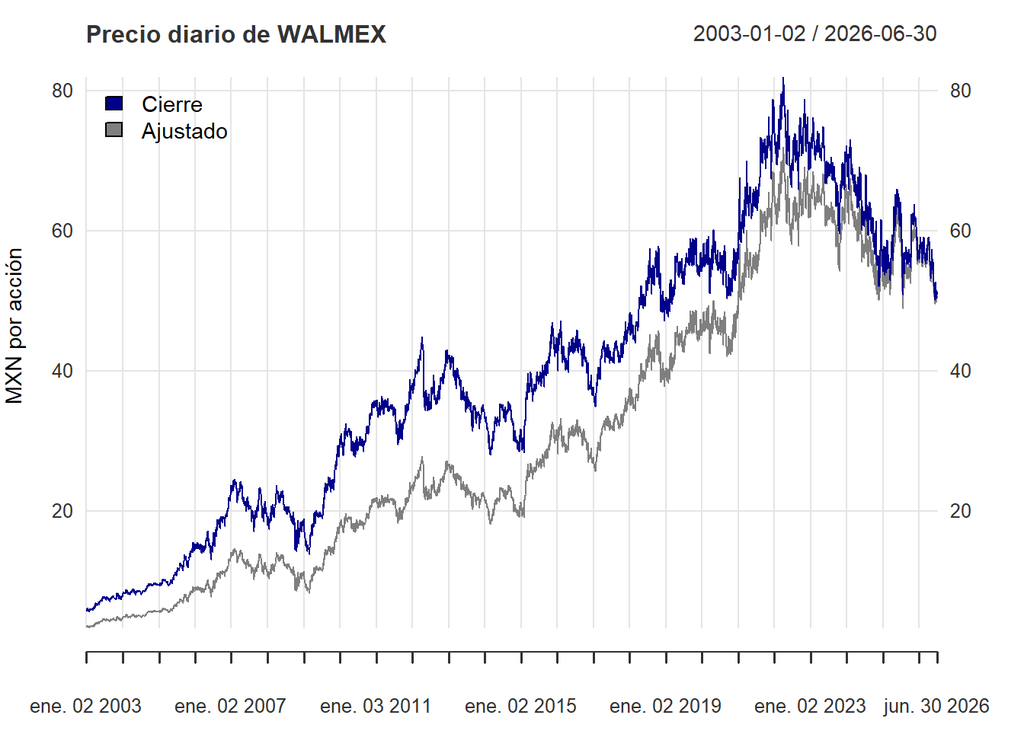

```r
precios <- merge(precio_cierre, precio_ajustado)

plot(precios,
     main = "Precio diario de WALMEX",
     ylab = "MXN por acción",
     col = c("darkblue", "gray50"),
     lwd = c(1.2, 1),
     legend.loc = "topleft",
     grid.col = "gray90")
```

Datos para describir el comportamiento general

```r
P0 <- as.numeric(first(precio_cierre))
PT <- as.numeric(last(precio_cierre))
P_max <- max(precio_cierre)

resumen_precio <- data.frame(
  Concepto = c("Precio inicial", "Precio final", "Rendimiento acumulado",
               "Precio máximo", "Fecha del máximo",
               "Veces que se multiplicó el precio hasta el máximo",
               "Distancia del precio final al máximo"),
  Valor = c(round(P0, 2), round(PT, 2),
            paste0(round((PT / P0 - 1) * 100, 1), "%"),
            round(P_max, 2),
            as.character(index(precio_cierre)[which.max(precio_cierre)]),
            round(P_max / P0, 2),
            paste0(round((PT / P_max - 1) * 100, 1), "%"))
)
resumen_precio
```

| Concepto | Valor |
| --- | --- |
| Precio inicial | 5.88 |
| Precio final | 51.26 |
| Rendimiento acumulado | 771.8% |
| Precio máximo | 81.92 |
| Fecha del máximo | 2022-03-31 |
| Veces que se multiplicó el precio hasta el máximo | 13.93 |
| Distancia del precio final al máximo | -37.4% |

## 2.3 2. Gráfica de los rendimientos

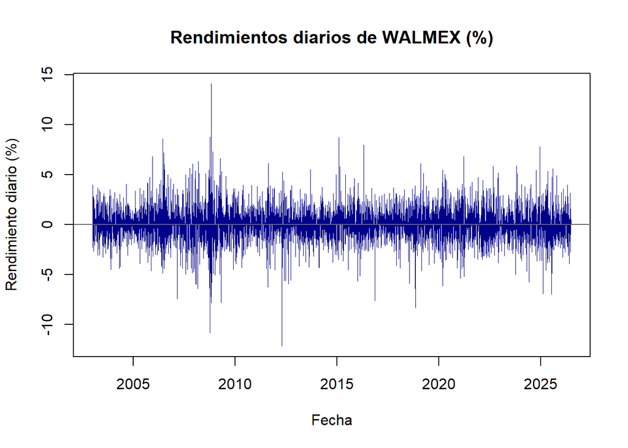

```r
rend_diario <- na.omit(Return.calculate(precio_ajustado, method = "discrete"))
colnames(rend_diario) <- "Rendimiento"

plot(index(rend_diario), as.numeric(rend_diario) * 100, type = "h",
     col = "darkblue", lwd = 0.5,
     main = "Rendimientos diarios de WALMEX (%)",
     xlab = "Fecha", ylab = "Rendimiento diario (%)")
abline(h = 0, col = "gray40")
```

Los rendimientos diarios oscilan alrededor de cero, pero su amplitud no es constante. Hay etapas tranquilas y otras en las que los movimientos grandes se concentran. El caso más claro es octubre y noviembre de 2008, cuando en pocas semanas se registraron el mejor día de la muestra (+14.1% el 28 de octubre) y uno de los peores (−10.9% el 6 de octubre).

El peor día de toda la serie (−12.2% el 23 de abril de 2012) no ocurrió en una crisis general, sino en un episodio propio de la empresa. Esto muestra que el precio reacciona tanto a choques de mercado como a información corporativa que el inversionista no puede anticipar.

## 2.4 Periodos con movimientos relevantes

Criterio: como caídas tomamos los episodios con drawdown mayor a 20% que duraron más de seis meses de pico a valle; como alzas, los tramos alcistas más pronunciados entre esas caídas, todos con un rendimiento acumulado mayor a 70%.

```r
periodos <- data.frame(
  id = 1:8,
  tipo = c("Alza", "Caída", "Alza", "Caída", "Alza", "Caída", "Alza", "Caída"),
  inicio = as.Date(c("2003-01-22", "2007-02-07", "2009-03-02", "2012-04-09",
                     "2015-02-03", "2016-02-05", "2020-09-10", "2022-03-31")),
  fin = as.Date(c("2007-02-07", "2009-03-02", "2012-04-09", "2014-02-26",
                  "2015-11-17", "2017-01-23", "2022-03-31", "2025-07-21"))
)

calcula_periodo <- function(ini, fin) {
  p_ini <- as.numeric(precio_ajustado[ini])
  p_fin <- as.numeric(precio_ajustado[fin])
  c(Meses = round(as.numeric(fin - ini) / 30.44, 1),
    P_inicio = round(p_ini, 2),
    P_fin = round(p_fin, 2),
    Rend_acumulado = round((p_fin / p_ini - 1) * 100, 1))
}

resultados <- t(mapply(calcula_periodo, periodos$inicio, periodos$fin))
tabla_periodos <- cbind(periodos, resultados)
tabla_periodos
```

| id | tipo | inicio | fin | Meses | P_inicio | P_fin | Rend_acumulado |
| --- | --- | --- | --- | --- | --- | --- | --- |
| 1 | Alza | 2003-01-22 | 2007-02-07 | 48.5 | 3.43 | 14.71 | 328.5 |
| 2 | Caída | 2007-02-07 | 2009-03-02 | 24.8 | 14.71 | 8.37 | -43.1 |
| 3 | Alza | 2009-03-02 | 2012-04-09 | 37.3 | 8.37 | 27.91 | 233.6 |
| 4 | Caída | 2012-04-09 | 2014-02-26 | 22.6 | 27.91 | 18.16 | -34.9 |
| 5 | Alza | 2015-02-03 | 2015-11-17 | 9.4 | 19.14 | 32.75 | 71.1 |
| 6 | Caída | 2016-02-05 | 2017-01-23 | 11.6 | 33.29 | 25.66 | -22.9 |
| 7 | Alza | 2020-09-10 | 2022-03-31 | 18.6 | 42.10 | 71.95 | 70.9 |
| 8 | Caída | 2022-03-31 | 2025-07-21 | 39.7 | 71.95 | 48.94 | -32.0 |

## 2.5 Gráfica del precio con los periodos sombreados:

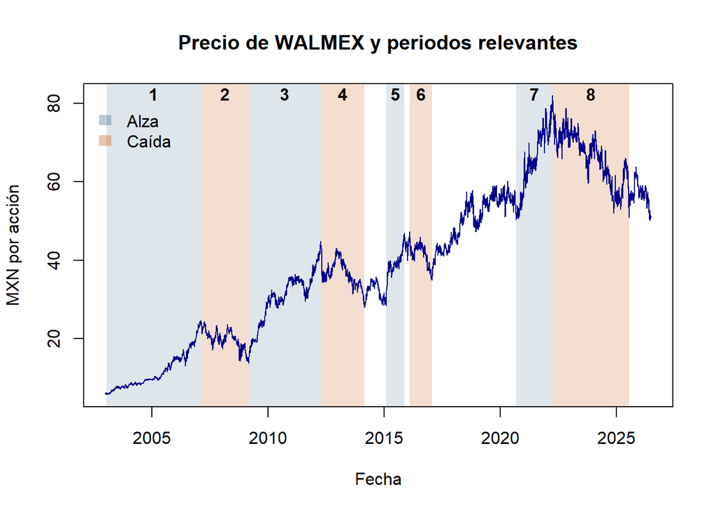

```r
plot(index(precio_cierre), as.numeric(precio_cierre), type = "n",
     main = "Precio de WALMEX y periodos relevantes",
     xlab = "Fecha", ylab = "MXN por acción")
for (i in 1:nrow(periodos)) {
  color <- ifelse(periodos$tipo[i] == "Alza", rgb(0.12, 0.31, 0.47, 0.15), rgb(0.77, 0.35, 0.07, 0.20))
  rect(periodos$inicio[i], par("usr")[3], periodos$fin[i], par("usr")[4], col = color, border = NA)
  text(periodos$inicio[i] + (periodos$fin[i] - periodos$inicio[i]) / 2, par("usr")[4] * 0.97, periodos$id[i], font = 2)
}
lines(index(precio_cierre), as.numeric(precio_cierre), col = "darkblue", lwd = 1.2)
graphics::legend("topleft", legend = c("Alza", "Caída"), fill = c(rgb(0.12, 0.31, 0.47, 0.3), rgb(0.77, 0.35, 0.07, 0.35)),
       border = NA, bty = "n", inset = c(0, 0.05))
```

El precio de cierre pasó de **5.88 MXN** el 2 de enero de 2003 a **51.26 MXN** el 30 de junio de 2026, un alza de **771.8%**. La gráfica muestra dos etapas bien distintas:

- **2003 a marzo de 2022 (tendencia alcista de largo plazo):** El precio se multiplicó casi 14 veces, hasta su máximo histórico de 81.92 MXN el 31 de marzo de 2022. La tendencia se interrumpió con caídas marcadas (2007–2009, 2012–2014 y 2016), pero después de cada una el precio superó su máximo anterior.
- **Marzo de 2022 a junio de 2026 (fase lateral-bajista):** Por primera vez en la muestra, el precio acumula más de cuatro años sin recuperar su máximo. Al cierre de junio de 2026 cotiza 37.4% por debajo del máximo de 2022 en precio de pantalla, y 29.5% por debajo en rendimiento total.

## 2.6 Máximo drawdown

```r
maximo_acumulado <- cummax(precio_ajustado)
drawdown <- precio_ajustado / maximo_acumulado - 1
colnames(drawdown) <- "Drawdown"

fecha_valle <- index(drawdown)[which.min(drawdown)]
hasta_valle <- precio_ajustado[paste0("/", fecha_valle)]
fecha_pico <- index(hasta_valle)[which.max(hasta_valle)]
precio_pico <- as.numeric(precio_ajustado[fecha_pico])
precio_valle <- as.numeric(precio_ajustado[fecha_valle])

# Primer día después del valle en que el precio vuelve al pico
despues <- precio_ajustado[paste0(fecha_valle, "/")]
fecha_recuperacion <- index(despues)[which(despues >= precio_pico)[1]]

resumen_mdd <- data.frame(
  Concepto = c("Precio en el pico", "Precio en el valle", "MDD = P_valle / P_pico - 1",
               "Fecha del pico", "Fecha del valle", "Días de caída (pico a valle)",
               "Fecha de recuperación", "Días de recuperación (valle a pico previo)"),
  Valor = c(round(precio_pico, 4), round(precio_valle, 4),
            paste0(round((precio_valle / precio_pico - 1) * 100, 2), "%"),
            as.character(fecha_pico), as.character(fecha_valle),
            as.numeric(fecha_valle - fecha_pico),
            as.character(fecha_recuperacion),
            as.numeric(fecha_recuperacion - fecha_valle))
)
resumen_mdd
```

| Concepto | Valor |
| --- | --- |
| Precio en el pico | 14.7132 |
| Precio en el valle | 8.3663 |
| MDD = P_valle / P_pico - 1 | -43.14% |
| Fecha del pico | 2007-02-07 |
| Fecha del valle | 2009-03-02 |
| Días de caída (pico a valle) | 754 |
| Fecha de recuperación | 2009-09-10 |
| Días de recuperación (valle a pico previo) | 192 |

Un inversionista que compró WALMEX en su máximo de febrero de 2007 llegó a perder **43.1%** de su inversión en marzo de 2009, incluso contando los dividendos cobrados. Esto muestra que una empresa de consumo básico, con un negocio defensivo y estable, también puede sufrir pérdidas de casi la mitad de su valor cuando el choque es sistémico. La recuperación fue rápida: 192 días de la fecha valor al máximo previo.

El episodio que empezó en marzo de 2022 es distinto y, para el análisis de riesgo, más preocupante. Su profundidad es menor **(-32.0%)**, pero ya dura más de cuatro años sin recuperarse. Mientras la caída de 2008 respondió a un choque externo del que la acción se recuperó pronto, la caída reciente coincide con factores propios de la empresa y de su entorno, que se analizan en las secciones siguientes.

Comprobación con PerformanceAnalytics (debe dar el mismo valor):

```r
maxDrawdown(rend_diario)
```

```
## [1] 0.4313755
```

```r
# Nota: en table.Drawdowns la columna From es el primer día de caída (el día siguiente al pico)
# y Length cuenta días hábiles, no naturales
table.Drawdowns(rend_diario, top = 5)
```

| From | Trough | To | Depth | Length | To Trough | Recovery |
| --- | --- | --- | --- | --- | --- | --- |
| 2007-02-08 | 2009-03-02 | 2009-09-10 | -0.4314 | 651 | 517 | 134 |
| 2012-04-10 | 2014-02-26 | 2015-08-06 | -0.3492 | 832 | 470 | 362 |
| 2022-04-01 | 2025-07-21 |  | -0.3198 | 1066 | 830 | NA |
| 2006-05-11 | 2006-06-13 | 2006-07-27 | -0.2402 | 56 | 24 | 32 |
| 2016-02-08 | 2017-01-23 | 2017-05-24 | -0.2292 | 326 | 244 | 82 |

Drawdown vigente desde el máximo de marzo de 2022:

```r
dd_2022 <- drawdown["2022-03-31/"]
min(dd_2022)
```

```
## [1] -0.3198009
```

```r
index(dd_2022)[which.min(dd_2022)]
```

```
## [1] "2025-07-21"
```

```r
last(drawdown)
```

```
##              Drawdown
## 2026-06-30 -0.2951198
```

Gráfica del drawdown:

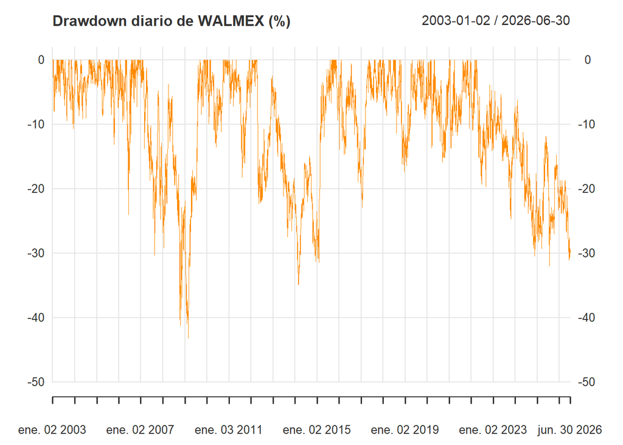

```r
plot(drawdown * 100,
     main = "Drawdown diario de WALMEX (%)",
     col = "darkorange", lwd = 0.8, grid.col = "gray90",
     ylim = c(-50, 2))
```

## 2.7 Identificación de eventos y explicación de los cambios

**Periodo 1 · Alza (Enero 2003 – Febrero 2007): Expansión estructural y boom emergente** Entorno Financiero y Económico: Tras superar la resaca de la burbuja “punto com”, los mercados globales iniciaron un ciclo de alta liquidez. México se benefició significativamente de la maduración del TLCAN y de una sólida estabilidad macroeconómica, lo que atrajo fuertes flujos de capital extranjero hacia la bolsa local.

- **Factor Corporativo:** Walmex ejecutó un plan de expansión sumamente agresivo —destacando el crecimiento de Bodega Aurrera— y, en 2006, obtuvo la autorización para operar “Banco Walmart”.
- **Relevancia del Choque:** Durante esta etapa, el flujo de información fue sumamente positivo. Sin embargo, este optimismo prolongado generó valuaciones exigentes, dejando a la acción vulnerable ante cualquier cambio en el entorno macroeconómico.

**Periodo 2 · Caída (Febrero 2007 – Marzo 2009): La Crisis Financiera Global (Riesgo Sistémico)**

- **Entorno Financiero y Económico:** El colapso de las hipotecas subprime en Estados Unidos desencadenó la crisis financiera de 2008. Aunque el origen fue el sector inmobiliario y bancario estadounidense, provocó un choque de liquidez a nivel global. Los inversionistas institucionales liquidaron agresivamente sus posiciones en mercados emergentes en una “huida hacia la calidad” (flight to quality).
- **Relevancia del Choque:** Este es el ejemplo perfecto de un choque exógeno. Aunque Walmex no tenía exposición a hipotecas tóxicas y sus ventas de consumo básico conservaban un perfil defensivo, sufrió su Máximo Drawdown histórico (-43.1%). Esto demuestra que, en eventos de pánico global, la correlación entre activos tiende a 1, y los fundamentales de una empresa no pueden blindar el precio de su acción contra la falta de liquidez sistémica.

**Periodo 3 · Alza (Marzo 2009 – Abril 2012): Inyección de liquidez y expansión regional**

- **Entorno Financiero y Económico:** Los principales bancos centrales, liderados por la Reserva Federal (Fed), implementaron políticas de Flexibilización Cuantitativa (Quantitative Easing). El “dinero barato” inundó nuevamente a los mercados emergentes en busca de rendimientos.
- **Factor Corporativo:** En 2009, la empresa anunció la adquisición estratégica de Walmart Centroamérica. La consolidación de estas operaciones transformó por completo la estructura de ingresos de la emisora.
- **Relevancia del Choque:** La inyección masiva de capital exógeno combinada con la sorpresa corporativa de la expansión centroamericana detonó un ciclo alcista que triplicó el precio de la acción. Los inversionistas reaccionaron positivamente a una escala de negocio que no estaba contemplada en los modelos de valuación previos a 2009.

**Periodo 4 · Caída (Abril 2012 – Febrero 2014): El escándalo de corrupción y el choque fiscal**

- **Factor Corporativo (Choque Asimétrico):** El 21 de abril de 2012, The New York Times publicó un reportaje alegando que Walmex orquestó una campaña masiva de sobornos para acelerar la apertura de tiendas en México. Esto desató investigaciones bajo la Ley de Prácticas Corruptas en el Extranjero (FCPA) de EE. UU.
- **Entorno Político y Económico:** En 2013, México aprobó una Reforma Fiscal que incluyó impuestos a alimentos con alto contenido calórico y la homologación del IVA en la franja fronteriza.
- **Relevancia del Choque:** El reportaje causó la caída diaria más severa de toda la serie histórica (-12.2%). Se trató de información puramente asimétrica e imposible de modelar financieramente por adelantado. Este evento congeló el crecimiento inorgánico, forzó cambios en la directiva y destruyó la prima de confianza que el mercado le otorgaba a la empresa. Posteriormente, el choque fiscal de 2013-2014 comprimió aún más el poder adquisitivo de su consumidor objetivo.

**Periodo 5 · Alza (Febrero 2015 – Noviembre 2015): Reestructuración y retorno al Core Business**

- **Factor Corporativo:** Tras el estancamiento derivado del escándalo, la directiva tomó la decisión de desinvertir en activos no estratégicos. Se concretó la venta de la cadena de restaurantes Vips (a Alsea) y de Banco Walmart (a Inbursa).
- **Relevancia del Choque:** El mercado premió fuertemente esta inyección de liquidez y el reenfoque en su negocio principal (retail). Los inversionistas ajustaron al alza sus expectativas al observar una mejora en los márgenes operativos gracias a la eliminación de las divisiones menos rentables.

**Periodo 6 · Caída (Febrero 2016 – Enero 2017): Elecciones en EE. UU. y volatilidad cambiaria**

- **Entorno Político y Económico:** La sorpresiva victoria de Donald Trump en las elecciones de noviembre de 2016, sumada a su retórica proteccionista, generó pánico sobre el futuro del TLCAN. Como resultado, el peso mexicano sufrió una fuerte depreciación, rompiendo la barrera de los $20 MXN por dólar.
- **Relevancia del Choque:** Walmex genera la inmensa mayoría de sus ingresos en pesos mexicanos dentro del mercado local. Sin embargo, la caída del 7.6% en una sola sesión (noviembre de 2016) evidencia cómo el capital extranjero castigó de manera indiscriminada a los activos mexicanos (Riesgo País). Fue un choque político que alteró radicalmente las tasas de descuento, a pesar de que las ventas de los supermercados no cambiaron de un día para otro.

**Periodo 7 · Alza (Septiembre 2020 – Marzo 2022): Normalización post-pandemia e inflación**

- **Entorno Financiero y Económico:** Durante y después de la pandemia, los estímulos fiscales globales mantuvieron elevado el nivel de consumo. Cuando la inflación comenzó a repuntar a finales de 2021, los inversionistas buscaron refugio en empresas de consumo básico.
- **Factor Corporativo:** Walmex demostró un poder de fijación de precios (pricing power) excepcional, logrando trasladar la inflación al consumidor final, al mismo tiempo que consolidó una robusta infraestructura de e-commerce.
- **Relevancia del Choque:** El mercado reconoció a Walmex como un activo defensivo contra la inflación, impulsando la acción a su máximo histórico. Esto comprobó que, ante un choque inflacionario no anticipado, los flujos de caja de los supermercados dominantes se perciben como un auténtico puerto seguro.

**Periodo 8 · Caída/Lateral (Marzo 2022 – Julio 2025): Política monetaria, entorno regulatorio y presiones laborales** - **Entorno Financiero y Económico:** El Banco de México (Banxico) elevó la tasa de interés de referencia a niveles restrictivos históricos (alcanzando el 11.25%). Esto encareció el costo de capital de la emisora y provocó que los instrumentos de renta fija (como los Cetes) compitieran agresivamente contra los dividendos de Walmex.

- **Entorno Político y Regulatorio:** En octubre de 2023, la COFECE notificó a Walmex sobre un procedimiento por presuntas prácticas monopólicas en el mercado de abastecimiento mayorista. Simultáneamente, reformas laborales estructurales (incrementos agresivos al salario mínimo, aumento de vacaciones y reducción de la jornada laboral) impactaron directamente su estructura de costos.
- **Relevancia del Choque:** Esta fase prolongada no representa un colapso brusco, sino un reajuste estructural. El choque regulatorio de la COFECE introdujo incertidumbre legal (riesgo idiosincrático), mientras que el choque laboral ha ejercido fuerte presión sobre el margen operativo (validando la hipótesis planteada en la primera entrega del reporte). Ninguno de estos eventos críticos podía ser descontado plenamente por el mercado cuando la acción alcanzó su máximo en 2022.

## 2.8 Relación con el entorno económico

Analisis entre el PIB Mexico y los rendimientos anuales de WALMEX.

```r
# WALMEX

ticker <- "WALMEX.MX"

getSymbols(
  ticker,
  src = "yahoo",
  from = "2003-01-01"
)
```

```
## [1] "WALMEX.MX"
```

```r
price <- na.omit(Ad(get(ticker)))
```

```r
# Rendimientos diarios de WALMEX

rend_diario <- na.omit(
  Return.calculate(price, method = "discrete")
)

colnames(rend_diario) <- "WALMEX"
```

```r
# Rendimiento anual de WALMEX

rend_anual <- apply.yearly(
  rend_diario,
  function(x) prod(1 + x) - 1
)

colnames(rend_anual) <- "Rendimiento_WALMEX"

rend_anual
```

```
##            Rendimiento_WALMEX
## 2003-12-31        0.344103390
## 2004-12-31        0.211208754
## 2005-12-30        0.541133394
## 2006-12-29        0.611930011
## 2007-12-31       -0.207527235
## 2008-12-31       -0.005396028
## 2009-12-31        0.575675301
## 2010-12-30        0.222584369
## 2011-12-30        0.103960889
## 2012-12-31        0.122272800
## 2013-12-30       -0.174579712
## 2014-12-31       -0.032827444
## 2015-12-31        0.436275920
## 2016-12-30       -0.111238683
## 2017-12-29        0.376600400
## 2018-12-31        0.067928705
## 2019-12-31        0.125934823
## 2020-12-31        0.066480049
## 2021-12-31        0.389308675
## 2022-12-30       -0.073033444
## 2023-12-29        0.065595419
## 2024-12-31       -0.200333030
## 2025-12-31        0.049782090
## 2026-11-24       -0.034029730
```

```r
# PIB anual de México

url_pib <- paste0(
  "https://api.worldbank.org/v2/country/MEX/indicator/",
  "NY.GDP.MKTP.KD.ZG?format=json&per_page=100"
)

pib_raw <- fromJSON(content(GET(url_pib), as = "text"))

pib_mexico <- data.frame(
  anio = as.numeric(pib_raw[[2]]$date),
  PIB = as.numeric(pib_raw[[2]]$value)
)

pib_mexico <- pib_mexico[
  pib_mexico$anio >= 2003,
]

pib_mexico <- na.omit(pib_mexico)

pib_mexico <- pib_mexico[
  order(pib_mexico$anio),
]

pib_mexico
```

|  | anio | PIB |
| --- | --- | --- |
| 23 | 2003 | 1.1855449 |
| 22 | 2004 | 3.5654410 |
| 21 | 2005 | 2.1132471 |
| 20 | 2006 | 4.8050135 |
| 19 | 2007 | 2.0778639 |
| 18 | 2008 | 0.9433319 |
| 17 | 2009 | -6.2952506 |
| 16 | 2010 | 4.9713346 |
| 15 | 2011 | 3.4440451 |
| 14 | 2012 | 3.5532108 |

[output cut: 13 more lines]

```r
pib_anual <- pib_mexico$PIB
rend_anual <- rend_anual["/2025"]

df_final <- data.frame(
  anio = format(index(rend_anual), "%Y"),
  Rendimiento_WALMEX = as.numeric(rend_anual),
  PIB = pib_anual
)

df_final
```

| anio | Rendimiento_WALMEX | PIB |
| --- | --- | --- |
| 2003 | 0.344103390 | 1.1855449 |
| 2004 | 0.211208754 | 3.5654410 |
| 2005 | 0.541133394 | 2.1132471 |
| 2006 | 0.611930011 | 4.8050135 |
| 2007 | -0.207527235 | 2.0778639 |
| 2008 | -0.005396028 | 0.9433319 |
| 2009 | 0.575675301 | -6.2952506 |
| 2010 | 0.222584369 | 4.9713346 |
| 2011 | 0.103960889 | 3.4440451 |
| 2012 | 0.122272800 | 3.5532108 |

[output cut: 13 more lines]

```r
# Preparar datos para graficar

df_final$anio <- as.numeric(df_final$anio)
df_final$Rendimiento_WALMEX_pct <- df_final$Rendimiento_WALMEX * 100

df_final
```

| anio | Rendimiento_WALMEX | PIB | Rendimiento_WALMEX_pct |
| --- | --- | --- | --- |
| 2003 | 0.344103390 | 1.1855449 | 34.4103390 |
| 2004 | 0.211208754 | 3.5654410 | 21.1208754 |
| 2005 | 0.541133394 | 2.1132471 | 54.1133394 |
| 2006 | 0.611930011 | 4.8050135 | 61.1930011 |
| 2007 | -0.207527235 | 2.0778639 | -20.7527235 |
| 2008 | -0.005396028 | 0.9433319 | -0.5396028 |
| 2009 | 0.575675301 | -6.2952506 | 57.5675301 |
| 2010 | 0.222584369 | 4.9713346 | 22.2584369 |
| 2011 | 0.103960889 | 3.4440451 | 10.3960889 |
| 2012 | 0.122272800 | 3.5532108 | 12.2272800 |

[output cut: 13 more lines]

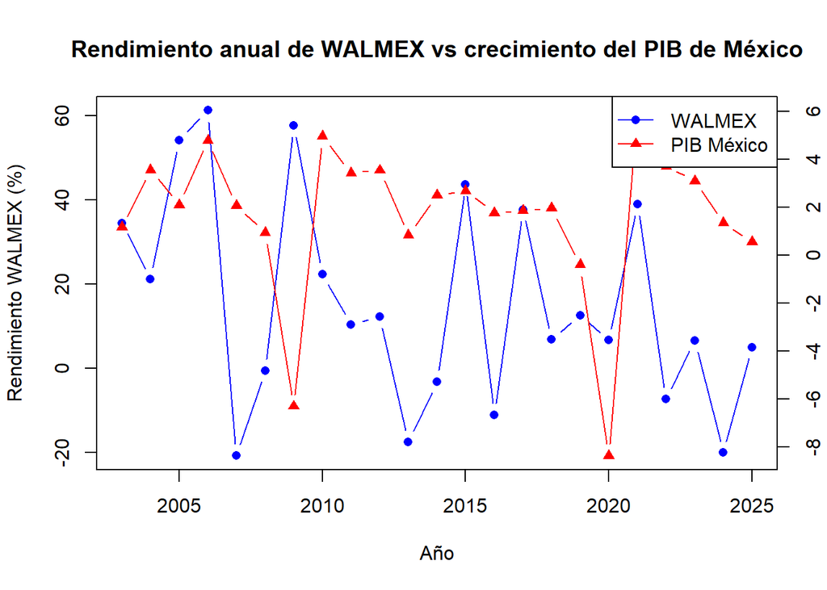

```r
# Gráfica comparativa WALMEX vs PIB

plot(
  df_final$anio,
  df_final$Rendimiento_WALMEX_pct,
  type = "b",
  pch = 16,
  col = "blue",
  xlab = "Año",
  ylab = "Rendimiento WALMEX (%)",
  main = "Rendimiento anual de WALMEX vs crecimiento del PIB de México"
)

par(new = TRUE)

plot(
  df_final$anio,
  df_final$PIB,
  type = "b",
  pch = 17,
  col = "red",
  axes = FALSE,
  xlab = "",
  ylab = ""
)

axis(4)
mtext("Crecimiento del PIB (%)", side = 4, line = 3)

legend(
  "topright",
  legend = c("WALMEX", "PIB México"),
  col = c("blue", "red"),
  pch = c(16, 17),
  lty = 1
)
```

```r
cor(
  df_final$Rendimiento_WALMEX_pct,
  df_final$PIB,
  use = "complete.obs"
)
```

```
## [1] 0.01764371
```

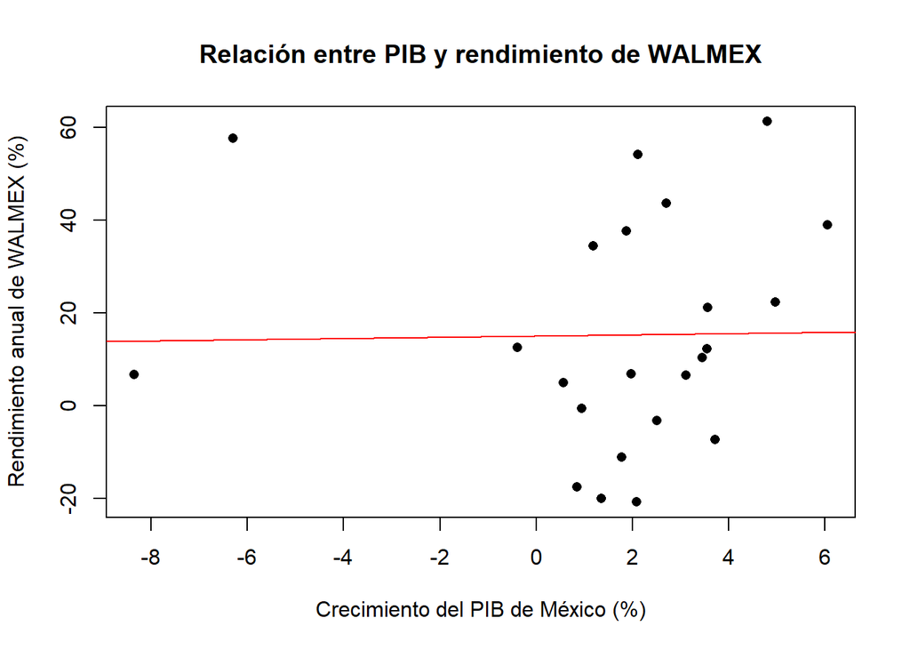

```r
plot(
  df_final$PIB,
  df_final$Rendimiento_WALMEX_pct,
  pch = 16,
  xlab = "Crecimiento del PIB de México (%)",
  ylab = "Rendimiento anual de WALMEX (%)",
  main = "Relación entre PIB y rendimiento de WALMEX"
)

abline(
  lm(Rendimiento_WALMEX_pct ~ PIB, data = df_final),
  col = "red"
)
```

```r
modelo_pib <- lm(
  Rendimiento_WALMEX_pct ~ PIB,
  data = df_final
)

summary(modelo_pib)
```

```
##
## Call:
## lm(formula = Rendimiento_WALMEX_pct ~ PIB, data = df_final)
##
## Residuals:
##     Min      1Q  Median      3Q     Max
## -36.053 -17.163  -5.089  20.810  45.524
##
## Coefficients:
##             Estimate Std. Error t value Pr(>|t|)
## (Intercept)  15.0188     5.9685   2.516   0.0201 *
## PIB           0.1353     1.6733   0.081   0.9363
## ---
## Signif. codes:  0 '***' 0.001 '**' 0.01 '*' 0.05 '.' 0.1 ' ' 1
##
## Residual standard error: 25.36 on 21 degrees of freedom
## Multiple R-squared:  0.0003113,  Adjusted R-squared:  -0.04729
## F-statistic: 0.006539 on 1 and 21 DF,  p-value: 0.9363
```

Relación con el entorno económico

Al comparar el rendimiento anual de WALMEX con el crecimiento del PIB de México entre 2003 y 2025, no se observa que la acción se mueva de forma consistente con el ciclo económico. La correlación entre ambas variables fue de apenas 0.0176, prácticamente nula, lo que indica que los años de mayor o menor crecimiento económico no estuvieron asociados de manera clara con mayores o menores rendimientos de WALMEX.

La regresión confirma este resultado. El PIB obtuvo un coeficiente de 0.1353, pero con un p-value de 0.9363, por lo que no existe evidencia estadística de una relación lineal significativa en el periodo analizado. Además, el R² fue de 0.00031, es decir, el crecimiento del PIB explica aproximadamente 0.03% de la variación observada en los rendimientos anuales de WALMEX.

La gráfica también muestra comportamientos distintos en varios momentos. Por ejemplo, durante las fuertes contracciones económicas de 2009 y 2020, WALMEX no presentó una caída proporcional a la del PIB; incluso en otros años con crecimiento económico positivo, la acción llegó a registrar rendimientos negativos. Por ello, los resultados sugieren que WALMEX presenta baja sensibilidad directa al ciclo económico mexicano, al menos cuando se mide mediante el crecimiento anual del PIB.

Una posible explicación se encuentra en su modelo de negocio. WALMEX tiene una alta exposición al consumo de productos básicos, cuya demanda puede mantenerse incluso en periodos de desaceleración. Además, el rendimiento de una acción depende de factores que van más allá del PIB, como resultados financieros, márgenes, costos, inflación, expansión, expectativas de los inversionistas y condiciones del mercado bursátil. Por ello, el comportamiento de WALMEX puede diferir considerablemente del desempeño general de la economía.

Conclusión: con los datos analizados, WALMEX no muestra un comportamiento claramente procíclico ni contracíclico; más bien presenta un comportamiento relativamente independiente del crecimiento anual del PIB. La evidencia principal es la correlación cercana a cero, el R² prácticamente nulo y la ausencia de significancia estadística en la regresión.

## 2.9 Análisis de los periodos más recientes:

Durante el último año analizado, WALMEX estuvo expuesta a cambios en el entorno macroeconómico y a información propia de la empresa. Uno de los factores relevantes fue la reducción de la tasa de interés de referencia del Banco de México. Entre septiembre de 2025 y mayo de 2026 la tasa objetivo pasó de (7.75%) a (6.50%), lo que modificó las condiciones financieras y las expectativas de los inversionistas.

Otro factor importante fueron los resultados de la empresa. Al segundo trimestre de 2026, Walmex reportó un crecimiento consolidado de ingresos de (1.9%), mientras que el tráfico en México disminuyó (1.1%). Esto muestra una desaceleración en algunos indicadores operativos y puede generar cambios en las expectativas sobre el crecimiento futuro de la empresa. El reporte de resultados del 2T26 fue publicado el 22 de julio de 2026.

También destacó el entorno regulatorio. En septiembre de 2025, la COFECE informó la conclusión de una investigación relacionada con el comercio electrónico minorista. Este tipo de acontecimientos puede introducir incertidumbre sobre las condiciones competitivas y regulatorias en las que opera Walmex.

Estos acontecimientos no necesariamente producen movimientos proporcionales o inmediatos en el precio de la acción, ya que el mercado incorpora simultáneamente nueva información, expectativas y condiciones generales. Por ello, los rendimientos de WALMEX deben interpretarse como resultado de la interacción de factores empresariales, macroeconómicos y externos.

## 2.10 Conclusión Final parte 2:

El análisis de WALMEX muestra que, aunque el precio de la acción presenta una tendencia positiva en el largo plazo, también existen periodos de caídas y variaciones importantes en los rendimientos. En la serie analizada, el precio pasó de (5.88) pesos al inicio del periodo a (51.26) pesos al 30 de junio de 2026, mientras que el máximo histórico de la serie analizada fue de (81.92) pesos.

Los acontecimientos recientes permiten observar que el comportamiento de la acción no depende únicamente de los resultados de Walmex. Los cambios en las tasas de interés, el crecimiento del consumo, los resultados financieros y los acontecimientos regulatorios pueden modificar las expectativas de los inversionistas y, por consecuencia, afectar el precio y los rendimientos.

Finalmente, este ejercicio permite comprender que el riesgo financiero no consiste únicamente en observar si el precio sube o baja, sino en reconocer que los activos están expuestos constantemente a nueva información y a eventos que no pueden controlarse ni predecirse con certeza. Los cambios en las condiciones económicas, políticas, regulatorias y empresariales pueden generar movimientos inesperados en los precios. Por ello, el análisis histórico ayuda a identificar patrones y fuentes de riesgo, pero no elimina la incertidumbre sobre el comportamiento futuro del activo.

## 2.11 Referencias

CNNExpansión. (2015, 27 de agosto). Hacienda aprueba que Inbursa compre a Banco Walmart. *Expansión*. https://expansion.mx/negocios/2015/08/27/hacienda-autoriza-fusion-de-inbursa-con-banco-walmart

Pool CEO. (2023, 6 de octubre). Cofece inicia juicio contra Walmart por prácticas monopólicas en el sector de comercio al menudeo. *EL CEO*. https://elceo.com/negocios/cofece-inicia-juicio-contra-walmart-por-practicas-monopolicas-en-el-sector-de-comercio-al-menudeo/

Juárez, E. (2014, 19 de diciembre). Inbursa compra Banco Walmart. *El Economista*. https://www.eleconomista.com.mx/sectorfinanciero/Inbursa-compra-Banco-Walmart-20141218-0173.html

Redacción. (2014, 12 de mayo). Vips ya es de Alsea. *El Economista*. https://www.eleconomista.com.mx/empresas/Vips-ya-es-de-Alsea-20140512-0045.html

Barstow, D. (2012, 21 de abril). Vast Mexico Bribery Case Hushed Up by Wal-Mart After Top-Level Struggle. *The New York Times*. https://www.nytimes.com/2012/04/22/business/at-wal-mart-in-mexico-a-bribe-inquiry-silenced.html

El Economista. (2010, 12 de enero). Las últimas fusiones 2009. *El Economista*. https://www.eleconomista.com.mx/empresas/Las-ultimas-fusiones-2009-20100112-0144.html

# 3 Parte 3. Rendimientos, Volatilidad y Simulación del Precio

## 3.1 1. Introducción

En la primera entrega caracterizamos el negocio de WALMEX y en la segunda explicamos los movimientos de su precio a partir de los eventos económicos, políticos y corporativos que los provocaron. En esta tercera entrega pasamos de la descripción a la **modelación estadística del precio**.

El modelo de referencia es el **Movimiento Browniano Geométrico (GBM)**, que describe el cambio del precio con la ecuación diferencial estocástica

$$dS_t=μS_t dt+σS_t dW_t$$

donde μ es la tendencia (drift), σ la volatilidad y W_t un movimiento browniano estándar. Una implicación directa del modelo es que los **rendimientos logarítmicos son independientes y se distribuyen normal**, y por lo tanto que el **precio sigue una distribución lognormal**.

El documento se organiza así: - **Cálculo de rendimientos y volatilidad:** Calculamos el rendimiento logarítmico diario, estimamos la media y la volatilidad diarias y anualizadas para 2021–2026 y repetimos la estimación año por año para detectar cambios en el nivel de riesgo. - **Pruebas estadísticas:** Aplicamos la prueba de Jarque-Bera al rendimiento, al precio y a su logaritmo, y una prueba t para saber si el rendimiento medio diario es distinto de cero. - **Estimación del modelo con parámetros diarios:** Construimos la ecuación del GBM y estimamos el precio esperado a 10, 20 y 40 días con intervalos de confianza de 95%. - **Estimación del modelo con parámetros anuales:** Construimos la ecuación de lnS_t y estimamos el precio esperado a 3, 6, 9 y 12 meses con sus intervalos de confianza. - **Discusión teórica y conclusiones:** Contrastamos los supuestos del GBM con lo observado y discutimos qué riesgos introduce suponer normalidad en la toma de decisiones financieras.

Igual que en las entregas anteriores, cada indicador se presenta con su definición, su fórmula, el cálculo con los datos y su interpretación.

## 3.2 2. Cálculo de rendimientos y volatilidad

Usamos los precios diarios de WALMEX* en la Bolsa Mexicana de Valores, obtenidos de Yahoo Finance (ticker WALMEX.MX), la misma fuente de la Parte 2. Trabajamos con el **precio ajustado por splits y dividendos**, porque mide el rendimiento total del accionista y evita saltos artificiales en las fechas de pago de dividendos. Igual que en la Parte 2, eliminamos los días festivos que la fuente reporta con volumen cero, porque generarían rendimientos artificiales de 0%. La serie limpia va del **2 de enero de 2003 al 15 de octubre de 2026**.

```r
library(quantmod)
library(xts)
library(TTR)
```

```r
clave <- "WALMEX.MX"
getSymbols(clave, from = "2003-01-01", to = "2026-10-16")
```

```
## [1] "WALMEX.MX"
```

```r
datos_p3 <- na.omit(get(clave))

# Quitamos los días festivos
datos_p3 <- datos_p3[Vo(datos_p3) > 0, ]

precio <- Ad(datos_p3)
names(precio) <- "precio"

first(index(precio))
```

```
## [1] "2003-01-02"
```

```r
last(index(precio))
```

```
## [1] "2026-10-15"
```

```r
nrow(precio)
```

```
## [1] 5965
```

### 3.2.1 a) Rendimiento logarítmico diario

El rendimiento logarítmico (o continuamente compuesto) del día t es:

$$r_t=ln(\frac{S_t}{S_(t-1)}
)=lnS_t-lnS_(t-1)$$

Usamos rendimientos logarítmicos, y no simples como en la Parte 2, por dos razones: son aditivos en el tiempo y son la variable que el GBM supone normal.

```r
rendimientos <- dailyReturn(precio, type = "log")
# dailyReturn pone 0 en el primer día (no hay precio anterior); lo quitamos
rendimientos <- rendimientos[-1]
names(rendimientos) <- "rendimiento"

head(rendimientos)
```

```
##             rendimiento
## 2003-01-03 -0.001259621
## 2003-01-06  0.038735541
## 2003-01-07 -0.023309184
## 2003-01-08 -0.004976981
## 2003-01-09  0.004563033
## 2003-01-10  0.018048500
```

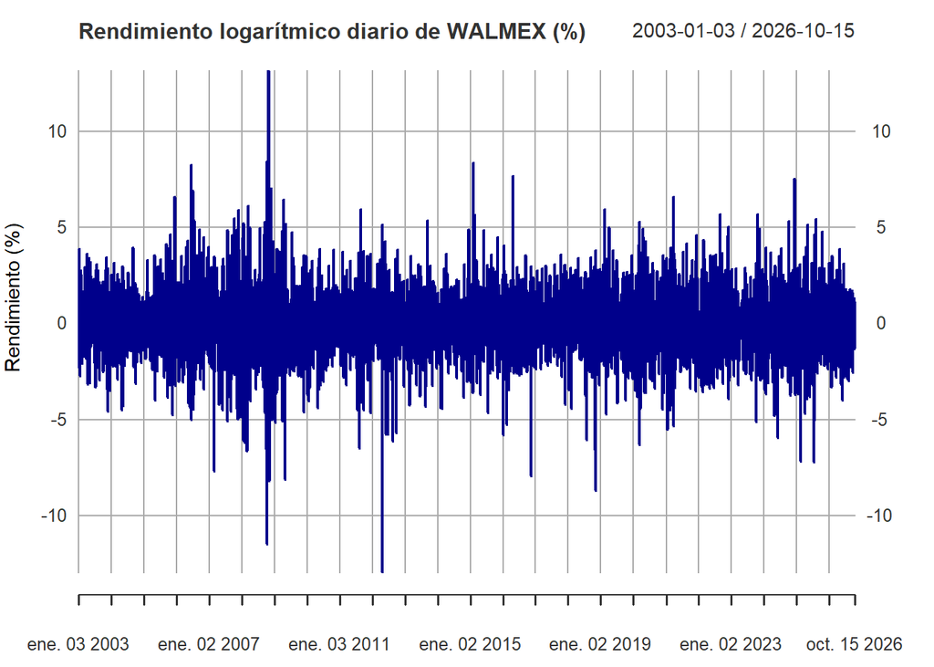

```r
plot(rendimientos * 100, type = "l", col = "darkblue",
     main = "Rendimiento logarítmico diario de WALMEX (%)",
     ylab = "Rendimiento (%)")
```

### 3.2.2 b) Estimaciones con toda la información de 2021 a 2026

Parámetros estimados con los rendimientos de 2021 al 15 de octubre

```r
rend_21_26 <- rendimientos["2021-01-01/"]

n_21_26 <- nrow(rend_21_26)
media_diaria <- mean(rend_21_26)
vol_diaria <- sd(rend_21_26)
media_anual <- 252 * media_diaria
vol_anual <- sqrt(252) * vol_diaria

n_21_26
```

```
## [1] 1456
```

```r
estimaciones_21_26 <- data.frame(
  Concepto = c("Rendimiento promedio diario (%)",
               "Volatilidad diaria (%)",
               "Rendimiento promedio anual (%)",
               "Volatilidad anual (%)"),
  Valor = c(round(media_diaria * 100, 4),
            round(vol_diaria * 100, 4),
            round(media_anual * 100, 2),
            round(vol_anual * 100, 2))
)
estimaciones_21_26
```

| Concepto | Valor |
| --- | --- |
| Rendimiento promedio diario (%) | -0.0005 |
| Volatilidad diaria (%) | 1.6183 |
| Rendimiento promedio anual (%) | -0.1300 |
| Volatilidad anual (%) | 25.6900 |

Comprobación de la propiedad aditiva: la suma de los rendimientos diarios debe ser igual al logaritmo del precio final entre el precio del último día de 2020.

```r
sum(rend_21_26)
```

```
## [1] -0.007609461
```

```r
log(as.numeric(last(precio)) / as.numeric(last(precio["/2020-12-31"])))
```

```
## [1] -0.007609461
```

```r
ee_media_diaria <- vol_diaria / sqrt(n_21_26)
ee_media_anual <- 252 * ee_media_diaria

ee_media_anual * 100                                     # error estándar anual (%)
```

```
## [1] 10.68727
```

```r
c(inferior = media_anual - 1.96 * ee_media_anual,
  superior = media_anual + 1.96 * ee_media_anual) * 100   # intervalo de 95% (%)
```

```
##  inferior  superior
## -21.07876  20.81535
```

### 3.2.3 c) Estimaciones año por año

Rendimiento y volatilidad de WALMEX por año (cifras en %).

```r
media_por_ano <- apply.yearly(rend_21_26, function(x) mean(x))
vol_por_ano <- apply.yearly(rend_21_26, sd)
suma_por_ano <- apply.yearly(rend_21_26, sum)
n_por_ano <- apply.yearly(rend_21_26, function(x) length(x))

tabla_anual <- data.frame(
  Ano = format(index(media_por_ano), "%Y"),
  n = as.numeric(n_por_ano),
  Media_diaria = round(as.numeric(media_por_ano) * 100, 3),
  Vol_diaria = round(as.numeric(vol_por_ano) * 100, 3),
  Rend_anual = round(as.numeric(media_por_ano) * 252 * 100, 2),
  Vol_anual = round(as.numeric(vol_por_ano) * sqrt(252) * 100, 2),
  Rend_realizado = round(as.numeric(suma_por_ano) * 100, 2)
)
tabla_anual
```

| Ano | n | Media_diaria | Vol_diaria | Rend_anual | Vol_anual | Rend_realizado |
| --- | --- | --- | --- | --- | --- | --- |
| 2021 | 253 | 0.130 | 1.727 | 32.75 | 27.41 | 32.88 |
| 2022 | 252 | -0.030 | 1.732 | -7.58 | 27.49 | -7.58 |
| 2023 | 251 | 0.025 | 1.382 | 6.38 | 21.93 | 6.35 |
| 2024 | 251 | -0.089 | 1.659 | -22.45 | 26.34 | -22.36 |
| 2025 | 251 | 0.019 | 1.762 | 4.88 | 27.97 | 4.86 |
| 2026 | 198 | -0.075 | 1.346 | -18.98 | 21.36 | -14.91 |

### 3.2.4 Parámetros para las secciones 3 a 5 (toda la información hasta 2025)

```r
rend_hasta_2025 <- rendimientos["/2025-12-31"]

mu_d <- mean(rend_hasta_2025)
sigma_d <- sd(rend_hasta_2025)
mu_a <- 252 * mu_d
sigma_a <- sqrt(252) * sigma_d
S0 <- as.numeric(last(precio["/2025-12-31"]))   # último precio de 2025

nrow(rend_hasta_2025)
```

```
## [1] 5766
```

```r
parametros_2025 <- data.frame(
  Parametro = c("mu diaria", "sigma diaria", "mu anual", "sigma anual", "S0 (31-dic-2025)"),
  Valor = round(c(mu_d, sigma_d, mu_a, sigma_a, S0), 6)
)
parametros_2025
```

| Parametro | Valor |
| --- | --- |
| mu diaria | 0.000478 |
| sigma diaria | 0.016682 |
| mu anual | 0.120534 |
| sigma anual | 0.264826 |
| S0 (31-dic-2025) | 55.415783 |

### 3.2.5 d) Interpretación

**Resultados generales (2021–2026)**. Con 1,456 rendimientos diarios, el rendimiento promedio diario fue de **−0.0005%**, prácticamente cero, que anualizado equivale a **−0.13%**. La comprobación aditiva lo confirma: la suma de los rendimientos (−0.76%) coincide con ln(48.25/48.62), es decir, el precio ajustado de octubre de 2026 es casi el mismo que el de cierre de 2020. En cambio, la volatilidad diaria fue de **1.62%**, que anualizada da **25.69%**. En casi seis años el accionista asumió un riesgo considerable sin obtener rendimiento a cambio, lo que es consistente con la fase lateral-bajista que identificamos en la Parte 2 a partir de marzo de 2022.

La media, además, está estimada con poca precisión: su error estándar anualizado es de **10.7%**, así que el intervalo de 95% para el rendimiento anual va de aproximadamente **−21% a +21%**. La volatilidad, en cambio, se mide con mucha más precisión.

**¿Existen cambios estructurales?** La tendencia cambia a partir de 2022. De 2003 a 2025 la acción rinde 12.05% anual en promedio, pero de 2021 a 2026 el promedio es prácticamente 0%. - 2021 todavía fue muy bueno (+32.9%), y es el último año antes del máximo histórico de marzo de 2022. - De 2022 a hoy hay tres años negativos y solo dos ligeramente. - En total se acumulan alrededor de −34% desde 2022. La acción pasó de crecer a moverse de lado o a la baja.

**¿Se observan periodos de mayor riesgo?** Sí, y lo raro es que no coinciden necesariamente con los años de peor rendimiento: - **2024 fue el año de mayor pérdida:** (−22.4%) con una volatilidad de 26.3%, cercana al promedio. Incluye la caída de −6.0% del 3 de junio, el primer día hábil después de la elección presidencial en México, y un cuarto trimestre muy volátil (31.4%). - **El cuarto trimestre de 2023** pasó de 16.9% a 30.7% de volatilidad; ahí está la caída de −5.1% del 9 de octubre, que coincide con la notificación de la COFECE descrita en la Parte 2. - **El segundo trimestre de 2025** registró la volatilidad trimestral más alta después de 2021 (32.1%), en el tramo final del drawdown que terminó el 21 de julio de 2025. - **2026** es el año más tranquilo en volatilidad (21.4%), pero acumula −14.9% al 15 de octubre. Menor volatilidad no significa menor pérdida.

## 3.3 3. Pruebas estadísticas

$$H_0:\text{Los rendimientos logarítmicos
diarios siguen una distribución normal}$$

$$H_a:\text{Los rendimientos logarítmicos
diarios no siguen una distribución normal}$$

$$JB=\frac{n}{6}\left[S^2+\frac{(K-3)^2}{4}\right]$$

$$S=0 \qquad K=3$$

### 3.3.1 Prueba Jarque-Bera para los rendimientos

```r
rend_test <- as.numeric(na.omit(rend_hasta_2025))

n <- length(rend_test)

media_rend <- mean(rend_test)

m2 <- mean((rend_test - media_rend)^2)
m3 <- mean((rend_test - media_rend)^3)
m4 <- mean((rend_test - media_rend)^4)

asimetria_rend <- m3 / (m2^(3/2))
curtosis_rend <- m4 / (m2^2)

JB_rend <- (n / 6) * (
  asimetria_rend^2 +
  ((curtosis_rend - 3)^2 / 4)
)

p_value_rend <- pchisq(
  JB_rend,
  df = 2,
  lower.tail = FALSE
)

c(
  Asimetria = asimetria_rend,
  Curtosis = curtosis_rend,
  Jarque_Bera = JB_rend,
  p_value = p_value_rend
)
```

```
##     Asimetria      Curtosis   Jarque_Bera       p_value
##   -0.09662179    6.66095419 3228.94285923    0.00000000
```

$$\text{Si }p\text{-value}<0.05,\text{
rechazamos }H_0$$

$$\text{Si }p\text{-value}\geq0.05,\text{
no rechazamos }H_0$$

### 3.3.2 Interpretación de los rendimientos.

La prueba de Jarque-Bera aplicada a los rendimientos logarítmicos diarios de WALMEX arroja un estadístico de 3228.93 y un p-value prácticamente igual a cero, por lo que se rechaza la hipótesis de normalidad. La asimetría de -0.0966 indica que la distribución es casi simétrica, aunque presenta una ligera inclinación hacia rendimientos negativos. Sin embargo, el resultado más importante es la curtosis de 6.66, muy superior al valor de 3 esperado bajo una distribución normal. Esto indica que los rendimientos presentan colas pesadas, es decir, movimientos extremos ocurren con mayor frecuencia de la que predeciría una distribución normal. Desde una perspectiva financiera, esto implica que asumir normalidad podría subestimar la probabilidad de pérdidas o ganancias extremas y, por tanto, el riesgo real del activo.

```r
# Precio de WALMEX hasta 2025

precio_hasta_2025 <- na.omit(
  precio["/2025-12-31"]
)
```

$$H_0:\text{El precio de WALMEX sigue una
distribución normal}$$

$$H_a:\text{El precio de WALMEX no sigue
una distribución normal}$$

### 3.3.3 Prueba Jarque-Bera para el precio

```r
precio_test <- as.numeric(precio_hasta_2025)

n_precio <- length(precio_test)

media_precio <- mean(precio_test)

m2_precio <- mean((precio_test - media_precio)^2)
m3_precio <- mean((precio_test - media_precio)^3)
m4_precio <- mean((precio_test - media_precio)^4)

asimetria_precio <- m3_precio / (m2_precio^(3/2))
curtosis_precio <- m4_precio / (m2_precio^2)

JB_precio <- (n_precio / 6) * (
  asimetria_precio^2 +
  ((curtosis_precio - 3)^2 / 4)
)

p_value_precio <- pchisq(
  JB_precio,
  df = 2,
  lower.tail = FALSE
)

c(
  Asimetria = asimetria_precio,
  Curtosis = curtosis_precio,
  Jarque_Bera = JB_precio,
  p_value = p_value_precio
)
```

```
##     Asimetria      Curtosis   Jarque_Bera       p_value
##  4.542549e-01  1.905320e+00  4.862820e+02 2.542237e-106
```

### 3.3.4 Interpretación

La prueba de Jarque-Bera aplicada al precio de WALMEX arroja un estadístico de 486.28 y un p-value prácticamente igual a cero, por lo que se rechaza la hipótesis de normalidad.

La asimetría de 0.4543 indica una distribución ligeramente sesgada hacia la derecha, es decir, con mayor extensión hacia valores elevados del precio. Por su parte, la curtosis de 1.91, inferior a 3, indica una distribución más aplanada que una normal.

En términos financieros, este resultado muestra que los niveles de precio no presentan una distribución normal. Sin embargo, para análisis de riesgo resulta más relevante estudiar los rendimientos que los precios, ya que los precios evolucionan a través del tiempo y pueden presentar tendencia. Aun así, la prueba cumple con mostrar que tampoco en niveles existe normalidad.

### 3.3.5 Logaritmo natural del precio

```r
log_precio <- log(precio_hasta_2025)

log_precio_test <- as.numeric(
  na.omit(log_precio)
)

n_log <- length(log_precio_test)

media_log <- mean(log_precio_test)

m2_log <- mean((log_precio_test - media_log)^2)
m3_log <- mean((log_precio_test - media_log)^3)
m4_log <- mean((log_precio_test - media_log)^4)

asimetria_log <- m3_log / (m2_log^(3/2))
curtosis_log <- m4_log / (m2_log^2)

JB_log <- (n_log / 6) * (
  asimetria_log^2 +
  ((curtosis_log - 3)^2 / 4)
)

p_value_log <- pchisq(
  JB_log,
  df = 2,
  lower.tail = FALSE
)

c(
  Asimetria = asimetria_log,
  Curtosis = curtosis_log,
  Jarque_Bera = JB_log,
  p_value = p_value_log
)
```

```
##     Asimetria      Curtosis   Jarque_Bera       p_value
## -5.273985e-01  2.306086e+00  3.830520e+02  6.626994e-84
```

### 3.3.7 Prueba de media igual a 0

$$H_0:\mu_r=0$$

$$H_a:\mu_r\neq0$$

```r
# Prueba t: rendimiento promedio diario igual a cero

prueba_t <- t.test(
  as.numeric(rend_hasta_2025),
  mu = 0,
  alternative = "two.sided"
)

prueba_t
```

```
##
##  One Sample t-test
##
## data:  as.numeric(rend_hasta_2025)
## t = 2.1771, df = 5765, p-value = 0.02951
## alternative hypothesis: true mean is not equal to 0
## 95 percent confidence interval:
##  4.762097e-05 9.089959e-04
## sample estimates:
##    mean of x
## 0.0004783084
```

$$p\text{-value}<0.05\Rightarrow\text{rechazamos
}H_0$$

$$p\text{-value}\geq0.05\Rightarrow\text{no
rechazamos }H_0$$

### 3.3.8 Interpretación

La prueba t de una muestra arroja un estadístico de 2.1771 y un p-value de 0.0295. Al ser menor al nivel de significancia de 5%, se rechaza la hipótesis nula de que el rendimiento promedio diario sea igual a cero. El rendimiento logarítmico promedio diario estimado es de aproximadamente 0.0478%, y el intervalo de confianza al 95% permanece por encima de cero. Esto indica que, durante el periodo analizado hasta 2025, WALMEX presentó un rendimiento promedio diario positivo y estadísticamente significativo.

### 3.3.9 Interpretación financiera y eficiencia de mercado

Los resultados muestran que el comportamiento de WALMEX no se ajusta completamente a los supuestos de normalidad utilizados en muchos modelos financieros. En particular, los rendimientos presentan colas pesadas, lo que implica una mayor probabilidad de movimientos extremos y, por tanto, un riesgo que puede ser subestimado si se supone una distribución normal.

Por otro lado, la prueba t indica que el rendimiento promedio diario fue positivo y estadísticamente distinto de cero. Esto no contradice la eficiencia de mercado, ya que un rendimiento esperado positivo puede reflejar la compensación por asumir riesgo. En conjunto, los resultados sugieren que WALMEX presenta un rendimiento histórico favorable, pero acompañado de episodios de variación extrema que deben considerarse en cualquier evaluación de riesgo.

## 3.4 4. Estimación del modelo con parámetros diarios

### 3.4.1 Ecuacion del modelo

El Movimiento Browniano Geométrico (GBM) se representa mediante la ecuación diferencial estocástica:

$$dS_t = \mu_{GBM} S_t dt + \sigma S_t
dW_t$$

Su solución exacta es:

$$S_T=S_0\exp\left[\left(\mu_{GBM}-\frac{\sigma^2}{2}\right)T+\sigma\sqrt{T}Z\right]$$

En este código, `mu_d` es la media observada de los rendimientos logarítmicos, no el parámetro de tendencia aritmética de la ecuación diferencial. Por eso, se usa la forma equivalente:

$$S_T=S_0\exp\left(\mu_{log}T+\sigma\sqrt{T}Z\right),\quad
Z\sim N(0,1)$$

El precio esperado es $E[S_T]=S_0\exp[(\mu_{log}+\sigma^2/2)T]$. Para construir el intervalo central del 95%, se utilizan los cuantiles $Z=\pm1.96$.

```r
T <- c(10, 20, 40)

estimaciones_diarias <- data.frame(
  Dias = T,
  Precio_Esperado = round(S0 * exp((mu_d + 0.5 * sigma_d^2) * T), 2),
  Limite_Inferior = round(S0 * exp(mu_d * T - 1.96 * sigma_d * sqrt(T)), 2),
  Limite_Superior = round(S0 * exp(mu_d * T + 1.96 * sigma_d * sqrt(T)), 2)
)
estimaciones_diarias
```

| Dias | Precio_Esperado | Limite_Inferior | Limite_Superior |
| --- | --- | --- | --- |
| 10 | 55.76 | 50.21 | 61.75 |
| 20 | 56.10 | 48.34 | 64.76 |
| 40 | 56.80 | 45.93 | 69.46 |

### 3.4.2 Interpretación

El precio esperado se obtiene como $E[S_T]=S_0\exp[(\mu_d+\sigma_d^2/2)T]$, porque `mu_d` es la media observada de los rendimientos logarítmicos. Los límites se calculan con los cuantiles 2.5% y 97.5% de la distribución lognormal. No representan una garantía de que el precio vaya a quedar dentro del intervalo: dependen de los supuestos del GBM.

A medida que aumenta el horizonte de 10 a 20 y 40 días, el intervalo se amplía. La incertidumbre acumulada crece con el tiempo, por lo que la estimación a 40 días debe interpretarse con más cautela que la de 10 días.

## 3.5 5. Estimación del modelo con parámetros anuales

Como bien sabemos nuestro modelo se define por
$$S_t = S_0 e^{(\mu - \frac{\sigma^2}2) T + \sigma
\sqrt{T} Z}$$

```r
meses <- c(3, 6, 9, 12)
T_a <- meses / 12

estimaciones_anuales <- data.frame(
  Meses = meses,
  T_a = T_a,
  Precio_Esperado_A = round(S0 * exp((mu_a + 0.5 * sigma_a^2) * T_a), 2),
  Limite_Inferior_A = round(S0 * exp(mu_a * T_a - 1.96 * sigma_a * sqrt(T_a)), 2),
  Limite_Superior_A = round(S0 * exp(mu_a * T_a + 1.96 * sigma_a * sqrt(T_a)), 2)
)
estimaciones_anuales
```

| Meses | T_a | Precio_Esperado_A | Limite_Inferior_A | Limite_Superior_A |
| --- | --- | --- | --- | --- |
| 3 | 0.25 | 57.61 | 44.06 | 74.03 |
| 6 | 0.50 | 59.90 | 40.78 | 84.96 |
| 9 | 0.75 | 62.28 | 38.70 | 95.09 |
| 12 | 1.00 | 64.75 | 37.20 | 105.05 |

### 3.5.1 Interpretación

Los parámetros anuales se obtienen anualizando la media y la desviación estándar diaria con 252 días bursátiles. El horizonte se expresa en años: 3, 6, 9 y 12 meses equivalen a 0.25, 0.5, 0.75 y 1 año. Los intervalos se ensanchan con el horizonte y reflejan que las trayectorias posibles se dispersan cada vez más.

Aunque los intervalos amplios son coherentes con la incertidumbre del modelo, limitan su utilidad como pronóstico puntual. Deben emplearse como escenarios teóricos y no como precios objetivos seguros. Además, la normalidad de los rendimientos es un supuesto del GBM que debe contrastarse con los resultados de Jarque-Bera.

## 3.6 6. Discusión teórica

### 3.6.1 ¿Los rendimientos siguen una distribución normal?

La prueba de Jarque-Bera contrasta conjuntamente si la asimetría es cero y la curtosis es igual a tres. En este análisis, el p-value de los rendimientos es prácticamente cero, por lo que se rechaza la hipótesis de normalidad al 5%. Aunque la asimetría estimada es cercana a cero, la curtosis elevada indica colas más pesadas que las de una distribución normal. En términos financieros, esto significa que las variaciones extremas pueden ocurrir con mayor frecuencia de la que predice el modelo normal.

### 3.6.2 ¿El precio es normal o lognormal?

La prueba aplicada al precio también rechaza la normalidad. La prueba sobre el logaritmo natural del precio igualmente rechaza la normalidad. Por tanto, los datos observados no ofrecen evidencia de que el precio siga exactamente una distribución lognormal, pues si el precio fuera lognormal, su logaritmo debería distribuirse normalmente. Esto no implica que la distribución lognormal sea inútil como aproximación; indica que sus supuestos no describen perfectamente la muestra histórica. Es importante distinguir entre los precios y los rendimientos: los precios suelen presentar tendencia y dependencia temporal, por lo que su normalidad no es el supuesto principal del GBM.

### 3.6.3 Implicaciones de asumir normalidad en la modelación del riesgo

Suponer normalidad facilita el cálculo de probabilidades, intervalos y medidas de riesgo. Sin embargo, si los rendimientos presentan colas pesadas, un intervalo basado en cuantiles normales puede subestimar la probabilidad de movimientos extremos. Esto puede llevar a estimar reservas insuficientes, dimensionar posiciones demasiado grandes o evaluar de forma incompleta posibles pérdidas. Además, el GBM supone volatilidad constante e incrementos independientes. Si en la práctica la volatilidad cambia por periodos, los intervalos teóricos pueden no reflejar adecuadamente el riesgo futuro.

### 3.6.4 Diferencias entre el GBM y los datos reales

El GBM es útil como modelo de referencia porque mantiene precios positivos y produce una distribución lognormal del precio. No obstante, la evidencia de WALMEX muestra desviaciones respecto a sus supuestos: rechazo estadístico de normalidad, colas pesadas en los rendimientos y variaciones de volatilidad entre años. Las estimaciones históricas de media y volatilidad tampoco garantizan que esos parámetros se mantengan constantes en el futuro. Por ello, el GBM debe entenderse como una aproximación para construir escenarios, no como una descripción completa del mercado. Podría complementarse con simulaciones históricas, modelos con volatilidad variable o distribuciones de colas pesadas.

## 3.7 7. Conclusiones

En esta tercera entrega se estimaron los rendimientos logarítmicos diarios de WALMEX, sus medidas de rendimiento promedio y volatilidad, y la evolución de estos indicadores por año. La comparación anual permite identificar que el riesgo no es constante y que un año con pérdidas no necesariamente presenta la mayor volatilidad. Los resultados de 2021–2025 muestran diferencias en rendimiento y episodios de volatilidad elevada, por lo que resumir todo el periodo con un solo promedio puede ocultar cambios relevantes.

Las pruebas de Jarque-Bera aplicadas a rendimientos, precio y logaritmo del precio rechazan la normalidad para las series analizadas. En especial, la curtosis de los rendimientos señala que los movimientos extremos tienen mayor presencia que la que supondría una distribución normal. La prueba t evalúa si la media diaria es distinta de cero; su conclusión debe leerse junto con las limitaciones derivadas de la distribución observada y de la posible variación temporal del riesgo.

Las proyecciones mediante el Movimiento Browniano Geométrico muestran que los intervalos de precios se amplían conforme aumenta el horizonte, tanto en las estimaciones diarias como en las anualizadas. Esto ilustra que la incertidumbre no desaparece al calcular un precio esperado: aumenta a medida que se proyecta más lejos. Además, los intervalos dependen de los parámetros históricos y de supuestos que los datos no cumplen perfectamente.

En conclusión, el GBM es una herramienta útil para relacionar rendimiento, volatilidad y distribución de precios, pero sus resultados no deben interpretarse como predicciones seguras. Para tomar decisiones financieras conviene complementar sus estimaciones con análisis de escenarios, pruebas de estrés y medidas que consideren movimientos extremos y cambios en la volatilidad. El principal aprendizaje es que rendimiento y riesgo deben evaluarse conjuntamente y que la incertidumbre real del mercado puede ser mayor que la que sugiere un modelo basado en normalidad.

# 4 Parte 4: Modelos de varianza

## 4.1 Introducción

La presente entrega tiene como objetivo estimar y analizar la volatilidad de los rendimientos diarios de Walmart de México y Centroamérica (WALMEX), mediante la aplicación de distintos modelos de varianza estudiados en clase. El propósito es identificar qué metodologías permiten representar mejor las fluctuaciones del mercado y cómo responden ante cambios en el nivel de riesgo del activo.

Para ello, se utilizará información histórica de enero de 2021 a septiembre de 2026, implementando modelos de promedios móviles, EWMA, Data Driven EWMA y ARCH/GARCH. La selección de sus parámetros se fundamentará en criterios estadísticos, capacidad de ajuste y comportamiento de la volatilidad estimada.

Posteriormente, se evaluará la capacidad predictiva de los modelos mediante estimaciones fuera de muestra correspondientes al periodo del 5 al 30 de octubre de 2026. Finalmente, se compararán sus resultados para determinar sus ventajas, limitaciones y utilidad en la toma de decisiones financieras bajo condiciones de riesgo e incertidumbre.

## 4.2 Estimación de modelos

Haremos únicamente la estimación y visualización. Después, con los resultados, evaluaremos cuál es el mejor m.

```r
#Librerias
library(quantmod)
library(xts)
library(TTR)
library(forecast)
library(rugarch)
```

### 4.2.1 Modelo de Promedios Móviles

El modelo de Promedios Móviles estima la varianza a partir de los rendimientos históricos al cuadrado, asignando la misma ponderación a las últimas m observaciones. Su objetivo es identificar cómo cambia la volatilidad según la cantidad de información utilizada.

$$\sigma_t^2 = \frac{1}{m}\sum_{i=1}^{m} R_{t-i}^2$$

Descargar los datos y calcular los rendimientos

```r
clave <- "WALMEX.MX"
getSymbols(clave,
           from = "2021-01-01",
           to = "2026-10-01")
```

```
## [1] "WALMEX.MX"
```

```r
precio <- na.omit(Ad(get(clave)))

rendimientos <- dailyReturn(precio, type = "log")
rendimientos <- rendimientos[-1]
names(rendimientos) <- "rendimiento"
rendimientos_cuadrado <- rendimientos^2
```

Estimar la volatilidad con distintos valores de m

```r
# Estimación de varianza
var_5 <- SMA(rendimientos_cuadrado, n = 5)
var_10 <- SMA(rendimientos_cuadrado, n = 10)
var_20 <- SMA(rendimientos_cuadrado, n = 20)
var_40 <- SMA(rendimientos_cuadrado, n = 40)

# Convertir varianza a volatilidad
vol_5 <- sqrt(var_5)
vol_10 <- sqrt(var_10)
vol_20 <- sqrt(var_20)
vol_40 <- sqrt(var_40)
```

Visualizar los resultados

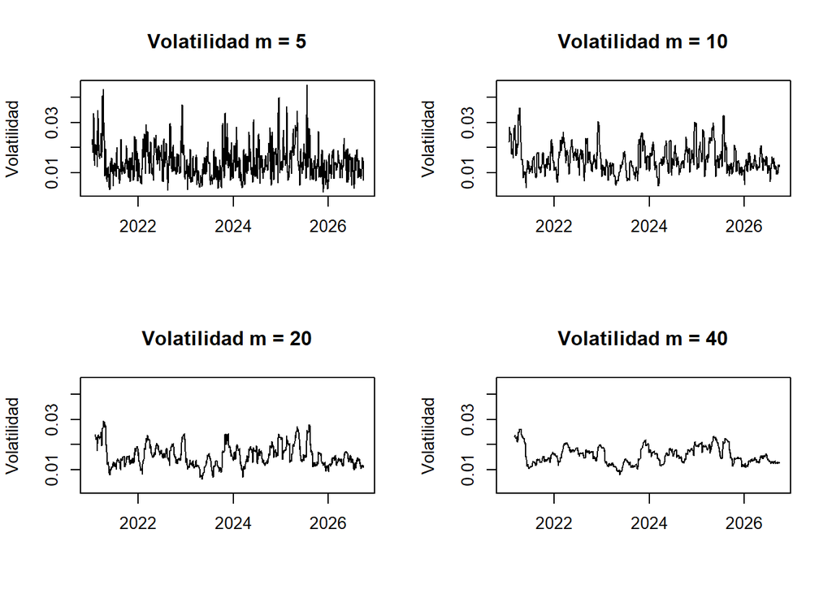

```r
# Misma escala en las cuatro gráficas para poder compararlas
limy <- range(c(vol_5, vol_10, vol_20, vol_40), na.rm = TRUE)

par(mfrow = c(2,2))
plot(index(vol_5), as.numeric(vol_5), type = "l",
     main = "Volatilidad m = 5", xlab = "", ylab = "Volatilidad", ylim = limy)

plot(index(vol_10), as.numeric(vol_10), type = "l",
     main = "Volatilidad m = 10", xlab = "", ylab = "Volatilidad", ylim = limy)

plot(index(vol_20), as.numeric(vol_20), type = "l",
     main = "Volatilidad m = 20", xlab = "", ylab = "Volatilidad", ylim = limy)

plot(index(vol_40), as.numeric(vol_40), type = "l",
     main = "Volatilidad m = 40", xlab = "", ylab = "Volatilidad", ylim = limy)
```

```r
par(mfrow = c(1,1))
```

Interpretación del comportamiento de la volatilidad

Las estimaciones muestran que, conforme aumenta el tamaño de la ventana, la volatilidad de WALMEX presenta un comportamiento más estable. El modelo de 5 días registra fluctuaciones pronunciadas y mayor sensibilidad a los movimientos recientes, mientras que las ventanas de 20 y 40 días suavizan estas variaciones. Sin embargo, una ventana más amplia también implica una respuesta más lenta ante cambios repentinos del mercado, por lo que resulta necesario equilibrar estabilidad y capacidad de reacción.

Evaluación y selección del valor óptimo de m Para seleccionar el más adecuado, dividiremos los rendimientos históricos en 70% para entrenamiento y 30% para evaluación, Compararemos la varianza estimada con los rendimientos observados al cuadrado.

Evaluaremos tres indicadores: RMSE, MAE y QLIKE. En todos buscamos minimizar el error.

calcular los errores

```r
n <- NROW(rendimientos_cuadrado)
corte <- floor(0.70 * n)

fecha_prueba <- index(rendimientos_cuadrado)[corte + 1]

evaluar_modelo <- function(var_m) {

  pronostico <- stats::lag(var_m, k = 1)

  datos <- na.omit(merge(rendimientos_cuadrado, pronostico))
  colnames(datos) <- c("Realizada", "Estimada")

  datos <- datos[paste0(fecha_prueba, "/")]

  y <- as.numeric(datos$Realizada)
  f <- as.numeric(datos$Estimada)

  RMSE <- sqrt(mean((y - f)^2))
  MAE <- mean(abs(y - f))
  QLIKE <- mean(log(f) + y / f)

  return(c(RMSE = RMSE, MAE = MAE, QLIKE = QLIKE))
}

tabla_errores <- rbind(
  "m = 5" = evaluar_modelo(var_5),
  "m = 10" = evaluar_modelo(var_10),
  "m = 20" = evaluar_modelo(var_20),
  "m = 40" = evaluar_modelo(var_40)
)

round(tabla_errores, 6)
```

```
##            RMSE      MAE     QLIKE
## m = 5  0.000548 0.000290 -6.638055
## m = 10 0.000532 0.000284 -7.057858
## m = 20 0.000519 0.000283 -7.249816
## m = 40 0.000520 0.000283 -7.251203
```

Decisión.

```r
apply(tabla_errores, 2, which.min)
```

```
##  RMSE   MAE QLIKE
##     3     3     4
```

Selección del valor óptimo de m = 20 ya que presentó el menor RMSE y MAE. Aunque el modelo de 40 días obtuvo un QLIKE ligeramente menor, la ventana de 20 días ofrece un mejor desempeño en dos de los tres indicadores evaluados.

### 4.2.2 Modelo EWMA

El modelo de Media Móvil Exponencialmente Ponderada (EWMA) estima la varianza asignando mayor importancia a los rendimientos recientes. A diferencia del promedio móvil simple, las observaciones no tienen el mismo peso, sino que su influencia disminuye progresivamente conforme pasa el tiempo, Donde lambda determina la importancia de la varianza anterior: mientras menor sea su valor, mayor será la sensibilidad a los movimientos recientes.

$$\sigma_t^2 = (1-\lambda)R_{t-1}^2 + \lambda\sigma_{t-1}^2$$

Estimación del modelo

Usaremos inicialmente lambda=0.94 como valor de referencia, sin considerarlo todavía el parámetro óptimo. Más adelante justificaremos su selección.

```r
lambda <- 0.94

r2 <- as.numeric(rendimientos_cuadrado)
n <- length(r2)

var_ewma <- rep(NA_real_, n)

var_ewma[21] <- mean(r2[1:20])

for (t in 22:n) {
  var_ewma[t] <- (1 - lambda) * r2[t-1] +
                  lambda * var_ewma[t-1]
}

var_ewma <- xts(var_ewma,
                order.by = index(rendimientos_cuadrado))

vol_ewma <- sqrt(var_ewma)
```

Visualización

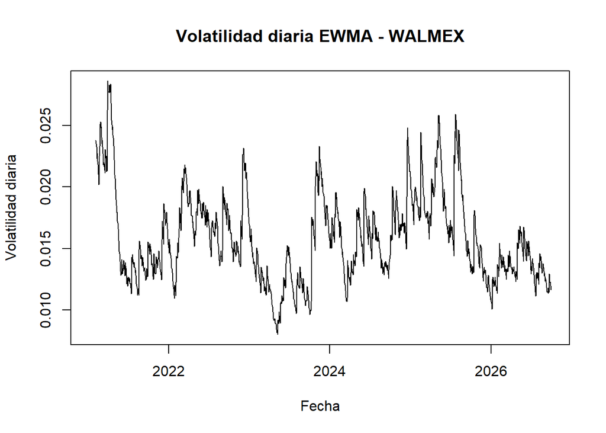

```r
plot(index(vol_ewma), as.numeric(vol_ewma),
     type = "l",
     main = "Volatilidad diaria EWMA - WALMEX",
     xlab = "Fecha",
     ylab = "Volatilidad diaria")
```

Comparación estadística de ambos modelos

```r
# Comparación: Promedio Móvil vs EWMA
datos_comp <- merge(
  rendimientos_cuadrado,
  stats::lag(var_20, k = 1),
  var_ewma
)

colnames(datos_comp) <- c("Realizada", "MA20", "EWMA")

datos_comp <- na.omit(
  datos_comp[paste0(fecha_prueba, "/")]
)

y <- as.numeric(datos_comp$Realizada)
ma20 <- as.numeric(datos_comp$MA20)
ewma <- as.numeric(datos_comp$EWMA)

tabla_comp <- rbind(
  "MA20" = c(
    RMSE = sqrt(mean((y - ma20)^2)),
    MAE = mean(abs(y - ma20)),
    QLIKE = mean(log(ma20) + y / ma20)
  ),
  "EWMA" = c(
    RMSE = sqrt(mean((y - ewma)^2)),
    MAE = mean(abs(y - ewma)),
    QLIKE = mean(log(ewma) + y / ewma)
  )
)

round(tabla_comp, 6)
```

```
##          RMSE      MAE     QLIKE
## MA20 0.000519 0.000283 -7.249816
## EWMA 0.000515 0.000278 -7.267833
```

Comparación gráfica de volatilidades

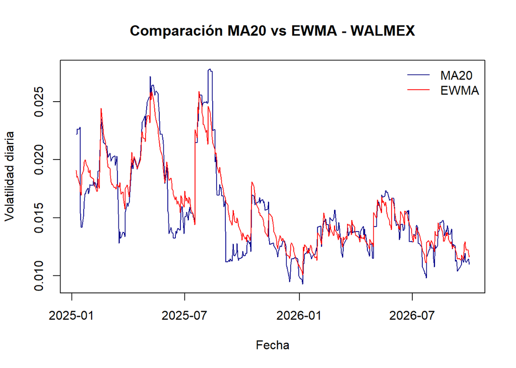

```r
# Comparación visual

vol_ma20 <- sqrt(ma20)
vol_ewma_comp <- sqrt(ewma)

plot(index(datos_comp), vol_ma20,
     type = "l",
     col = "darkblue",
     main = "Comparación MA20 vs EWMA - WALMEX",
     xlab = "Fecha",
     ylab = "Volatilidad diaria",
     ylim = range(c(vol_ma20, vol_ewma_comp)))

lines(index(datos_comp), vol_ewma_comp,
      col = "red")

legend("topright",
       legend = c("MA20", "EWMA"),
       col = c("darkblue", "red"),
       lty = 1,
       bty = "n")
```

Comparación entre EWMA y Promedio Móvil

Los resultados muestran que el modelo EWMA con λ = 0.94 presenta un mejor desempeño que el Promedio Móvil de 20 días, al obtener menores valores de RMSE, MAE y QLIKE. Esto indica una mayor precisión en la estimación de la varianza de WALMEX durante el periodo de evaluación.

Gráficamente, ambos modelos identifican periodos similares de alta y baja volatilidad. Sin embargo, EWMA presenta transiciones más graduales, mientras que MA20 registra cambios más abruptos cuando observaciones extremas salen de su ventana. Esto se explica porque EWMA reduce progresivamente el peso de los rendimientos anteriores, en lugar de eliminarlos al superar un número fijo de días.

Se utilizó un valor de λ = 0.94 como parámetro de referencia para rendimientos diarios. Esta elección permite asignar un peso del 6% a la innovación más reciente y conservar el 94% de la varianza estimada anteriormente, equilibrando sensibilidad y persistencia. Su desempeño se evaluó mediante indicadores de error, sin asumir que representa necesariamente el parámetro óptimo para WALMEX.

### 4.2.3 Modelo Data Driven EWMA

El modelo Data Driven EWMA mantiene la estructura del EWMA tradicional, pero permite estimar el parámetro alpha mediante los datos históricos. Para ello, utilizaremos el método de Máxima Verosimilitud, buscando el parámetro que mejor explique los rendimientos observados.

$$\sigma_t^2 = \alpha R_{t-1}^2 + (1-\alpha)\sigma_{t-1}^2$$

$$\alpha = 1-\lambda$$

Estimar el parámetro óptimo

Utilizaremos el 70% de entrenamiento que ya definimos. El 30% restante quedará reservado para evaluar el desempeño predictivo.

```r
# Optimización mediante Máxima Verosimilitud
r2 <- as.numeric(rendimientos_cuadrado)

neg_log_verosimilitud <- function(alpha) {

  varianza <- rep(NA_real_, corte)

  varianza[21] <- mean(r2[1:20])

  for (t in 22:corte) {
    varianza[t] <- alpha * r2[t-1] +
                   (1-alpha) * varianza[t-1]
  }

  resultado <- 0.5 * sum(
    log(2*pi*varianza[21:corte]) +
    r2[21:corte] / varianza[21:corte]
  )

  return(resultado)
}

# Buscar alpha óptimo
optimo <- optimize(
  neg_log_verosimilitud,
  interval = c(0.001, 0.999)
)

alpha_optimo <- optimo$minimum
lambda_optimo <- 1 - alpha_optimo

c(
  alpha_optimo = alpha_optimo,
  lambda_optimo = lambda_optimo
)
```

```
##  alpha_optimo lambda_optimo
##    0.03117929    0.96882071
```

Estimar la volatilidad Data Driven EWMA

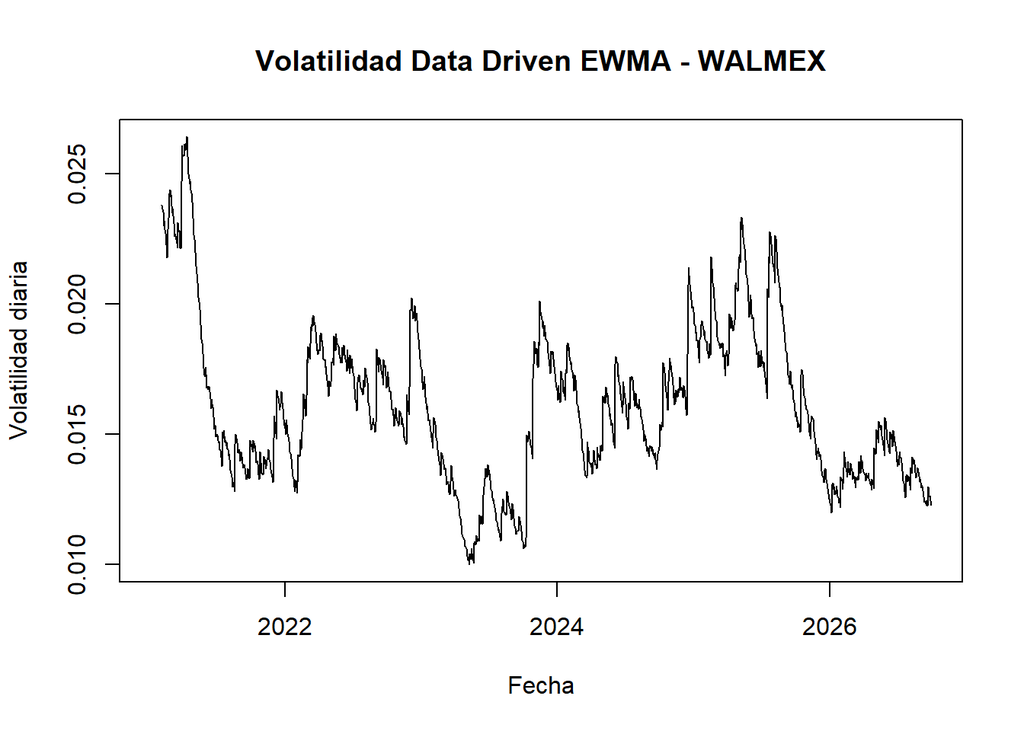

```r
var_dd <- rep(NA_real_, n)

var_dd[21] <- mean(r2[1:20])

for (t in 22:n) {
  var_dd[t] <- alpha_optimo * r2[t-1] +
               (1-alpha_optimo) * var_dd[t-1]
}

var_dd <- xts(var_dd,
              order.by = index(rendimientos_cuadrado))

vol_dd <- sqrt(var_dd)

plot(index(vol_dd), as.numeric(vol_dd),
     type = "l",
     main = "Volatilidad Data Driven EWMA - WALMEX",
     xlab = "Fecha",
     ylab = "Volatilidad diaria")
```

Comparación EWMA vs. Data Driven EWMA

```r
datos_dd <- na.omit(merge(
  datos_comp[, c("Realizada", "EWMA")],
  var_dd
))

colnames(datos_dd) <- c("Realizada", "EWMA", "DataDriven")

errores_dd <- function(f) {
  y <- as.numeric(datos_dd$Realizada)
  f <- as.numeric(f)

  c(
    RMSE = sqrt(mean((y-f)^2)),
    MAE = mean(abs(y-f)),
    QLIKE = mean(log(f) + y/f)
  )
}

tabla_dd <- rbind(
  "EWMA" = errores_dd(datos_dd$EWMA),
  "Data Driven" = errores_dd(datos_dd$DataDriven)
)

round(tabla_dd, 6)
```

```
##                 RMSE      MAE     QLIKE
## EWMA        0.000515 0.000278 -7.267833
## Data Driven 0.000512 0.000280 -7.292845
```

Interpretación y comparación del modelo Data Driven EWMA

Mediante Máxima Verosimilitud se obtuvo un parámetro óptimo de α = 0.03118, equivalente a λ = 0.96882, lo que indica una mayor persistencia de la volatilidad y una menor sensibilidad a los movimientos recientes respecto al EWMA tradicional (λ = 0.94).

$$\sigma_t^2 = 0.03117944 R_{t-1}^2 + 0.96882056\sigma_{t-1}^2$$

En la evaluación, el modelo Data Driven presentó menores valores de RMSE y QLIKE, mientras que EWMA tradicional obtuvo un MAE ligeramente inferior. Por lo tanto, el Data Driven muestra un mejor desempeño en dos de los tres indicadores, aunque las diferencias son reducidas. Esto sugiere que ajustar el parámetro a los datos históricos de WALMEX puede mejorar la precisión de las estimaciones sin garantizar una superioridad en todos los criterios.

### 4.2.4 Modelos ARCH/GARCH

Permiten estimar una volatilidad que cambia con el tiempo, considerando la influencia de las innovaciones pasadas y, en el caso de GARCH, de las varianzas condicionales anteriores. Su aplicación permite identificar la persistencia del riesgo y evaluar cómo responde la volatilidad de WALMEX ante nuevas fluctuaciones del mercado.

Estimar el modelo de la media (ARMA)

$$R_t = \mu_t + \varepsilon_t$$

```r
r_train <- rendimientos[1:corte]
r_test <- rendimientos[(corte+1):n]

Trn <- nrow(r_train)
Ten <- nrow(r_test)

modelo_media <- auto.arima(
  as.numeric(r_train),
  d = 0,
  stationary = TRUE,
  seasonal = FALSE
)

summary(modelo_media)
```

```
## Series: as.numeric(r_train)
## ARIMA(3,0,2) with zero mean
##
## Coefficients:
##          ar1     ar2      ar3      ma1      ma2
##       0.2097  0.5954  -0.0064  -0.3362  -0.5786
## s.e.  0.2237  0.1776   0.0416   0.2215   0.2125
##
## sigma^2 = 0.0002584:  log likelihood = 2741.14
## AIC=-5470.28   AICc=-5470.2   BIC=-5440.78
##
## Training set error measures:
##                        ME       RMSE      MAE MPE MAPE      MASE         ACF1
## Training set 0.0001807567 0.01603412 0.012234 NaN  Inf 0.6721685 3.157619e-05
```

Identificar los órdenes del ARMA y obtener los residuos

```r
orden_media <- arimaorder(modelo_media)

p_media <- orden_media[1]
q_media <- orden_media[3]

arma_order <- c(p_media, q_media)
arma_order
```

```
## p q
## 3 2
```

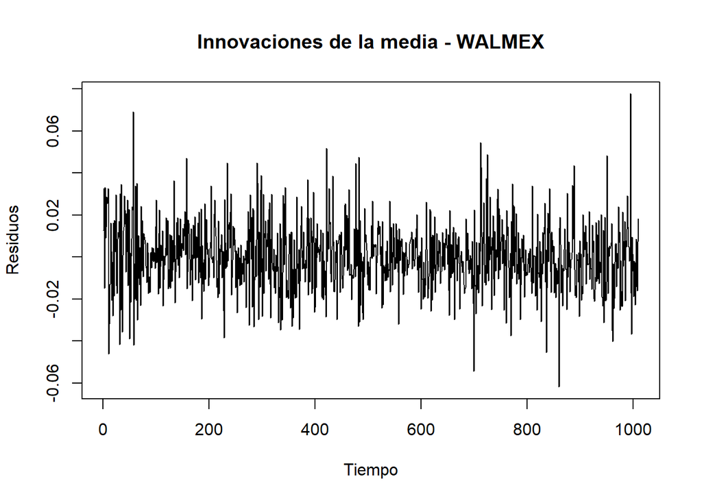

```r
residuos_media <- residuals(modelo_media)

plot(residuos_media,
     type = "l",
     main = "Innovaciones de la media - WALMEX",
     xlab = "Tiempo",
     ylab = "Residuos")
```

Interpretación del modelo de la media

Se estimó un modelo ARMA(3,2) para representar el comportamiento de la media de los rendimientos diarios de WALMEX. Los residuos presentan fluctuaciones alrededor de cero, con algunos episodios de mayor amplitud, lo que sugiere posibles cambios en la volatilidad. Para determinar si existe evidencia estadística de heterocedasticidad condicional, se aplicará la prueba ARCH-LM.

Prueba ARCH-LM

$$H_0: \text{No existen efectos ARCH en los residuos}$$

$$H_a: \text{Existen efectos ARCH en los residuos}$$

```r
ArchLM <- function(x, lags = 20) {

  x <- na.omit(as.numeric(x))

  mat <- embed(x^2, lags + 1)

  modelo_aux <- lm(mat[, 1] ~ mat[, -1])

  R2 <- summary(modelo_aux)$r.squared
  n_aux <- length(residuals(modelo_aux))

  estadistico <- n_aux * R2

  p_value <- pchisq(
    estadistico,
    df = lags,
    lower.tail = FALSE
  )

  return(c(
    Estadistico = estadistico,
    p_value = p_value
  ))
}

ArchLM(residuos_media)
```

```
## Estadistico     p_value
## 29.69970769  0.07486779
```

Estimación de modelos ARCH/GARCH

ARCH(p):
$$\sigma_t^2 = \omega + \sum_{i=1}^{p}\alpha_i\varepsilon_{t-i}^2$$

GARCH(p,q):
$$\sigma_t^2 = \omega + \sum_{i=1}^{p}\alpha_i\varepsilon_{t-i}^2 +
\sum_{j=1}^{q}\beta_j\sigma_{t-j}^2$$

```r
modelos <- data.frame(
  modelo = c("ARCH(1)", "ARCH(2)", "GARCH(1,1)",
             "GARCH(1,2)", "GARCH(2,1)", "GARCH(2,2)"),
  p = c(1, 2, 1, 1, 2, 2),
  q = c(0, 0, 1, 2, 1, 2)
)

ajustes <- list()

for (i in 1:nrow(modelos)) {

  spec <- ugarchspec(
    variance.model = list(
      model = "sGARCH",
      garchOrder = c(modelos$p[i], modelos$q[i])
    ),
    mean.model = list(
      armaOrder = arma_order,
      include.mean = TRUE
    ),
    distribution.model = "norm"
  )

  ajustes[[modelos$modelo[i]]] <- tryCatch(
    ugarchfit(
      spec = spec,
      data = rendimientos,
      out.sample = Ten,
      solver = "hybrid"
    ),
    error = function(e) {
      message("No se pudo estimar ", modelos$modelo[i])
      return(NULL)
    }
  )
}
```

Comparar los modelos

```r
resumen_modelo <- function(f) {

  if (is.null(f)) {
    return(c(Convergio = 0, LogLik = NA,
             AIC = NA, BIC = NA))
  }

  ll <- as.numeric(likelihood(f))
  k <- length(coef(f))

  c(
    Convergio = as.numeric(f@fit$convergence == 0),
    LogLik = ll,
    AIC = -2 * ll + 2 * k,
    BIC = -2 * ll + log(Trn) * k
  )
}

tabla_modelos <- t(sapply(ajustes, resumen_modelo))

round(tabla_modelos, 3)
```

```
##            Convergio   LogLik       AIC       BIC
## ARCH(1)            1 2742.690 -5469.380 -5430.038
## ARCH(2)            1 2745.325 -5472.649 -5428.390
## GARCH(1,1)         1 2755.119 -5492.239 -5447.979
## GARCH(1,2)         1 2757.556 -5495.111 -5445.934
## GARCH(2,1)         1 2755.120 -5490.239 -5441.062
## GARCH(2,2)         1 2757.691 -5493.382 -5439.287
```

Decisión:

```r
# Revisar significancia de los modelos

tabla_sig <- data.frame(
  Modelo = names(ajustes),

  No_significativos = sapply(ajustes, function(fit) {

    tabla <- fit@fit$matcoef

    filas <- grepl("^(omega|alpha|beta)", rownames(tabla))

    p <- tabla[filas, 4]

    malos <- rownames(tabla)[filas][p >= 0.05]

    if (length(malos) == 0) "Ninguno"
    else paste(malos, collapse = ", ")
  })
)

rownames(tabla_sig) <- NULL
tabla_sig
```

| Modelo | No_significativos |
| --- | --- |
| ARCH(1) | Ninguno |
| ARCH(2) | Ninguno |
| GARCH(1,1) | Ninguno |
| GARCH(1,2) | beta1 |
| GARCH(2,1) | alpha1, alpha2 |
| GARCH(2,2) | alpha2, beta1 |

Selección del modelo ARCH/GARCH

En consecuencia, GARCH(1,1) representa la alternativa más adecuada entre los modelos estimados para describir la volatilidad condicional de WALMEX, considerando ajuste estadístico y parsimonia.

Parámetros del modelo GARCH(1,1)

$$\sigma_t^2 = \omega + \alpha_1\varepsilon_{t-1}^2 +
\beta_1\sigma_{t-1}^2$$

Calcular persistencia y volatilidad de largo plazo

$$\text{Persistencia} = \alpha_1 + \beta_1$$

$$V_{LP} = \frac{\omega}{1-\alpha_1-\beta_1}$$

$$\sigma_{LP} = \sqrt{V_{LP}}$$

```r
# Modelo seleccionado

modelo_optimo <- ajustes[["GARCH(1,1)"]]

# Extraer parámetros

w <- coef(modelo_optimo)["omega"]
alpha <- coef(modelo_optimo)["alpha1"]
beta <- coef(modelo_optimo)["beta1"]

# Persistencia

persistencia <- alpha + beta

# Varianza y volatilidad de largo plazo

var_LP <- w / (1 - persistencia)
vol_LP <- sqrt(var_LP)

# Resultados

resultados_garch <- data.frame(
  Parametro = c("Omega", "Alpha", "Beta",
                "Persistencia", "Varianza LP",
                "Volatilidad LP diaria (%)"),
  Valor = c(w, alpha, beta,
            persistencia, var_LP,
            vol_LP * 100)
)

resultados_garch$Valor <- round(resultados_garch$Valor, 6)
resultados_garch
```

| Parametro | Valor |
| --- | --- |
| Omega | 0.000012 |
| Alpha | 0.044577 |
| Beta | 0.909557 |
| Persistencia | 0.954135 |
| Varianza LP | 0.000254 |
| Volatilidad LP diaria (%) | 1.594836 |

Diagnóstico del modelo GARCH(1,1)

$$z_t = \frac{\varepsilon_t}{\sigma_t}$$

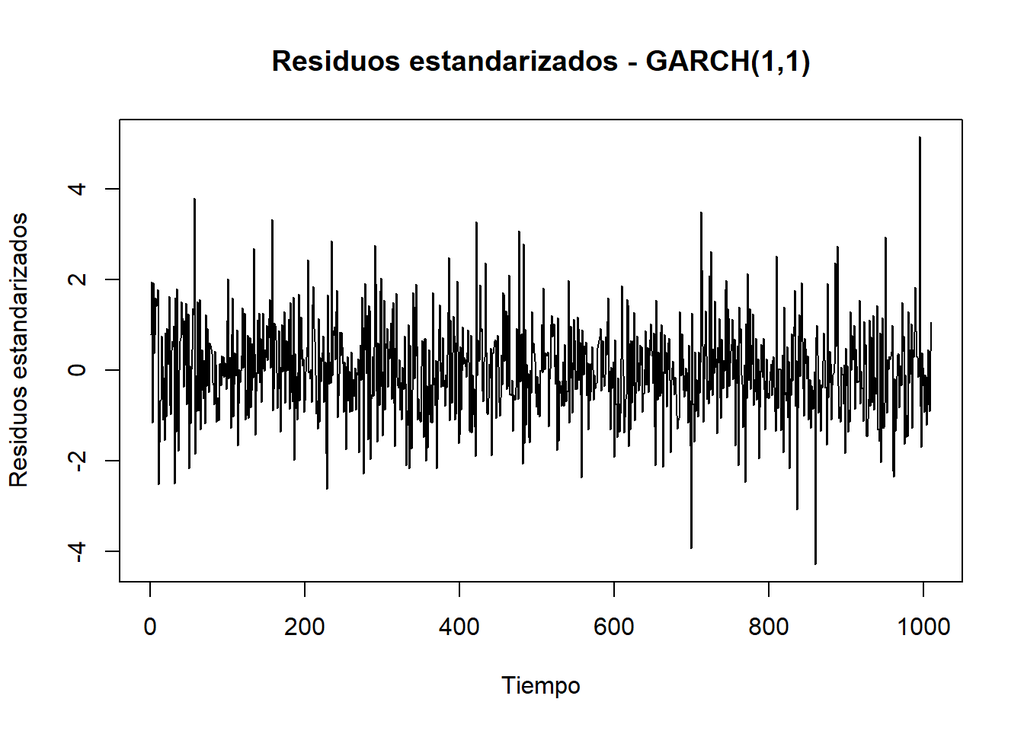

```r
# Residuos estandarizados del GARCH(1,1)

residuos_std <- residuals(
  modelo_optimo,
  standardize = TRUE
)

# Gráfica

plot(as.numeric(residuos_std),
     type = "l",
     main = "Residuos estandarizados - GARCH(1,1)",
     xlab = "Tiempo",
     ylab = "Residuos estandarizados")
```

```r
# Prueba ARCH-LM con 20 rezagos

ArchLM(residuos_std)
```

```
## Estadistico     p_value
##   15.183520    0.765812
```

$$H_0: \text{No existen efectos ARCH remanentes}$$

$$H_a: \text{Existen efectos ARCH remanentes}$$

Este resultado es favorable para el ajuste del modelo, ya que sugiere que representa adecuadamente la dependencia de la volatilidad identificable mediante esta prueba. Sin embargo, dado que la prueba inicial tampoco fue significativa al 5%, este resultado debe interpretarse como evidencia de un diagnóstico satisfactorio, no como una demostración definitiva de la necesidad de utilizar GARCH.

Reestimar GARCH(1,1) con toda la muestra

```r
spec_final <- ugarchspec(
  variance.model = list(
    model = "sGARCH",
    garchOrder = c(1, 1)
  ),
  mean.model = list(
    armaOrder = arma_order,
    include.mean = TRUE
  ),
  distribution.model = "norm"
)

garch_final <- ugarchfit(
  spec = spec_final,
  data = rendimientos,
  solver = "hybrid"
)

garch_final@fit$convergence
```

```
## [1] 0
```

```r
coef(garch_final)
```

```
##            mu           ar1           ar2           ar3           ma1
## -1.578577e-04  1.220387e+00 -2.585710e-01 -5.994605e-02 -1.346340e+00
##           ma2         omega        alpha1         beta1
##  3.991745e-01  8.872083e-06  3.672361e-02  9.281245e-01
```

Actualización de Data Driven EWMA

```r
# Parámetro final Data Driven EWMA
n_total <- length(r2)

neg_log_final <- function(alpha) {

  varianza <- rep(NA_real_, n_total)
  varianza[21] <- mean(r2[1:20])

  for (t in 22:n_total) {
    varianza[t] <- alpha * r2[t-1] +
                   (1-alpha) * varianza[t-1]
  }

  0.5 * sum(
    log(2*pi*varianza[21:n_total]) +
    r2[21:n_total] / varianza[21:n_total]
  )
}

optimo_final <- optimize(
  neg_log_final,
  interval = c(0.001, 0.999)
)

alpha_final <- optimo_final$minimum
lambda_final <- 1 - alpha_final

c(
  alpha_final = alpha_final,
  lambda_final = lambda_final
)
```

```
##  alpha_final lambda_final
##   0.02639124   0.97360876
```

### 4.2.5 Tabla de parámetros finales

```r
# Resumen final de los modelos
parametros_finales <- data.frame(
  Modelo = c("Promedio Móvil",
             "EWMA",
             "Data Driven EWMA",
             "GARCH(1,1)"),

  Parametros = c(
    "m = 20",
    "lambda = 0.94",
    paste0("alpha = ", round(alpha_final, 6)),
    paste0(
      "omega = ", signif(coef(garch_final)["omega"], 5),
      "; alpha = ", round(coef(garch_final)["alpha1"], 6),
      "; beta = ", round(coef(garch_final)["beta1"], 6)
    )
  )
)

parametros_finales
```

| Modelo | Parametros |
| --- | --- |
| Promedio Móvil | m = 20 |
| EWMA | lambda = 0.94 |
| Data Driven EWMA | alpha = 0.026391 |
| GARCH(1,1) | omega = 8.8721e-06; alpha = 0.036724; beta = 0.928124 |

Síntesis de la estimación de modelos

Se estimaron cuatro metodologías para analizar la volatilidad de WALMEX: Promedio Móvil, EWMA, Data Driven EWMA y ARCH/GARCH. Para el Promedio Móvil se seleccionó una ventana de 20 días, mientras que el EWMA tradicional utilizó λ = 0.94 como parámetro de referencia. En el modelo Data Driven, el parámetro se determinó mediante Máxima Verosimilitud.

Por su parte, se seleccionó GARCH(1,1) entre seis modelos candidatos, considerando la significancia de sus parámetros, los criterios de información y la parsimonia. Sus resultados mostraron una elevada persistencia de la volatilidad y ausencia de efectos ARCH remanentes significativos en el diagnóstico realizado.

Estas estimaciones proporcionan la base para evaluar y comparar la capacidad predictiva de los modelos durante octubre de 2026.

## 4.3 Evaluación de modelos

Los parámetros se estimaron con información hasta el 30 de septiembre y se mantienen fijos. Para cada día de octubre la varianza solo se actualiza con el rendimiento del día anterior.

Datos de octubre

```r
precio_oct <- na.omit(Ad(getSymbols(clave, from = "2026-09-01",
                                    to = "2026-10-31", auto.assign = FALSE)))
rend_oct <- dailyReturn(precio_oct, type = "log")["2026-10-01/2026-10-30"]
names(rend_oct) <- "rendimiento"

rend_total <- rbind(rendimientos, rend_oct)
r2_total <- rend_total^2
r2_vec <- as.numeric(r2_total)
```

Estimación de la volatilidad diaria del 5 al 30 de octubre

```r
ewma_rec <- function(a, r2v) {
  v <- rep(length(r2v))
  v[21] <- mean(r2v[1:20])
  for (t in 22:length(r2v)) {
    v[t] <- a * r2v[t-1] + (1 - a) * v[t-1]
  }
  v
}

# Promedio Móvil m = 20
var_ma_oct <- stats::lag(SMA(r2_total, n = 20), k = 1)

# EWMA lambda = 0.94
var_ewma_oct <- xts(ewma_rec(1 - 0.94, r2_vec), order.by = index(r2_total))

# Data Driven EWMA
var_dd_oct <- xts(ewma_rec(alpha_final, r2_vec), order.by = index(r2_total))

# GARCH(1,1) con parámetros fijos
spec_fija <- spec_final
setfixed(spec_fija) <- as.list(coef(garch_final))
filtro_garch <- ugarchfilter(spec = spec_fija, data = rend_total,
                             n.old = NROW(rendimientos))
var_garch_oct <- xts(as.numeric(sigma(filtro_garch))^2,
                     order.by = index(rend_total))
```

Tabla de valores observados vs estimados

La volatilidad realizada es la raíz del rendimiento al cuadrado. Valores en porcentaje.

```r
eval_oct <- merge(r2_total, var_ma_oct, var_ewma_oct,
                  var_dd_oct, var_garch_oct)["2026-10-05/2026-10-30"]

tabla_oct <- data.frame(
  Fecha = index(eval_oct),
  Realizada = sqrt(as.numeric(eval_oct[, 1])) * 100,
  MA20 = sqrt(as.numeric(eval_oct[, 2])) * 100,
  EWMA = sqrt(as.numeric(eval_oct[, 3])) * 100,
  DD_EWMA = sqrt(as.numeric(eval_oct[, 4])) * 100,
  GARCH = sqrt(as.numeric(eval_oct[, 5])) * 100
)

tabla_oct
```

| Fecha | Realizada | MA20 | EWMA | DD_EWMA | GARCH |
| --- | --- | --- | --- | --- | --- |
| 2026-10-05 | 0.75635144 | 1.106289 | 1.154313 | 1.235161 | 1.360526 |
| 2026-10-06 | 0.51535361 | 1.103900 | 1.134379 | 1.224931 | 1.350039 |
| 2026-10-07 | 0.00000000 | 1.090853 | 1.107042 | 1.211556 | 1.339580 |
| 2026-10-08 | 1.31917632 | 1.075478 | 1.073317 | 1.195462 | 1.324559 |
| 2026-10-09 | 0.02114244 | 1.099089 | 1.089635 | 1.198891 | 1.336035 |
| 2026-10-12 | 1.13518170 | 1.098712 | 1.056453 | 1.182970 | 1.321698 |
| 2026-10-13 | 1.32564057 | 1.095164 | 1.061341 | 1.181733 | 1.328771 |
| 2026-10-14 | 1.11639404 | 1.111045 | 1.079026 | 1.185756 | 1.329910 |
| 2026-10-15 | 1.06261205 | 1.115307 | 1.081305 | 1.183977 | 1.332501 |
| 2026-10-16 | 2.15282513 | 1.075103 | 1.080192 | 1.180935 | 1.342800 |

[output cut: 10 more lines]

Comparación gráfica

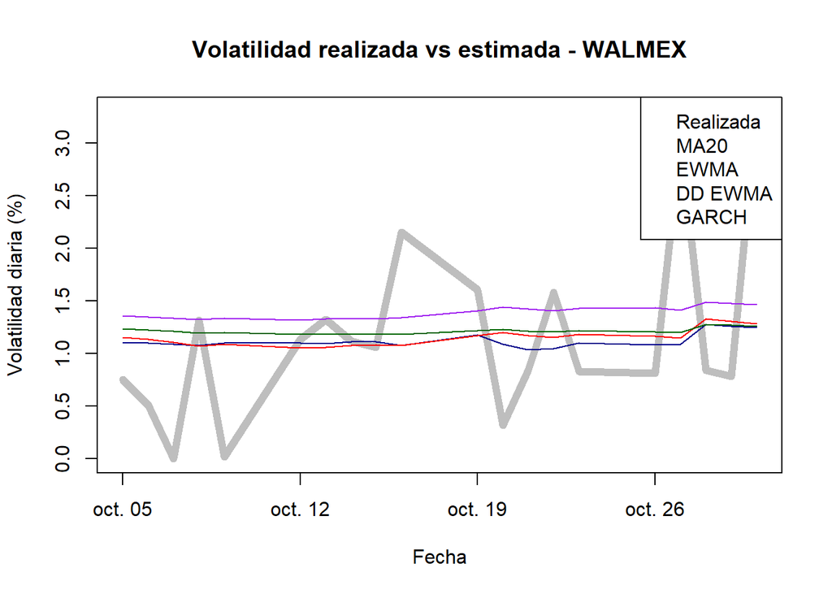

```r
plot(tabla_oct$Fecha, tabla_oct$Realizada, type = "l", lwd = 6, col = "grey",
     ylim = range(tabla_oct[, -1]),
     main = "Volatilidad realizada vs estimada - WALMEX",
     xlab = "Fecha", ylab = "Volatilidad diaria (%)")
lines(tabla_oct$Fecha, tabla_oct$MA20, col = "darkblue")
lines(tabla_oct$Fecha, tabla_oct$EWMA, col = "red")
lines(tabla_oct$Fecha, tabla_oct$DD_EWMA, col = "darkgreen")
lines(tabla_oct$Fecha, tabla_oct$GARCH, col = "purple")
legend("topright", legend = c("Realizada", "MA20", "EWMA", "DD EWMA", "GARCH"),
       col = c("grey", "darkblue", "red", "darkgreen", "purple"))
```

## 4.4 4. Análisis e Interpretación

### 4.4.1 ¿Qué modelo captura mejor los periodos de alta volatilidad?

El modelo GARCH(1,1) permite representar mejor la persistencia de los periodos de alta volatilidad, ya que considera tanto los movimientos inesperados del mercado como la volatilidad de días anteriores. En WALMEX, su persistencia, nos ayudó a indicar que los episodios de mayor riesgo no desaparecen inmediatamente, sino que sus efectos permanecen durante varios días. Por otra parte, el modelo EWMA también identifica estos periodos al dar mayor importancia a los rendimientos recientes.

### 4.4.3 ¿Qué modelo presenta mayor estabilidad en sus estimaciones?

El modelo GARCH(1,1) presenta una estructura estable al incorporar la persistencia de la volatilidad y regresar gradualmente hacia su nivel de largo plazo. Su volatilidad diaria de largo plazo se estimó en aproximadamente 1.60%. El Data Driven EWMA también genera estimaciones relativamente suaves debido a su elevado lambda. En cambio, el Promedio Móvil puede presentar variaciones más bruscas cuando las observaciones extremas entran o salen de la ventana de 20 días.

### 4.4.4 ¿Qué modelo tiende a sobreestimar o subestimar la volatilidad?

La tendencia a sobreestimar o subestimar depende de qué tan rápido cada modelo incorpora los cambios reales del mercado. El Data Driven EWMA, al asignar un peso menor a los movimientos recientes, puede subestimar inicialmente los aumentos repentinos de volatilidad. De manera similar, EWMA puede tardar en reflejar completamente un choque muy fuerte. El Promedio Móvil puede sobreestimar la volatilidad cuando un movimiento extremo permanece dentro de su ventana, aunque también puede reducirla bruscamente cuando sale de ella. GARCH(1,1) busca equilibrar estos efectos mediante la combinación de innovaciones recientes y varianza pasada. La dirección del error para cada modelo debe confirmarse con los resultados de la evaluación fuera de muestra.

## 4.5 5. Conclusión

En conjunto, los modelos permiten observar que la volatilidad de WALMEX no permanece constante, sino que cambia conforme aparecen nuevos movimientos en el mercado. El Promedio Móvil ofrece una referencia sencilla, aunque depende de una ventana fija de observaciones. EWMA mejora este comportamiento al dar mayor importancia a los rendimientos recientes, mientras que Data Driven EWMA permite ajustar esa sensibilidad mediante los propios datos históricos. Por su parte, GARCH(1,1) incorpora tanto los nuevos choques como la volatilidad pasada, lo que permite representar la persistencia del riesgo.

Los resultados muestran que no existe un modelo perfecto para todas las situaciones. EWMA obtuvo mejores resultados que el Promedio Móvil en los tres indicadores de error evaluados, mientras que Data Driven EWMA mejoró dos de los tres indicadores respecto al EWMA tradicional. Por otro lado, GARCH(1,1) fue seleccionado por su significancia estadística, menor BIC y estructura relativamente sencilla. Esto demuestra que la calidad de un modelo no depende únicamente de su ajuste estadístico, sino también de su capacidad para representar el comportamiento real del mercado.

Por ello utilizaríamos GARCH(1,1) como modelo principal para analizar el riesgo de WALMEX, debido a que permite identificar la persistencia de la volatilidad y reconocer que un periodo de incertidumbre elevada puede continuar afectando al activo durante varios días.

Consideramos que esta combinación permite obtener una visión más completa del riesgo, ya que una inversión no debe evaluarse únicamente por su comportamiento histórico, sino también por su capacidad para responder ante cambios inesperados. Finalmente, este ejercicio nos muestra que elegir un modelo implica reconocer sus limitaciones y que ninguna estimación puede anticipar completamente los movimientos del mercado.

# 5 Parte 5: Estimación del valor en riesgo

## 5.1 1. Introducción

En las entregas anteriores del proyecto se estudiaron los rendimientos y el comportamiento de la volatilidad de los activos financieros. En esta quinta etapa se busca integrar estos conocimientos mediante la estimación del Valor en Riesgo (VaR) de un portafolio de seis acciones, con una inversión inicial de 600,000 pesos mexicanos (MXN).

El propósito es evaluar el riesgo de mercado mediante el VaR no paramétrico por simulación histórica y el VaR paramétrico bajo el supuesto de normalidad, considerando distintos niveles de confianza y horizontes de inversión. Posteriormente, se comparan ambas metodologías tanto en sus estimaciones estáticas como en su desempeño dinámico mediante *backtesting*, y se determina una composición óptima del portafolio que minimice el VaR para analizar su impacto en el riesgo y la diversificación. Por último, se estima el VaR y el Expected Shortfall individual de WALMEX por simulación de Montecarlo y se interpretan los resultados contrastando lo que dice la teoría con lo que realmente muestran los datos.

Como punto de partida, se construye el portafolio, se homogeneizan los precios en una misma moneda y se calculan los rendimientos. Esta preparación permite que las estimaciones posteriores utilicen una base de datos consistente y que las diferencias entre metodologías se atribuyan a sus supuestos y no a discrepancias en la información utilizada.

## 5.2 2. Construcción del portafolio

### 5.2.1 2.1. Selección de activos

Se seleccionaron seis empresas de México y Estados Unidos que pertenecen a diferentes sectores económicos. La elección busca incorporar distintas fuentes de exposición al riesgo, como el consumo, la movilidad, la tecnología, las tasas de interés, los precios de la energía y el sector salud. La diversificación sectorial y geográfica constituye un punto de partida; su efectividad deberá evaluarse posteriormente a partir de las relaciones entre los rendimientos.

- **Walmart de México (WALMEX.MX, México):** comercio minorista. Da continuidad al análisis previo y permite estudiar la exposición al consumo y al poder adquisitivo.
- **Grupo Aeroportuario del Sureste (ASURB.MX, México):** infraestructura aeroportuaria. Incorpora exposición al turismo y al transporte aéreo.
- **Microsoft (MSFT, Estados Unidos):** tecnología. Representa la inversión en software, servicios de nube e inteligencia artificial.
- **JPMorgan Chase (JPM, Estados Unidos):** servicios financieros. Permite considerar los efectos de las tasas de interés y del ciclo crediticio.
- **ExxonMobil (XOM, Estados Unidos):** energía. Introduce exposición a los precios del petróleo y a las condiciones del mercado energético.
- **Johnson & Johnson (JNJ, Estados Unidos):** salud. Incorpora exposición al sector farmacéutico y a la tecnología médica.

Se utilizan acciones en lugar de bonos u opciones para trabajar con una metodología homogénea de rendimientos de mercado. La inclusión de activos estadounidenses también incorpora riesgo cambiario, ya que el valor del portafolio se expresa en pesos mexicanos.

### 5.2.2 2.2. Librerías y parámetros iniciales

Se considera información desde enero de 2019, con el fin de incluir periodos de diferentes condiciones de mercado. Se fija el corte al 23 de noviembre de 2026, utilizando como fecha efectiva de valoración la última observación completa y común a todos los activos y al tipo de cambio.

```r
library(quantmod)
options(scipen = 999)
clave <- c("WALMEX.MX", "ASURB.MX", "MSFT", "JPM", "XOM", "JNJ")
empresas <- c("Walmart de México", "ASUR", "Microsoft",
              "JPMorgan Chase", "ExxonMobil", "Johnson & Johnson")
moneda <- c("MXN", "MXN", "USD", "USD", "USD", "USD")

capital_activo <- 100000
capital <- 600000
fecha_inicio <- as.Date("2019-01-01")
fecha_corte <- as.Date("2026-11-23")

confianza <- c(0.95, 0.975, 0.99)
horizontes <- c(1, 5, 10, 20)
```

El capital se distribuye de forma equitativa: 100,000 MXN en cada empresa, sin apalancamiento ni posiciones cortas. Para simplificar el ejercicio se permiten cantidades fraccionarias de acciones y se omiten comisiones e impuestos.

### 5.2.3 2.3. Descarga y preparación de precios

Se descargan los datos diarios de los seis activos y el tipo de cambio USD/MXN, expresado en pesos por dólar. Para estimar los rendimientos se utiliza la columna de cierre ajustado, que busca reducir las discontinuidades asociadas a eventos corporativos según los ajustes disponibles del proveedor. Para construir la posición inicial se utiliza el cierre de la fecha de valoración.

```r
getSymbols(clave, src = "yahoo", from = fecha_inicio,
           to = fecha_corte + 1)
```

```
## [1] "WALMEX.MX" "ASURB.MX"  "MSFT"      "JPM"       "XOM"       "JNJ"
```

```r
fx <- getSymbols("MXN=X", src = "yahoo", from = fecha_inicio,
                 to = fecha_corte + 1, auto.assign = FALSE)
precio1 <- Ad(get(clave[1]))
precio2 <- Ad(get(clave[2]))
precio3 <- Ad(get(clave[3]))
precio4 <- Ad(get(clave[4]))
precio5 <- Ad(get(clave[5]))
precio6 <- Ad(get(clave[6]))
tipo_cambio <- Cl(fx)
```

Debido a que México y Estados Unidos tienen calendarios bursátiles distintos, se conservan solamente las fechas con información disponible para los seis activos y el tipo de cambio. No se sustituyen datos faltantes por ceros ni se interpolan precios, para evitar introducir rendimientos artificiales. En consecuencia, un intervalo entre observaciones comunes puede abarcar más de una sesión de alguno de los mercados; esta limitación deberá considerarse al interpretar el horizonte diario del VaR.

```r
datos <- merge(precio1, precio2, precio3, precio4,
               precio5, precio6, tipo_cambio, all = FALSE)
colnames(datos) <- c(clave, "USD_MXN")
datos <- na.omit(datos)
datos <- datos[paste0(fecha_inicio, "/", fecha_corte)]

stopifnot(nrow(datos) > 1, all(is.finite(as.matrix(datos))),
          all(as.matrix(datos) > 0))
```

Para que los activos puedan compararse desde la perspectiva de un inversionista mexicano, se convierten a pesos los precios de las cuatro acciones estadounidenses. La conversión utiliza el tipo de cambio de cada fecha, no un tipo de cambio constante:

$$P_{i,t}^{MXN}=P_{i,t}^{USD}\times
TC_t$$

donde $TC_t$ representa los pesos mexicanos por dólar estadounidense en la fecha $t$. Los precios de WALMEX y ASUR ya están expresados en pesos.

```r
precios <- datos[, clave]
precios[, 3:6] <- sweep(as.matrix(precios[, 3:6]), 1,
                         as.numeric(datos$USD_MXN), "*")

fecha_val <- as.Date(index(tail(precios, 1)))
TC0 <- as.numeric(tail(datos$USD_MXN, 1))

# Cobertura de los datos y tipo de cambio de valoración
head(precios, 1)
```

```
##            WALMEX.MX ASURB.MX    MSFT      JPM      XOM      JNJ
## 2019-01-02  39.85895 220.1809 1841.82 1571.727 962.4876 2017.183
```

```r
fecha_val
```

```
## [1] "2026-11-23"
```

```r
nrow(precios)
```

```
## [1] 1698
```

```r
TC0
```

```
## [1] 19.07636
```

En las estimaciones de riesgo se trabajará con información en MXN. El uso de cierres de mercados distintos y de un tipo de cambio diario es una aproximación de valoración al cierre, no una cotización simultánea de todos los instrumentos.

### 5.2.4 2.4. Valor inicial y composición del portafolio

Se asigna el mismo capital a cada activo. Para determinar la cantidad de acciones se utiliza el cierre observado en la fecha de valoración, convertido a MXN cuando corresponde.

$$n_i=\frac{100,000}{P_{i,0}}$$

$$S_0=\sum_{i=1}^{6}n_iP_{i,0}$$

El peso de cada posición se obtiene dividiendo su valor entre el valor total del portafolio:

$$w_i=\frac{n_iP_{i,0}}{S_0}$$

```r
# Precios de cierre en su moneda original, en la misma fecha
P0_local <- sapply(clave, function(x) {
  as.numeric(Cl(get(x))[as.character(fecha_val)])
})

# Precios de cierre expresados en pesos
P0 <- P0_local
P0[3:6] <- P0[3:6] * TC0
stopifnot(length(P0) == 6, all(is.finite(P0)), all(P0 > 0))

# Cantidad de acciones, valor de cada posición y ponderaciones
numero <- capital_activo / P0
valor_posicion <- numero * P0
S0 <- sum(valor_posicion)
pesos <- valor_posicion / S0
V0 <- S0

portafolio <- data.frame(
  Empresa = empresas,
  Activo = clave,
  Moneda = moneda,
  Precio_local = P0_local,
  Precio_MXN = P0,
  Acciones = numero,
  Inversion_MXN = valor_posicion,
  Peso = pesos,
  row.names = NULL
)

stopifnot(abs(S0 - capital) < 0.01,
          all(abs(valor_posicion - capital_activo) < 0.01),
          abs(sum(pesos) - 1) < 1e-10)

portafolio
```

| Empresa | Activo | Moneda | Precio_local | Precio_MXN | Acciones | Inversion_MXN | Peso |
| --- | --- | --- | --- | --- | --- | --- | --- |
| Walmart de México | WALMEX.MX | MXN | 54.74 | 54.740 | 1826.81763 | 100000 | 0.1666667 |
| ASUR | ASURB.MX | MXN | 530.51 | 530.510 | 188.49786 | 100000 | 0.1666667 |
| Microsoft | MSFT | USD | 492.50 | 9395.108 | 10.64384 | 100000 | 0.1666667 |
| JPMorgan Chase | JPM | USD | 316.66 | 6040.720 | 16.55432 | 100000 | 0.1666667 |
| ExxonMobil | XOM | USD | 156.90 | 2993.081 | 33.41039 | 100000 | 0.1666667 |
| Johnson & Johnson | JNJ | USD | 270.05 | 5151.571 | 19.41155 | 100000 | 0.1666667 |

```r
S0
```

```
## [1] 600000
```

**Valor inicial del portafolio:** Cada posición representa aproximadamente el 16.67% del capital total. Las cantidades de acciones pueden ser distintas debido a las diferencias entre los precios de los activos. Los cálculos conservan la precisión original.

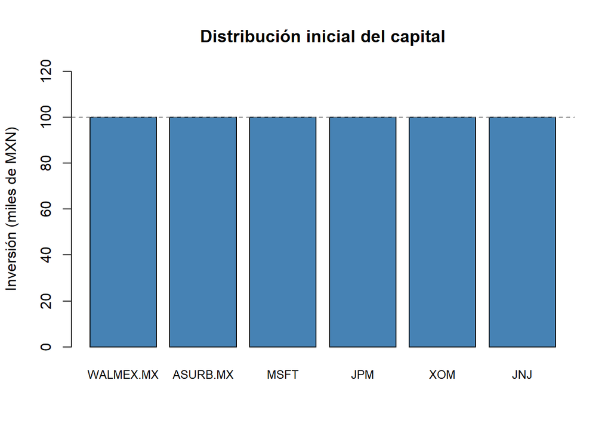

```r
barplot(valor_posicion / 1000, names.arg = clave,
        col = "steelblue", ylim = c(0, 120),
        ylab = "Inversión (miles de MXN)",
        main = "Distribución inicial del capital", cex.names = 0.8)
abline(h = 100, col = "gray45", lty = 2)
```

La distribución equitativa evita concentrar inicialmente el capital en una sola empresa. Sin embargo, tener pesos iguales no implica que todos los activos contribuyan en la misma proporción al riesgo, puesto que sus volatilidades y correlaciones pueden diferir.

### 5.2.5 2.5. Rendimientos individuales

A partir de los precios ajustados en pesos se calculan dos tipos de rendimientos. El rendimiento logarítmico resulta conveniente para trabajar con cambios acumulados en el tiempo:

$$r_{i,t}=\ln\left(\frac{P_{i,t}^{MXN}}{P_{i,t-1}^{MXN}}\right)$$

Por otra parte, el rendimiento simple expresa la variación porcentual de una inversión y permite agregar correctamente los rendimientos de los activos mediante sus ponderaciones:

$$R_{i,t}=\frac{P_{i,t}^{MXN}}{P_{i,t-1}^{MXN}}-1=e^{r_{i,t}}-1$$

```r
rendimientos <- na.omit(diff(log(precios)))
R_hist <- as.matrix(rendimientos)
rownames(R_hist) <- as.character(index(rendimientos))
R_simple <- exp(R_hist) - 1

head(R_hist)
```

```
##               WALMEX.MX      ASURB.MX         MSFT          JPM          XOM
## 2019-01-03 -0.019702269 -0.0153051193 -0.038532080 -0.015363747 -0.016522586
## 2019-01-04  0.018494701  0.0304759716  0.045297065  0.036038326  0.036043113
## 2019-01-07  0.003618051  0.0217672424 -0.010144770 -0.010724199 -0.006233016
## 2019-01-08  0.013551545  0.0237961556  0.006332458 -0.002779512  0.006352731
## 2019-01-09 -0.012749213 -0.0000921565  0.012300069 -0.003589733  0.003362738
## 2019-01-10 -0.019434060  0.0130108179 -0.012778436 -0.006432052 -0.011454292
##                      JNJ
## 2019-01-03 -0.0170681681
## 2019-01-04  0.0164806833
## 2019-01-07 -0.0178547215
## 2019-01-08  0.0220687971
## 2019-01-09 -0.0098551633
## 2019-01-10 -0.0003003513
```

```r
head(R_simple)
```

```
##               WALMEX.MX       ASURB.MX        MSFT          JPM          XOM
## 2019-01-03 -0.019509447 -0.01518859126 -0.03779916 -0.015246326 -0.016386837
## 2019-01-04  0.018666787  0.03094511777  0.04633864  0.036695578  0.036700541
## 2019-01-07  0.003624604  0.02200587713 -0.01009348 -0.010666900 -0.006213631
## 2019-01-08  0.013643783  0.02408154332  0.00635255 -0.002775653  0.006372953
## 2019-01-09 -0.012668286 -0.00009215225  0.01237603 -0.003583298  0.003368398
## 2019-01-10 -0.019246437  0.01309582689 -0.01269714 -0.006411410 -0.011388941
##                      JNJ
## 2019-01-03 -0.0169233321
## 2019-01-04  0.0166172389
## 2019-01-07 -0.0176962704
## 2019-01-08  0.0223141143
## 2019-01-09 -0.0098067603
## 2019-01-10 -0.0003003062
```

Los rendimientos de las empresas estadounidenses incorporan tanto las variaciones de la acción en dólares como los movimientos del tipo de cambio. No se impone normalidad en esta etapa; esa será una hipótesis del modelo paramétrico que deberá justificarse posteriormente.

### 5.2.6 2.6. Rendimientos del portafolio

Para estimar el riesgo de la composición actual, se aplica cada cambio histórico de los activos a los pesos de la fecha de valoración. El rendimiento simple de este portafolio de referencia es:

$$R_{p,t}=\sum_{i=1}^{6}w_iR_{i,t}$$

Este procedimiento mantiene los pesos de referencia constantes al construir cada escenario diario y facilita comparar el riesgo de las mismas posiciones actuales. No representa una estrategia histórica real de compra y mantenimiento. El rendimiento logarítmico equivalente se obtiene a partir del rendimiento simple del portafolio:

$$r_{p,t}=\ln(1+R_{p,t})$$

```r
R_port <- xts(as.numeric(R_simple %*% pesos),
              order.by = index(rendimientos))
colnames(R_port) <- "R_port"
R_port_log <- log(1 + R_port)

head(R_port)
```

```
##                  R_port
## 2019-01-03 -0.020175616
## 2019-01-04  0.030993985
## 2019-01-07 -0.003173301
## 2019-01-08  0.011664882
## 2019-01-09 -0.001734345
## 2019-01-10 -0.006158068
```

```r
head(R_port_log)
```

```
##                  R_port
## 2019-01-03 -0.020381924
## 2019-01-04  0.030523370
## 2019-01-07 -0.003178346
## 2019-01-08  0.011597372
## 2019-01-09 -0.001735851
## 2019-01-10 -0.006177107
```

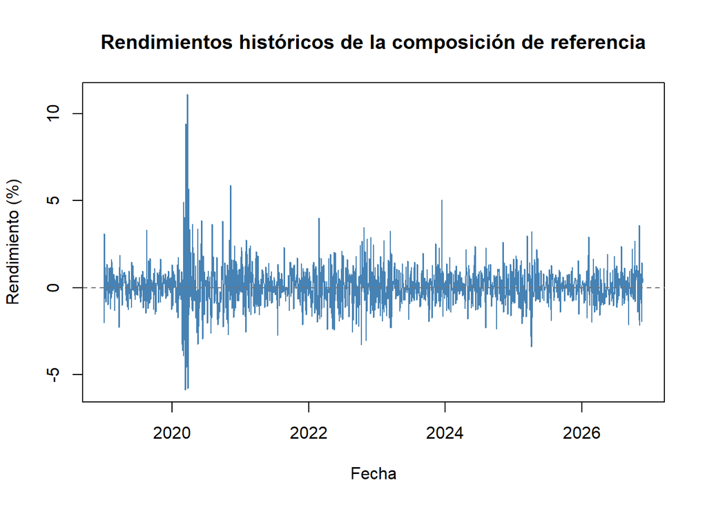

```r
plot(as.Date(index(R_port)), 100 * as.numeric(R_port),
     type = "l", col = "steelblue",
     xlab = "Fecha", ylab = "Rendimiento (%)",
     main = "Rendimientos históricos de la composición de referencia")
abline(h = 0, col = "gray45", lty = 2)
```

La gráfica permite observar la magnitud y la dirección de las variaciones históricas de la cartera de referencia, sin anticipar todavía los resultados del VaR. Los periodos con movimientos pronunciados serán relevantes al estudiar la distribución de pérdidas y ganancias.

### 5.2.7 2.7. Base para las siguientes etapas

Se conservan las siguientes variables para que el equipo pueda utilizar los mismos datos y la misma composición del portafolio en los apartados posteriores.

- `clave`, `precios` y `fecha_val`: activos, cierres ajustados en MXN y fecha de valoración.
- `P0`, `numero` y `pesos`: cierres en MXN, cantidades de acciones y ponderaciones.
- `S0` y `V0`: valor inicial total del portafolio en MXN.
- `R_hist` y `R_simple`: matrices de rendimientos logarítmicos y simples por activo.
- `rendimientos`, `R_port` y `R_port_log`: series de rendimientos individuales y del portafolio con sus fechas.
- `confianza` y `horizontes`: niveles de confianza y horizontes del VaR.

Para la simulación histórica de horizontes superiores a un día, se recomienda acumular los rendimientos logarítmicos de cada activo durante el horizonte y aplicar los cambios acumulados a las cantidades actuales. No se deben acumular sin aclaración los rendimientos diarios de pesos constantes como si correspondieran a posiciones fijas. Para el VaR paramétrico se utilizará la ventana reciente de seis meses indicada en la consigna; para backtesting deberán utilizarse únicamente datos disponibles antes de cada fecha evaluada.

Con esto se establece la composición inicial y la base de rendimientos en una misma moneda. La estimación del VaR, la comparación entre metodologías, el backtesting y la optimización corresponden a los apartados siguientes.

## 5.3 3. VaR no paramétrico (simulación histórica)

### 5.3.1 3.1. Razón de la selección del modelo

La simulación histórica no supone ninguna distribución para los rendimientos: utiliza directamente los cambios observados en el mercado desde 2019. Por ello conserva las colas pesadas, la asimetría y las correlaciones reales entre los seis activos y el tipo de cambio. Se utiliza toda la información disponible, como lo indica la consigna, y como referencia el valor actual del portafolio $S_0$.

### 5.3.2 3.2. Escenarios de precios y función de pérdidas y ganancias a un día

Cada rendimiento logarítmico histórico se aplica a los precios actuales en MXN, con lo que se obtiene un posible precio para el día siguiente:

$$S_{i}^{(k)}=P_{i,0}\,e^{r_{i,k}}$$

El valor del portafolio en cada escenario se obtiene con las cantidades de acciones actuales y la pérdida o ganancia se mide contra $S_0$:

$$V^{(k)}=\sum_{i=1}^{6}n_iS_{i}^{(k)},
\qquad PyG^{(k)}=V^{(k)}-S_0$$

```r
S_hist <- sweep(exp(R_hist), 2, P0, "*")
V_hist <- as.numeric(S_hist %*% numero)
PL_hist <- V_hist - V0

summary(PL_hist)
```

```
##     Min.  1st Qu.   Median     Mean  3rd Qu.     Max.
## -35282.5  -2895.4    386.9    475.0   3794.4  66630.6
```

El VaR corresponde al cuantil $1-c$ de la función de pérdidas y ganancias. Se reporta con signo negativo porque representa una pérdida.

```r
VaR_SH_1d <- quantile(PL_hist, probs = 1 - confianza)
VaR_SH_1d
```

```
##         5%       2.5%         1%
##  -9337.663 -12118.064 -16683.708
```

```r
VaR_SH_1d / V0 * 100
```

```
##        5%      2.5%        1%
## -1.556277 -2.019677 -2.780618
```

Con la información histórica, la pérdida del portafolio en un día no debería superar 9,338 MXN (1.56% de $S_0$) con 95% de confianza, 12,118 MXN (2.02%) con 97.5% y 16,684 MXN (2.78%) con 99%. La peor pérdida de la muestra fue de 35,282 MXN, el 2020-03-12, durante la caída de los mercados por el COVID-19; esto muestra que la cola izquierda contiene eventos mucho más severos que el VaR.

### 5.3.3 3.3. Gráfica e interpretación de la distribución de pérdidas y ganancias

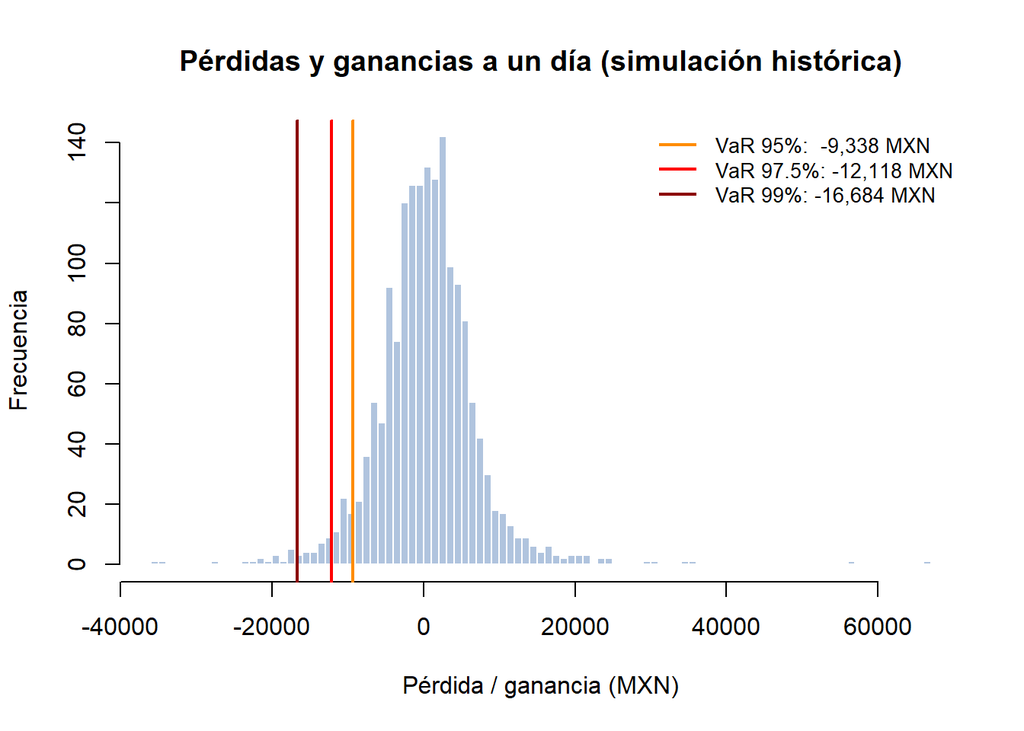

```r
hist(PL_hist, n = 100, col = "lightsteelblue", border = "white",
     main = "Pérdidas y ganancias a un día (simulación histórica)",
     xlab = "Pérdida / ganancia (MXN)", ylab = "Frecuencia")
abline(v = VaR_SH_1d, col = c("darkorange", "red", "darkred"), lwd = 2)
legend("topright", legend = paste0("VaR ", confianza * 100, "%: ",
                                  format(round(VaR_SH_1d), big.mark = ","), " MXN"),
       col = c("darkorange", "red", "darkred"), lwd = 2, bty = "n", cex = 0.85)
```

El histograma muestra la distribución empírica de las variaciones diarias simuladas del portafolio alrededor de cero, con una marcada concentración en días de movimientos moderados y colas alargadas hacia ambos extremos. Las tres líneas verticales en la cola izquierda delimitan los umbrales críticos de pérdida diaria: la línea naranja (95%, -9,338 MXN) deja a su izquierda al 5% de los peores escenarios históricos; la línea roja (97.5%, -12,118 MXN) acota el 2.5% más desfavorable; y la línea roja oscura (99%, -16,684 MXN) marca el umbral que solo es rebasado en el 1% de las jornadas más adversas. Asimismo, se observa que las barras situadas a la izquierda del VaR al 99% se extienden hasta -35,282 MXN, evidenciando el peso de los choques extremos no gaussianos.

### 5.3.4 3.4. VaR para horizontes de 1, 5, 10 y 20 días

Para horizontes mayores a un día no se escala el VaR diario. Se suman los rendimientos logarítmicos de cada activo en $h$ días consecutivos (ventanas móviles) y el rendimiento acumulado se aplica a los precios actuales:

$$r_{i,k}^{(h)}=\sum_{j=0}^{h-1}r_{i,k+j},
\qquad S_{i}^{(k,h)}=P_{i,0}\,e^{r_{i,k}^{(h)}}$$

De esta forma, el VaR de cada horizonte se obtiene de cambios realmente observados en $h$ días.

```r
VaR_SH <- matrix(NA, nrow = length(horizontes), ncol = length(confianza))
rownames(VaR_SH) <- paste(horizontes, "días")
colnames(VaR_SH) <- paste0(confianza * 100, "%")

for (j in 1:length(horizontes)) {
  h <- horizontes[j]
  R_h <- rollapply(R_hist, width = h, FUN = sum)
  S_h <- sweep(exp(R_h), 2, P0, "*")
  PL_h <- as.numeric(S_h %*% numero) - V0
  VaR_SH[j, ] <- quantile(PL_h, probs = 1 - confianza)
}

# VaR en MXN
VaR_SH
```

```
##                95%     97.5%       99%
## 1 días   -9337.663 -12118.06 -16683.71
## 5 días  -16547.799 -20566.41 -30243.43
## 10 días -20614.979 -28749.08 -43136.22
## 20 días -22911.978 -32189.54 -49099.22
```

```r
# VaR como % del valor del portafolio
VaR_SH / V0 * 100
```

```
##               95%     97.5%       99%
## 1 días  -1.556277 -2.019677 -2.780618
## 5 días  -2.757967 -3.427736 -5.040572
## 10 días -3.435830 -4.791514 -7.189370
## 20 días -3.818663 -5.364923 -8.183204
```

El VaR aumenta con el horizonte, pero menos que proporcionalmente a $\sqrt{h}$: al 99%, el VaR a 20 días es 2.94 veces el diario, mientras que $\sqrt{20}\approx4.47$. Esto ocurre porque las pérdidas extremas de días aislados no siempre se acumulan en periodos más largos y porque las ventanas de varios días se traslapan, por lo que hay menos escenarios independientes.

## 5.4 4. VaR paramétrico

### 5.4.1 4.1. Razón de la selección del modelo

El VaR paramétrico supone que los rendimientos siguen una distribución normal con media cero, de modo que la pérdida del portafolio queda determinada por su volatilidad. Para que la volatilidad refleje las condiciones recientes del mercado, se estima con los rendimientos diarios de los últimos seis meses y se incorpora la dependencia entre activos mediante la matriz de covarianzas:

$$VaR_{p,c}=Z_c\,S_0\,\sigma_p, \qquad
\sigma_p=\sqrt{W^T\Sigma W}$$

### 5.4.2 4.2. Volatilidad, correlación y matriz de covarianzas de los últimos seis meses

```r
R_6m <- last(rendimientos, "6 months")
nrow(R_6m)
```

```
## [1] 101
```

```r
# Volatilidad diaria de cada activo
vol_6m <- apply(R_6m, 2, sd)
vol_6m
```

```
##  WALMEX.MX   ASURB.MX       MSFT        JPM        XOM        JNJ
## 0.01468408 0.01810666 0.02692747 0.01593305 0.02106043 0.01976566
```

```r
# Matriz de varianzas y covarianzas
C <- cov(R_6m)
C
```

```
##                WALMEX.MX       ASURB.MX           MSFT            JPM
## WALMEX.MX 0.000215622222  0.00005455179 0.000071170547 0.000003755809
## ASURB.MX  0.000054551793  0.00032785130 0.000063698650 0.000023217699
## MSFT      0.000071170547  0.00006369865 0.000725088446 0.000116712323
## JPM       0.000003755809  0.00002321770 0.000116712323 0.000253862139
## XOM       0.000006558898 -0.00010309585 0.000013606394 0.000038773884
## JNJ       0.000034925089 -0.00004378108 0.000007228465 0.000119819599
##                       XOM             JNJ
## WALMEX.MX  0.000006558898  0.000034925089
## ASURB.MX  -0.000103095847 -0.000043781084
## MSFT       0.000013606394  0.000007228465
## JPM        0.000038773884  0.000119819599
## XOM        0.000443541562  0.000117525866
## JNJ        0.000117525866  0.000390681201
```

```r
# Matriz de correlaciones
Corr_6m <- cor(R_6m)
round(Corr_6m, 3)
```

```
##           WALMEX.MX ASURB.MX  MSFT   JPM    XOM    JNJ
## WALMEX.MX     1.000    0.205 0.180 0.016  0.021  0.120
## ASURB.MX      0.205    1.000 0.131 0.080 -0.270 -0.122
## MSFT          0.180    0.131 1.000 0.272  0.024  0.014
## JPM           0.016    0.080 0.272 1.000  0.116  0.380
## XOM           0.021   -0.270 0.024 0.116  1.000  0.282
## JNJ           0.120   -0.122 0.014 0.380  0.282  1.000
```

La ventana contiene 101 observaciones comunes entre el 2026-06-01 y el 2026-11-23. MSFT es el activo con mayor volatilidad diaria (2.69%) y WALMEX.MX el de menor (1.47%). La matriz de correlaciones muestra relaciones lineales imperfectas entre los activos (con pares en un rango de -0.27 a 0.38), lo cual permite que los movimientos de unas emisoras compensen parcialmente a las otras dentro del cálculo de $\Sigma$.

### 5.4.3 4.3. Volatilidad del portafolio y VaR a un día

Se utilizan los pesos de la composición actual, calculados con $S_0$.

```r
Z <- qnorm(1 - confianza)
Z
```

```
## [1] -1.644854 -1.959964 -2.326348
```

```r
sigma_p <- as.numeric(sqrt(t(pesos) %*% C %*% pesos))
sigma_p
```

```
## [1] 0.0097268
```

```r
VaR_P_1d <- Z * V0 * sigma_p
names(VaR_P_1d) <- paste0(confianza * 100, "%")
VaR_P_1d
```

```
##        95%      97.5%        99%
##  -9599.497 -11438.507 -13576.752
```

```r
VaR_P_1d / V0 * 100
```

```
##       95%     97.5%       99%
## -1.599916 -1.906418 -2.262792
```

La volatilidad diaria del portafolio es de 0.97%, menor que la de cualquiera de los activos por separado, debido al efecto de la diversificación. Con 99% de confianza, la pérdida en un día no debería superar 13,577 MXN (2.26% de $S_0$).

### 5.4.4 4.4. Escalación temporal del VaR

Si los rendimientos diarios son independientes, tienen la misma distribución y media cero, la varianza del rendimiento acumulado en $h$ días es la suma de las $h$ varianzas diarias:

$$\sigma_h^2=h\,\sigma_p^2
\quad\Rightarrow\quad \sigma_h=\sigma_p\sqrt{h}$$

Por lo tanto, el VaR a $h$ días se obtiene multiplicando el VaR diario por la raíz cuadrada del horizonte:

$$VaR_{h,c}=Z_c\,S_0\,\sigma_p\sqrt{h}=VaR_{1,c}\sqrt{h}$$

Por ejemplo, el VaR a 5 días es $\sqrt{5}\approx2.24$ veces el VaR diario y el de 20 días es $\sqrt{20}\approx4.47$ veces. Esta regla depende del supuesto de independencia: si la volatilidad se agrupa en el tiempo, el riesgo a varios días puede ser distinto al obtenido con $\sqrt{h}$.

```r
VaR_P <- matrix(NA, nrow = length(horizontes), ncol = length(confianza))
rownames(VaR_P) <- paste(horizontes, "días")
colnames(VaR_P) <- paste0(confianza * 100, "%")

for (j in 1:length(horizontes)) {
  VaR_P[j, ] <- Z * V0 * sigma_p * sqrt(horizontes[j])
}

# VaR en MXN
VaR_P
```

```
##                95%     97.5%       99%
## 1 días   -9599.497 -11438.51 -13576.75
## 5 días  -21465.129 -25577.28 -30358.54
## 10 días -30356.276 -36171.73 -42933.46
## 20 días -42930.258 -51154.56 -60717.08
```

```r
# VaR como % del valor del portafolio
VaR_P / V0 * 100
```

```
##               95%     97.5%        99%
## 1 días  -1.599916 -1.906418  -2.262792
## 5 días  -3.577521 -4.262880  -5.059757
## 10 días -5.059379 -6.028622  -7.155577
## 20 días -7.155043 -8.525760 -10.119514
```

Por la regla de $\sqrt{h}$, al 99% el VaR pasa de 13,577 MXN a un día a 60,717 MXN a 20 días (10.12% del portafolio).

### 5.4.5 4.5. Comparación entre metodologías

```r
comparacion_modelos <- data.frame(
  Horizonte = rep(paste(horizontes, "días"), times = length(confianza)),
  Confianza = rep(paste0(confianza * 100, "%"), each = length(horizontes)),
  VaR_SH_MXN = round(as.vector(VaR_SH), 2),
  VaR_Param_MXN = round(as.vector(VaR_P), 2),
  Diferencia_MXN = round(as.vector(VaR_SH - VaR_P), 2),
  Ratio_SH_Param = round(as.vector(VaR_SH / VaR_P), 2),
  row.names = NULL
)

comparacion_modelos
```

| Horizonte | Confianza | VaR_SH_MXN | VaR_Param_MXN | Diferencia_MXN | Ratio_SH_Param |
| --- | --- | --- | --- | --- | --- |
| 1 días | 95% | -9337.66 | -9599.50 | 261.83 | 0.97 |
| 5 días | 95% | -16547.80 | -21465.13 | 4917.33 | 0.77 |
| 10 días | 95% | -20614.98 | -30356.28 | 9741.30 | 0.68 |
| 20 días | 95% | -22911.98 | -42930.26 | 20018.28 | 0.53 |
| 1 días | 97.5% | -12118.06 | -11438.51 | -679.56 | 1.06 |
| 5 días | 97.5% | -20566.41 | -25577.28 | 5010.87 | 0.80 |
| 10 días | 97.5% | -28749.08 | -36171.73 | 7422.65 | 0.79 |
| 20 días | 97.5% | -32189.54 | -51154.56 | 18965.02 | 0.63 |
| 1 días | 99% | -16683.71 | -13576.75 | -3106.96 | 1.23 |
| 5 días | 99% | -30243.43 | -30358.54 | 115.11 | 1.00 |

[output cut: 2 more lines]

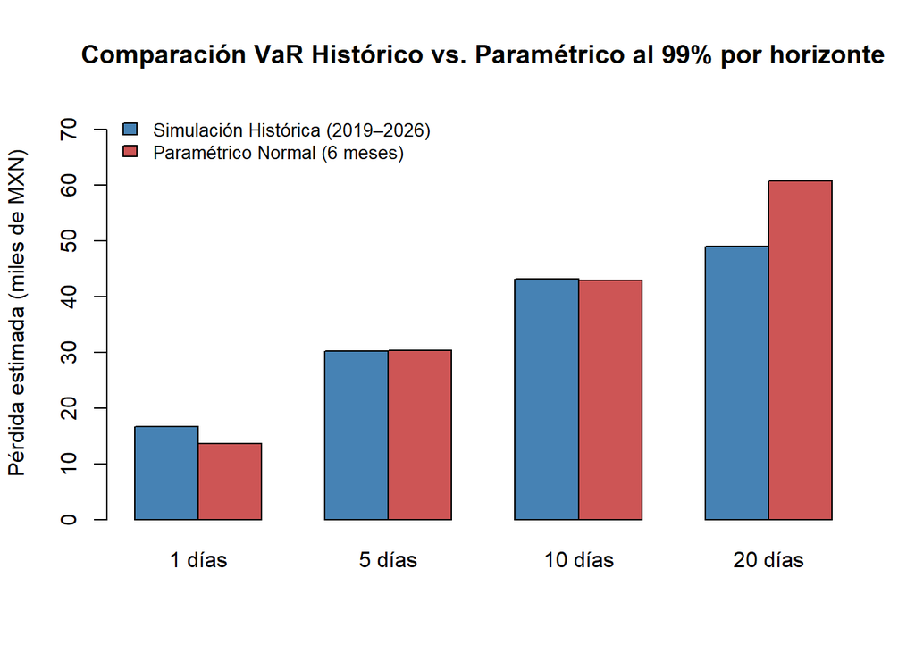

```r
barplot(rbind(-VaR_SH[, "99%"] / 1000, -VaR_P[, "99%"] / 1000),
        beside = TRUE, names.arg = paste(horizontes, "días"),
        col = c("steelblue", "indianred3"),
        ylim = c(0, max(c(-VaR_SH[, "99%"], -VaR_P[, "99%"])) / 1000 * 1.22),
        ylab = "Pérdida estimada (miles de MXN)",
        main = "Comparación VaR Histórico vs. Paramétrico al 99% por horizonte")
legend("topleft",
       legend = c("Simulación Histórica (2019–2026)", "Paramétrico Normal (6 meses)"),
       fill = c("steelblue", "indianred3"), bty = "n", cex = 0.85)
```

## 5.5 5. Backtesting

### 5.5.1 5.1. Metodología y criterios de evaluación

El backtesting contrasta las estimaciones diarias del VaR contra las pérdidas y ganancias efectivamente observadas en el mercado. Para evitar el uso de información futura (*look-ahead bias*), en cada fecha evaluada $t$ se estima el VaR a un día utilizando únicamente información disponible hasta $t-1$:

- Simulación histórica: Emplea todos los rendimientos diarios acumulados desde el inicio de la muestra hasta $t-1$, aplicados a las cantidades actuales (`numero`) y precios (`P0`) sobre el valor inicial $V_0$.
- VaR paramétrico: Recalcula en cada fecha $t$ la matriz de covarianzas $\Sigma_{t-1}$ con las últimas 101 observaciones disponibles hasta $t-1$ y obtiene $\sigma_{p,t-1}=\sqrt{W^T\Sigma_{t-1}W}$.

Dado que el VaR se reporta con signo negativo para representar pérdidas, ocurre una violación (o excepción) en el día $t$ cuando la pérdida realizada supera la pérdida máxima estimada por el modelo:

$$PyG_t < VaR_{t,c}$$

Para un periodo de evaluación de $T_{eval}$ sesiones y un nivel de confianza $c$, la tasa teórica de excepciones es $\alpha = 1 - c$, por lo que el número esperado de violaciones es $E[x] = T_{eval}(1-c)$. Para evaluar formalmente la calibración de cada metodología se aplica la prueba de cobertura incondicional de Kupiec (POF), cuyo estadístico de razón de verosimilitud contrasta si la proporción observada de fallos $\hat{p} = x / T_{eval}$ es estadísticamente consistente con $\alpha$:

$$LR_{POF} = -2 \ln \left[
\frac{(1-\alpha)^{T_{eval}-x}\,\alpha^{x}}{(1-\hat{p})^{T_{eval}-x}\,\hat{p}^{x}}
\right] \sim \chi^2_1$$

Con un nivel de significancia del 5%, el valor crítico es $\chi^2_{1,0.95} \approx 3.841$; valores de $p$-valor superiores a $0.05$ indican que no se rechaza la hipótesis de correcta calibración del modelo.

### 5.5.2 5.2. Estimación dinámica del VaR a un día y conteo de violaciones

Se fija un periodo inicial de calibración de $W_{ini} = 252$ observaciones para que la simulación histórica cuente con datos.

```r
W_6m <- nrow(R_6m)
W_ini <- 252
n_total <- nrow(R_hist)
idx_eval <- (W_ini + 1):n_total
n_eval <- length(idx_eval)
fechas_eval <- as.Date(rownames(R_hist)[idx_eval])

PyG_real <- as.numeric(R_port[idx_eval]) * V0

VaR_bt_SH <- matrix(NA, nrow = n_eval, ncol = length(confianza))
VaR_bt_P  <- matrix(NA, nrow = n_eval, ncol = length(confianza))
colnames(VaR_bt_SH) <- paste0(confianza * 100, "%")
colnames(VaR_bt_P)  <- paste0(confianza * 100, "%")

for (k in 1:length(idx_eval)) {
  t_idx <- idx_eval[k]

  R_disp_SH <- R_hist[1:(t_idx - 1), , drop = FALSE]
  S_esc_SH <- sweep(exp(R_disp_SH), 2, P0, "*")
  PyG_esc_SH <- as.numeric(S_esc_SH %*% numero) - V0
  VaR_bt_SH[k, ] <- quantile(PyG_esc_SH, probs = 1 - confianza)

  R_disp_P <- R_hist[(t_idx - W_6m):(t_idx - 1), , drop = FALSE]
  C_t <- cov(R_disp_P)
  sigma_t <- as.numeric(sqrt(t(pesos) %*% C_t %*% pesos))
  VaR_bt_P[k, ] <- Z * V0 * sigma_t
}

viol_SH <- apply(VaR_bt_SH, 2, function(v) PyG_real < v)
viol_P  <- apply(VaR_bt_P,  2, function(v) PyG_real < v)

obs_SH <- colSums(viol_SH)
obs_P  <- colSums(viol_P)
esperadas <- n_eval * (1 - confianza)
```

### 5.5.3 5.3. Prueba de cobertura incondicional de Kupiec y comparación visual

```r
prueba_kupiec <- function(x, n, alpha) {
  p_hat <- x / n
  if (x == 0 || x == n) {
    lr <- -2 * (n * log(1 - alpha))
  } else {
    log_l0 <- (n - x) * log(1 - alpha) + x * log(alpha)
    log_l1 <- (n - x) * log(1 - p_hat) + x * log(p_hat)
    lr <- -2 * (log_l0 - log_l1)
  }
  p_val <- 1 - pchisq(lr, df = 1)
  c(LR_POF = lr, p_valor = p_val)
}

kupiec_SH <- t(mapply(prueba_kupiec, x = obs_SH, n = n_eval, alpha = 1 - confianza))
kupiec_P  <- t(mapply(prueba_kupiec, x = obs_P,  n = n_eval, alpha = 1 - confianza))

resumen_bt <- data.frame(
  Modelo = rep(c("Simulación Histórica", "Paramétrico Normal"), each = length(confianza)),
  Confianza = rep(paste0(confianza * 100, "%"), times = 2),
  Dias_Eval = n_eval,
  Esperadas = rep(round(esperadas, 1), times = 2),
  Observadas = c(obs_SH, obs_P),
  Tasa_Obs_Pct = round(c(obs_SH, obs_P) / n_eval * 100, 2),
  Ratio_Obs_Esp = round(c(obs_SH, obs_P) / rep(esperadas, times = 2), 2),
  LR_Kupiec = round(c(kupiec_SH[, "LR_POF"], kupiec_P[, "LR_POF"]), 3),
  p_valor = round(c(kupiec_SH[, "p_valor"], kupiec_P[, "p_valor"]), 4),
  row.names = NULL
)

resumen_bt
```

| Modelo | Confianza | Dias_Eval | Esperadas | Observadas | Tasa_Obs_Pct | Ratio_Obs_Esp | LR_Kupiec | p_valor |
| --- | --- | --- | --- | --- | --- | --- | --- | --- |
| Simulación Histórica | 95% | 1445 | 72.3 | 59 | 4.08 | 0.82 | 2.721 | 0.0990 |
| Simulación Histórica | 97.5% | 1445 | 36.1 | 18 | 1.25 | 0.50 | 11.404 | 0.0007 |
| Simulación Histórica | 99% | 1445 | 14.5 | 8 | 0.55 | 0.55 | 3.469 | 0.0625 |
| Paramétrico Normal | 95% | 1445 | 72.3 | 65 | 4.50 | 0.90 | 0.791 | 0.3737 |
| Paramétrico Normal | 97.5% | 1445 | 36.1 | 40 | 2.77 | 1.11 | 0.412 | 0.5208 |
| Paramétrico Normal | 99% | 1445 | 14.5 | 25 | 1.73 | 1.73 | 6.387 | 0.0115 |

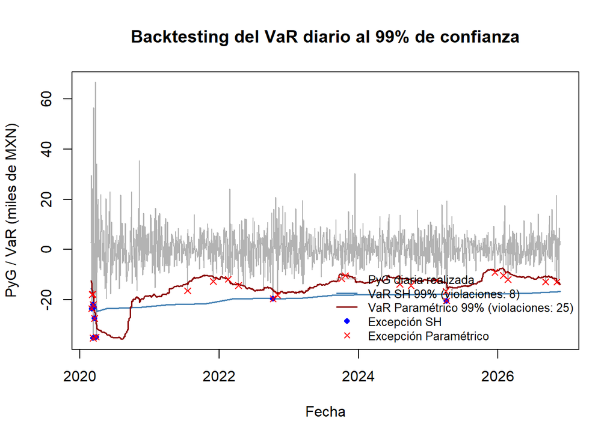

```r
rango_y <- range(c(PyG_real, VaR_bt_SH[, "99%"], VaR_bt_P[, "99%"])) / 1000
plot(fechas_eval, PyG_real / 1000, type = "l", col = "gray70",
     ylim = rango_y, xlab = "Fecha", ylab = "PyG / VaR (miles de MXN)",
     main = "Backtesting del VaR diario al 99% de confianza")
lines(fechas_eval, VaR_bt_SH[, "99%"] / 1000, col = "steelblue", lwd = 1.8)
lines(fechas_eval, VaR_bt_P[, "99%"] / 1000, col = "darkred", lwd = 1.6)

idx_v_sh <- which(viol_SH[, "99%"])
idx_v_p  <- which(viol_P[, "99%"])
points(fechas_eval[idx_v_sh], PyG_real[idx_v_sh] / 1000, pch = 16, col = "blue", cex = 0.85)
points(fechas_eval[idx_v_p],  PyG_real[idx_v_p] / 1000,  pch = 4,  col = "red",  cex = 0.95)

legend("bottomright",
       legend = c("PyG diaria realizada",
                  paste0("VaR SH 99% (violaciones: ", obs_SH[3], ")"),
                  paste0("VaR Paramétrico 99% (violaciones: ", obs_P[3], ")"),
                  "Excepción SH", "Excepción Paramétrico"),
       col = c("gray70", "steelblue", "darkred", "blue", "red"),
       lty = c(1, 1, 1, NA, NA), pch = c(NA, NA, NA, 16, 4),
       lwd = c(1, 1.8, 1.6, NA, NA), bty = "n", cex = 0.8)
```

### 5.5.4 5.4. Evaluación crítica del desempeño de los modelos

En el periodo fuera de muestra compuesto por 1,445 sesiones (del 2020-02-28 al 2026-11-23), el número teórico de excepciones es de 72.3 al 95%, 36.1 al 97.5% y 14.5 al 99%.

La gráfica del VaR al 99% permite visualizar la diferencia estructural entre ambas metodologías: la línea azul presenta un comportamiento escalonado y relativamente estable porque acumula toda la muestra histórica previa, mientras que la línea roja oscila continuamente conforme entra y sale volatilidad en su ventana móvil de seis meses.

- Simulación histórica: registró 59, 18 y 8 violaciones al 95%, 97.5% y 99%, respectivamente (ratios observado/esperado de 0.82, 0.50 y 0.55). Al no imponer normalidad, captura de forma más fiel las colas pesadas y los saltos cambiarios una vez que los episodios de estrés forman parte de la muestra; su principal limitación es la lentitud para reaccionar cuando comienza un choque repentino o cuando se disipa un periodo de alta volatilidad. Además, al 97.5% tuvo menos violaciones de las esperadas y la prueba de Kupiec rechaza su calibración (p-valor = 0.0007): en ese nivel resulta demasiado prudente.
- VaR paramétrico: registró 65, 40 y 25 violaciones para los mismos niveles de confianza (ratios de 0.90, 1.11 y 1.73). Gracias a la ventana móvil de seis meses, su umbral se ajusta con mayor rapidez cuando aumenta o disminuye la volatilidad reciente; sin embargo, al asumir rendimientos normales con colas delgadas, subestima la frecuencia de las pérdidas extremas en los niveles altos de confianza (ratios de 1.11 al 97.5% y 1.73 al 99%). La prueba de Kupiec rechaza su calibración al 99% (p-valor = 0.0115) y no rechaza la del 97.5% (p-valor = 0.5208).

Desde una perspectiva prudencial de administración de riesgos, la simulación histórica ofrece un desempeño superior en la cola extrema (99%), donde la subestimación del riesgo resulta más costosa, mientras que el modelo paramétrico funciona mejor como indicador dinámico en niveles moderados (95%).

## 5.6 6. Optimización del portafolio

### 5.6.1 6.1. Formulación del problema de mínimo VaR

Bajo el enfoque paramétrico desarrollado en la sección 4, el VaR del portafolio para un nivel de confianza $c$ y un capital inicial $S_0$ está dado por:

$$VaR_{p,c} = Z_c \, S_0 \, \sigma_p,
\qquad \sigma_p = \sqrt{W^T \Sigma W}$$

Dado que $Z_c$ y $S_0$ son constantes para un nivel de confianza dado, minimizar la pérdida asociada al VaR equivale directamente a minimizar la volatilidad del portafolio $\sigma_p$ (o su varianza $W^T\Sigma W$). Conservando las restricciones operativas del portafolio inicial (inversión total del 100% del capital, sin apalancamiento ni ventas en corto), se plantea el siguiente problema de programación cuadrática:

$$\min_{W} \; W^T \Sigma W \quad
\text{sujeto a} \quad \sum_{i=1}^{6} w_i = 1, \qquad w_i \ge 0 \;\;
\forall i \in \{1,\dots,6\}$$

donde $\Sigma$ corresponde a la matriz de varianzas y covarianzas de los últimos seis meses (`C`).

### 5.6.2 6.2. Cálculo de los pesos óptimos y comparación con el portafolio inicial

```r
library(quadprog)

n_act <- length(clave)
Dmat <- 2 * C
dvec <- rep(0, n_act)
Amat <- cbind(rep(1, n_act), diag(n_act))
bvec <- c(1, rep(0, n_act))

sol_opt <- solve.QP(Dmat = Dmat, dvec = dvec, Amat = Amat, bvec = bvec, meq = 1)

pesos_opt <- sol_opt$solution
pesos_opt[abs(pesos_opt) < 1e-10] <- 0
pesos_opt <- pesos_opt / sum(pesos_opt)
names(pesos_opt) <- clave

stopifnot(abs(sum(pesos_opt) - 1) < 1e-10, all(pesos_opt >= 0))

inversion_opt <- pesos_opt * V0
acciones_opt  <- inversion_opt / P0

comparacion_pesos <- data.frame(
  Empresa = empresas,
  Activo = clave,
  Vol_6m_Pct = round(vol_6m * 100, 2),
  Peso_Inicial_Pct = round(pesos * 100, 2),
  Peso_Optimo_Pct = round(pesos_opt * 100, 2),
  Cambio_Peso_Pct = round((pesos_opt - pesos) * 100, 2),
  Inversion_Opt_MXN = round(inversion_opt, 2),
  Acciones_Opt = round(acciones_opt, 4),
  row.names = NULL
)

comparacion_pesos
```

| Empresa | Activo | Vol_6m_Pct | Peso_Inicial_Pct | Peso_Optimo_Pct | Cambio_Peso_Pct | Inversion_Opt_MXN | Acciones_Opt |
| --- | --- | --- | --- | --- | --- | --- | --- |
| Walmart de México | WALMEX.MX | 1.47 | 16.67 | 26.65 | 9.98 | 159906.57 | 2921.2014 |
| ASUR | ASURB.MX | 1.81 | 16.67 | 24.20 | 7.54 | 145220.81 | 273.7381 |
| Microsoft | MSFT | 2.69 | 16.67 | 2.25 | -14.42 | 13489.88 | 1.4358 |
| JPMorgan Chase | JPM | 1.59 | 16.67 | 19.98 | 3.32 | 119895.53 | 19.8479 |
| ExxonMobil | XOM | 2.11 | 16.67 | 18.61 | 1.94 | 111640.50 | 37.2995 |
| Johnson & Johnson | JNJ | 1.98 | 16.67 | 8.31 | -8.36 | 49846.71 | 9.6760 |

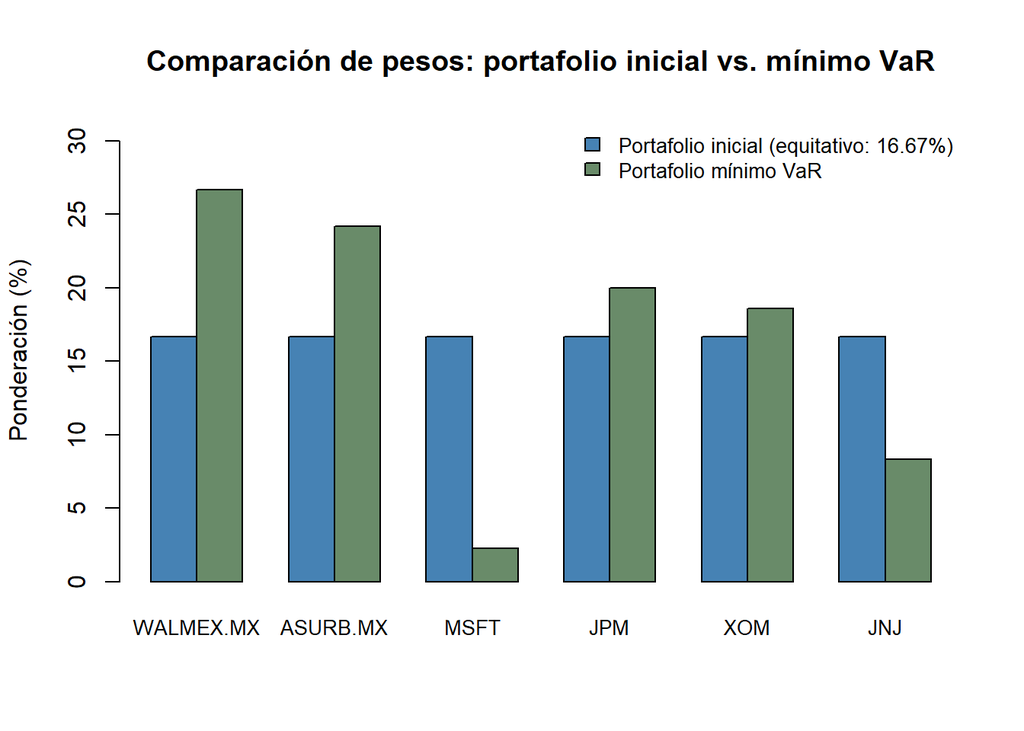

```r
barplot(rbind(pesos * 100, pesos_opt * 100),
        beside = TRUE, names.arg = clave,
        col = c("steelblue", "darkseagreen4"),
        ylim = c(0, max(c(pesos, pesos_opt)) * 118),
        ylab = "Ponderación (%)",
        main = "Comparación de pesos: portafolio inicial vs. mínimo VaR",
        cex.names = 0.85)
legend("topright",
       legend = c("Portafolio inicial (equitativo: 16.67%)", "Portafolio mínimo VaR"),
       fill = c("steelblue", "darkseagreen4"), bty = "n", cex = 0.85)
```

### 5.6.3 6.3. Análisis de cambios en riesgo y diversificación

```r
sigma_opt <- as.numeric(sqrt(t(pesos_opt) %*% C %*% pesos_opt))
VaR_P_opt_1d <- Z * V0 * sigma_opt
names(VaR_P_opt_1d) <- paste0(confianza * 100, "%")

VaR_P_opt <- matrix(NA, nrow = length(horizontes), ncol = length(confianza))
rownames(VaR_P_opt) <- paste(horizontes, "días")
colnames(VaR_P_opt) <- paste0(confianza * 100, "%")
for (j in 1:length(horizontes)) {
  VaR_P_opt[j, ] <- Z * V0 * sigma_opt * sqrt(horizontes[j])
}

PL_hist_opt <- as.numeric(S_hist %*% acciones_opt) - V0
VaR_SH_opt_1d <- quantile(PL_hist_opt, probs = 1 - confianza)

HHI_ini <- sum(pesos^2)
HHI_opt <- sum(pesos_opt^2)

DR_ini <- sum(pesos * vol_6m) / sigma_p
DR_opt <- sum(pesos_opt * vol_6m) / sigma_opt

resumen_opt <- data.frame(
  Metrica = c("Volatilidad diaria (%)",
              "VaR Paramétrico 1d 95% (MXN)",
              "VaR Paramétrico 1d 97.5% (MXN)",
              "VaR Paramétrico 1d 99% (MXN)",
              "VaR Histórico 1d 99% (MXN)",
              "Índice Herfindahl (HHI)",
              "Ratio de Diversificación (DR)"),
  Inicial = round(c(sigma_p * 100, -VaR_P_1d, -VaR_SH_1d[3], HHI_ini, DR_ini), 3),
  Optimo  = round(c(sigma_opt * 100, -VaR_P_opt_1d, -VaR_SH_opt_1d[3], HHI_opt, DR_opt), 3),
  Variacion_Pct = round(c((sigma_opt / sigma_p - 1) * 100,
                          (VaR_P_opt_1d / VaR_P_1d - 1) * 100,
                          (VaR_SH_opt_1d[3] / VaR_SH_1d[3] - 1) * 100,
                          (HHI_opt / HHI_ini - 1) * 100,
                          (DR_opt / DR_ini - 1) * 100), 2)
)

resumen_opt
```

| Metrica | Inicial | Optimo | Variacion_Pct |
| --- | --- | --- | --- |
| Volatilidad diaria (%) | 0.973 | 0.878 | -9.70 |
| VaR Paramétrico 1d 95% (MXN) | 9599.497 | 8668.081 | -9.70 |
| VaR Paramétrico 1d 97.5% (MXN) | 11438.507 | 10328.656 | -9.70 |
| VaR Paramétrico 1d 99% (MXN) | 13576.752 | 12259.433 | -9.70 |
| VaR Histórico 1d 99% (MXN) | 16683.708 | 16980.185 | 1.78 |
| Índice Herfindahl (HHI) | 0.167 | 0.212 | 26.94 |
| Ratio de Diversificación (DR) | 1.996 | 2.009 | 0.67 |

Al contrastar la composición óptima frente al portafolio equitativo inicial, se identifican tres efectos fundamentales sobre el riesgo y la diversificación:

- Reducción sustancial del VaR y la volatilidad paramétrica: la volatilidad diaria del portafolio cae de 0.97% a 0.88%, lo que reduce el VaR paramétrico en 9.70% en todos los niveles de confianza y horizontes. Al 99% a un día, la pérdida máxima esperada disminuye de 13,577 MXN a 12,259 MXN. No obstante, al evaluar esta misma composición bajo simulación histórica (2019–2026), el VaR al 99% pasa de 16,684 MXN a 16,980 MXN (+1.77%), lo que muestra que minimizar la varianza con datos recientes de seis meses no garantiza una reducción simultánea en escenarios extremos de crisis pasadas.
- Reasignación hacia activos defensivos y baja covarianza: el algoritmo penaliza las acciones con mayor volatilidad en pesos mexicanos —como Microsoft (`MSFT`, cuya ponderación baja de 16.67% a 2.25%) y Johnson & Johnson (`JNJ`, que baja a 8.31%)— y concentra el capital en los títulos con menor volatilidad reciente en MXN y baja correlación cruzada, principalmente Walmart de México (`WALMEX.MX`, 26.65%), ASUR (`ASURB.MX`, 24.20%), JPMorgan Chase (`JPM`, 19.98%) y ExxonMobil (`XOM`, 18.61%).
- Tensión entre concentración nominal y diversificación de riesgo: al pasar de pesos iguales (16.67%) a pesos óptimos, el índice de concentración de capital (HHI) aumenta de 0.1667 a 0.2116. Aunque el portafolio se vuelve más concentrado en términos de asignación monetaria, aprovecha de manera más eficiente las correlaciones cruzadas entre sectores y monedas para abatir la varianza total, elevando ligeramente el ratio de diversificación ($DR = \sum w_i\sigma_i / \sigma_p$) de 2.00 a 2.01.

## 5.7 7. VaR individual y Expected Shortfall de WALMEX

### 5.7.1 7.1. Razón de la selección del modelo

Para la posición individual (100,000 MXN en WALMEX) usamos simulación de Montecarlo con remuestreo de los rendimientos históricos. Elegimos esta versión porque la consigna pide una metodología no paramétrica: no suponemos ninguna distribución, solo generamos 100,000 escenarios de rendimiento diario tomando al azar, con reemplazo, rendimientos reales de WALMEX. Usamos la misma serie de las Partes 2 a 4: precios ajustados de WALMEX.MX descargados de Yahoo Finance desde el 2 de enero de 2003, sin los días festivos con volumen cero y con rendimientos logarítmicos. Así se conservan las colas pesadas que ya habíamos detectado en la Parte 3 con la prueba de Jarque-Bera.

Como referencia incluimos un Montecarlo que sí supone normalidad (con la misma media y volatilidad de WALMEX) y la simulación histórica directa como control. La diferencia entre el remuestreo y el Montecarlo normal nos muestra, en pesos, cuánto cambia el riesgo por suponer o no normalidad.

### 5.7.2 7.2. Simulación, VaR y Expected Shortfall al 99%

El VaR es el cuantil 1% de la pérdida o ganancia simulada y el Expected Shortfall (ES) es el promedio de las pérdidas que superan al VaR:

$$ES_{c}=E\left[PyG \mid PyG \leq
VaR_{c}\right]$$

```r
set.seed(2026)
N_sim <- 100000
posicion <- capital_activo

# Misma serie de WALMEX que en las Partes 2 a 4 (Yahoo Finance, desde 2003)
datos_wal <- na.omit(getSymbols("WALMEX.MX", src = "yahoo", from = "2003-01-01",
                                to = fecha_corte + 1, auto.assign = FALSE))
datos_wal <- datos_wal[Vo(datos_wal) > 0, ]
rend_wal <- dailyReturn(Ad(datos_wal), type = "log")[-1]
r_wal <- as.numeric(rend_wal)
c(inicio = as.character(start(rend_wal)), fin = as.character(end(rend_wal)),
  n = length(r_wal))
```

```
##       inicio          fin            n
## "2003-01-03" "2026-11-23"       "5989"
```

```r
mu_wal <- mean(r_wal)
sd_wal <- sd(r_wal)

# Montecarlo no paramétrico: remuestreo con reemplazo de rendimientos históricos
r_mc_np <- sample(r_wal, size = N_sim, replace = TRUE)
PL_mc_np <- posicion * (exp(r_mc_np) - 1)

# Montecarlo con normalidad (referencia)
r_mc_n <- rnorm(N_sim, mean = mu_wal, sd = sd_wal)
PL_mc_n <- posicion * (exp(r_mc_n) - 1)

# Simulación histórica directa (control)
PL_h_wal <- posicion * (exp(r_wal) - 1)

# WALMEX solo en la muestra del portafolio (2019 en adelante), para comparar
# con el portafolio con los mismos datos
PL_h_wal19 <- posicion * (exp(as.numeric(R_hist[, "WALMEX.MX"])) - 1)
VaR_wal19 <- as.numeric(quantile(PL_h_wal19, probs = 0.01))

var_es <- function(pl, nivel_c = 0.99) {
  v <- as.numeric(quantile(pl, probs = 1 - nivel_c))
  c(VaR = v, ES = mean(pl[pl <= v]))
}

metodos <- c("Montecarlo no paramétrico (remuestreo)",
             "Montecarlo con normalidad (referencia)",
             "Simulación histórica directa (control)")
res_ind <- rbind(var_es(PL_mc_np), var_es(PL_mc_n), var_es(PL_h_wal))

tabla_ind <- data.frame(
  Metodo = metodos,
  VaR_MXN = round(res_ind[, "VaR"], 2),
  VaR_Pct = round(res_ind[, "VaR"] / posicion * 100, 2),
  ES_MXN = round(res_ind[, "ES"], 2),
  ES_Pct = round(res_ind[, "ES"] / posicion * 100, 2),
  row.names = NULL
)
tabla_ind
```

| Metodo | VaR_MXN | VaR_Pct | ES_MXN | ES_Pct |
| --- | --- | --- | --- | --- |
| Montecarlo no paramétrico (remuestreo) | -4342.94 | -4.34 | -5603.49 | -5.60 |
| Montecarlo con normalidad (referencia) | -3734.96 | -3.73 | -4300.57 | -4.30 |
| Simulación histórica directa (control) | -4369.01 | -4.37 | -5667.96 | -5.67 |

```r
VaR_ind <- res_ind[1, "VaR"]
ES_ind <- res_ind[1, "ES"]
```

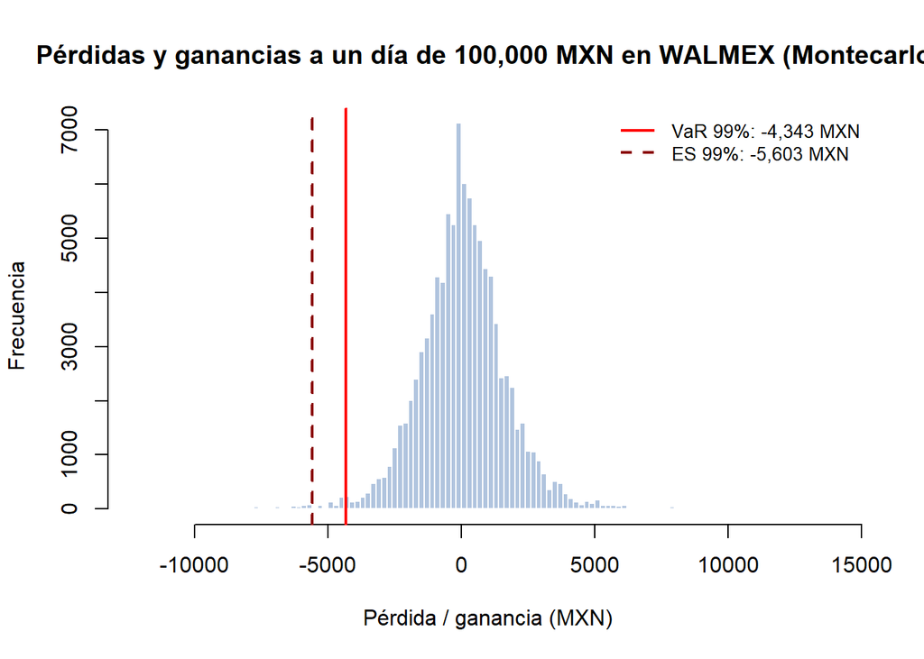

```r
hist(PL_mc_np, breaks = 100, col = "lightsteelblue", border = "white",
     main = "Pérdidas y ganancias a un día de 100,000 MXN en WALMEX (Montecarlo)",
     xlab = "Pérdida / ganancia (MXN)", ylab = "Frecuencia")
abline(v = c(VaR_ind, ES_ind), col = c("red", "darkred"), lwd = 2, lty = c(1, 2))
legend("topright",
       legend = c(paste0("VaR 99%: ", format(round(VaR_ind), big.mark = ","), " MXN"),
                  paste0("ES 99%: ", format(round(ES_ind), big.mark = ","), " MXN")),
       col = c("red", "darkred"), lwd = 2, lty = c(1, 2), bty = "n", cex = 0.85)
```

### 5.7.3 7.3. Interpretación

Con 100,000 simulaciones, la pérdida máxima de nuestra posición en un día, con 99% de confianza, es de 4,343 MXN, es decir, 4.34% de lo invertido. El Expected Shortfall es de 5,603 MXN (5.6% de la posición), o sea 1.29 veces el VaR. La diferencia importa: el VaR nos dice dónde empieza la cola, el ES nos dice cuánto se pierde en promedio cuando ya estamos dentro de ella.

La simulación histórica directa nos sirve de control. Su VaR (4,369 MXN) difiere 0.6% del Montecarlo, así que el remuestreo reproduce bien lo observado y la pequeña diferencia es ruido propio de simular (fijamos la semilla para que el resultado se pueda repetir).

Al comparar con el Montecarlo normal, el VaR del remuestreo equivale a 1.16 veces el normal y su ES a 1.3 veces. Una razón mayor a 1 significa que la normalidad subestima el riesgo; con esto vemos en pesos el efecto de las colas pesadas que detectó Jarque-Bera en la Parte 3.

Finalmente, el efecto de la diversificación se ve al comparar con el portafolio usando la misma muestra (2019 en adelante): por cada 100,000 MXN, el VaR histórico a un día al 99% del portafolio completo es de 2,781 MXN, frente a 4,051 MXN de tener todo en WALMEX, es decir, 31.4% menos de riesgo por peso invertido.

## 5.8 Análisis e interpretación

Para contestar las preguntas no nos quedamos con lo que dice la teoría: primero juntamos la evidencia del portafolio (forma de la distribución, peores días, violaciones y Expected Shortfall) y con ella contrastamos cada respuesta.

```r
fmt <- function(x) format(round(abs(x)), big.mark = ",")
pv <- function(modelo, conf) resumen_bt$p_valor[resumen_bt$Modelo == modelo & resumen_bt$Confianza == conf]
dec <- function(p) ifelse(p < 0.05, "se rechaza", "no se rechaza")

# (a) Forma real de la distribución del portafolio (toda la muestra)
r_p <- as.numeric(R_port)
mu_p_h <- mean(r_p)
sd_p_h <- sd(r_p)
curtosis_p <- mean((r_p - mu_p_h)^4) / (mean((r_p - mu_p_h)^2))^2
peor_sd <- (min(r_p) - mu_p_h) / sd_p_h
fecha_peor <- as.character(index(R_port)[which.min(r_p)])
prob_normal <- pnorm(peor_sd)
anios_normal <- 1 / (prob_normal * 252)
frec_cola <- mean(r_p < mu_p_h + qnorm(0.01) * sd_p_h)

# (b) Los 10 peores días del periodo de backtesting y si cada VaR al 99% los cubrió
orden <- order(PyG_real)[1:10]
tabla_peores <- data.frame(
  Fecha = fechas_eval[orden],
  Perdida_MXN = round(PyG_real[orden], 0),
  VaR99_SH = round(VaR_bt_SH[orden, "99%"], 0),
  VaR99_Param = round(VaR_bt_P[orden, "99%"], 0),
  Viola_SH = ifelse(viol_SH[orden, "99%"], "Sí", "No"),
  Viola_Param = ifelse(viol_P[orden, "99%"], "Sí", "No"),
  row.names = NULL
)
n_top_SH <- sum(viol_SH[orden, "99%"])
n_top_P <- sum(viol_P[orden, "99%"])

# (c) Qué tan exigente fue cada modelo
vp_SH <- colMeans(VaR_bt_SH)
vp_P <- colMeans(VaR_bt_P)
dias_SH_mayor <- colMeans(VaR_bt_SH < VaR_bt_P)

# (d) Qué pasó cuando falló cada modelo al 99%
i99_P <- viol_P[, "99%"]
i99_SH <- viol_SH[, "99%"]
perd_viol_P <- mean(PyG_real[i99_P])
var_viol_P <- mean(VaR_bt_P[i99_P, "99%"])
anio_viol_P <- table(format(fechas_eval[i99_P], "%Y"))

# (e) Expected Shortfall del portafolio a un día al 99%
es_SH_1d <- mean(PL_hist[PL_hist <= VaR_SH_1d[3]])
es_P_1d <- -V0 * sigma_p * dnorm(qnorm(0.01)) / 0.01
```

### 5.8.1 ¿Qué diferencias observan entre el VaR paramétrico y el no paramétrico?

En teoría, el paramétrico resume el riesgo en una sola cifra, la volatilidad de los últimos seis meses, y supone rendimientos normales; el histórico no supone nada y usa todo lo que ocurrió desde 2019. En los datos la diferencia se ve de inmediato: al 99% a un día el VaR histórico es de 16,684 MXN y el paramétrico de 13,577 MXN, así que el histórico es 1.23 veces el paramétrico. A 20 días la razón es de 0.81: el paramétrico escala con la raíz del horizonte, mientras que el histórico usa pérdidas acumuladas que realmente ocurrieron en ventanas de 20 días.

La brecha se explica por la forma real de los rendimientos. Los del portafolio tienen una curtosis de 14.22 (la normal tiene 3) y su peor día, el 2020-03-12, cayó 5.4 desviaciones estándar. Bajo normalidad, un día así tendría probabilidad de 3.8e-08, algo como una vez cada 100,000 años, y aun así ocurrió en nuestra muestra de 2019 a 2026. Además, 1.41% de los días superaron el umbral que la normal asigna al 1% de los casos. La normalidad no describe las colas del portafolio, y el VaR histórico, al usarlas tal cual, lo refleja.

### 5.8.2 ¿Cuál modelo captura mejor los eventos extremos?

Para contrastarlo tomamos los 10 peores días del periodo de backtesting y vimos si el VaR al 99% de cada modelo los cubrió.

```r
tabla_peores
```

| Fecha | Perdida_MXN | VaR99_SH | VaR99_Param | Viola_SH | Viola_Param |
| --- | --- | --- | --- | --- | --- |
| 2020-03-12 | -35282 | -20300 | -18298 | Sí | Sí |
| 2020-03-27 | -34783 | -23140 | -29357 | Sí | Sí |
| 2020-03-18 | -27415 | -22300 | -24175 | Sí | Sí |
| 2020-03-03 | -23487 | -15456 | -14000 | Sí | Sí |
| 2020-03-17 | -22991 | -21693 | -23519 | Sí | No |
| 2020-03-11 | -21894 | -18571 | -17546 | Sí | Sí |
| 2025-04-07 | -20413 | -17673 | -13742 | Sí | Sí |
| 2022-10-10 | -19631 | -19290 | -15888 | Sí | Sí |
| 2020-05-19 | -19511 | -23526 | -33481 | No | No |
| 2022-11-03 | -18135 | -19497 | -17096 | No | Sí |

Los peores días se concentran en pocos episodios de estrés, y ahí ambos modelos fallan con frecuencia: el VaR histórico fue rebasado en 8 de esos 10 días y el paramétrico en 8, porque en un choque repentino ninguno tiene todavía la información del golpe. La diferencia aparece en el panorama completo: en todo el periodo, al 99% el histórico tuvo 8 violaciones y el paramétrico 25, contra 14.5 esperadas. Cuando el paramétrico falló, la pérdida promedio fue de 17,126 MXN contra un VaR promedio de 13,874 MXN en esos días, es decir, 1.23 veces lo que el modelo anticipaba.

El Expected Shortfall cuenta lo mismo: el ES histórico a un día al 99% es de 21,951 MXN (1.32 veces su VaR) mientras que bajo normalidad es de 15,554 MXN (1.15 veces). Con los datos, el histórico captura mejor los eventos extremos.

Eso sí, tiene un punto débil que también se ve en los datos: el año con más violaciones del paramétrico fue 2020 (7 de 25), lo que es coherente con lo visto en la Parte 4: la volatilidad se agrupa, y una desviación estándar de seis meses se entera tarde de que cambió el régimen. El histórico, con memoria larga, tampoco se adapta rápido; simplemente tiene un colchón más grande.

### 5.8.3 ¿Qué modelo es más conservador?

El histórico. En el backtesting su VaR al 99% promedió 19,368 MXN contra 14,801 MXN del paramétrico, y fue el más exigente en 92.6% de los días. La consecuencia se ve en las violaciones: 8 frente a 14.5 esperadas, mientras el paramétrico se pasó con 25.

Ser conservador también tiene un costo. Al 97.5% el histórico tuvo 18 violaciones contra 36.1 esperadas (p-valor de Kupiec = 0.0007): cuando un modelo se queda tan por debajo de lo esperado, está pidiendo más capital del necesario.

### 5.8.4 ¿Qué implicaciones tiene elegir un modelo que subestima el riesgo?

En teoría, se reservan menos recursos de los necesarios y se toman posiciones más grandes de lo que conviene, con una falsa sensación de seguridad. En nuestros datos esto fue concreto: el paramétrico al 99% fue rebasado 25 veces, 1.73 veces lo esperado, y en esas jornadas la pérdida real superó en promedio 23.4% al VaR estimado. Un capital fijado con ese VaR habría resultado insuficiente justo en los días en que más se necesitaba.

El problema es asimétrico: sobreestimar el riesgo cuesta capital inmovilizado, pero subestimarlo puede costar una pérdida que no estaba prevista. Además, el VaR no dice cuánto se pierde después de rebasarlo, y ahí es donde el ES muestra la diferencia entre ambos modelos (21,951 MXN contra 15,554 MXN en el portafolio).

### 5.8.5 ¿Qué resultados arroja el backtesting y qué concluyen de ello?

Con 1,445 días evaluados, los resultados fueron:

- **95%:** histórico 59 violaciones y paramétrico 65, contra 72.3 esperadas. En la prueba de Kupiec no se rechaza la calibración del histórico y no se rechaza la del paramétrico.
- **97.5%:** histórico 18 y paramétrico 40, contra 36.1 esperadas. En la prueba de Kupiec se rechaza la calibración del histórico y no se rechaza la del paramétrico.
- **99%:** histórico 8 y paramétrico 25, contra 14.5 esperadas. En la prueba de Kupiec no se rechaza la calibración del histórico y se rechaza la del paramétrico.

Concluimos que ningún modelo es perfecto, pero se equivocan de forma distinta: el histórico se queda corto en violaciones (es prudente), mientras que el paramétrico se pasa justo en la cola donde más importa. Para el nivel del 99% el histórico tuvo el mejor desempeño.

## 5.9 8. Conclusiones

Al comparar las dos metodologías nos quedamos con que la diferencia no está en las fórmulas, sino en lo que cada una cree de los datos. El paramétrico asume que los rendimientos son normales y que la volatilidad de los últimos seis meses basta para describir el riesgo; el histórico asume que lo que ya pasó es una buena muestra de lo que puede pasar. En nuestro portafolio, la normalidad falló justo donde importa: en las colas. Por eso el VaR histórico al 99% fue 1.23 veces el paramétrico y el paramétrico tuvo 25 violaciones contra 14.5 esperadas.

En la práctica usaríamos la simulación histórica como medida principal, sobre todo al 99%, para fijar límites y reservas, porque fue la que se mantuvo en línea con lo observado en las pérdidas extremas. La acompañaríamos con el Expected Shortfall, que dice cuánto se pierde cuando el VaR falla (en WALMEX individual, 5,603 MXN frente a un VaR de 4,343 MXN). El paramétrico lo dejaríamos como indicador diario de monitoreo, porque se ajusta rápido, y lo mejoraríamos usando una volatilidad dinámica (EWMA o GARCH, como en la Parte 4) en lugar de una desviación estándar fija de seis meses.

La diversificación y la optimización nos dejaron una lección parecida. Tener las mismas posiciones dentro del portafolio redujo el VaR por peso invertido frente a concentrarse en WALMEX, pero optimizar con seis meses de datos bajó el VaR paramétrico 9.7% y el VaR histórico varió +1.8%. Es decir, una composición óptima para una muestra corta no necesariamente lo es para todo el historial, y no conviene tomarla como definitiva.

Por último, reconocemos las limitaciones de este ejercicio: los mercados de México y Estados Unidos tienen calendarios distintos, usamos pesos constantes en lugar de una estrategia real de compra y mantenimiento, evaluamos un solo portafolio y el VaR no mide qué tan grave es la pérdida cuando se rebasa. Lo más valioso que nos llevamos es el contraste entre teoría y realidad: un modelo puede ser elegante y fácil de calcular, pero si sus supuestos no se cumplen en las colas, el riesgo que reporta es más pequeño que el que realmente enfrentamos.